# Realm of Racket: Learn to Program, One Game at a Time!

[figure not shown]

# Realm of Racket: Learn to Program, One Game at a Time!

Forrest Bice

Rose DeMaio

Spencer Florence

Feng-Yun Mimi Lin

Scott Lindeman

Nicole Nussbaum

Eric Peterson

Ryan Plessner

David Van Horn

Matthias Felleisen

Conrad Barski, MD

Published by No Starch Press

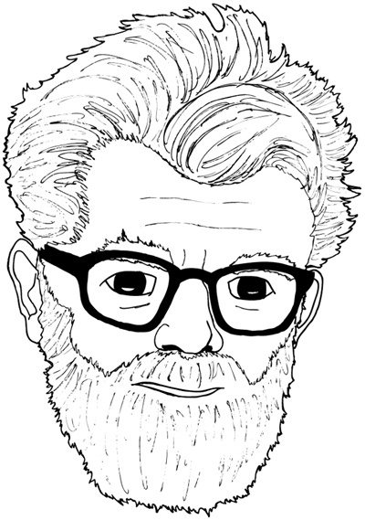

**To the Memory of John McCarthy September 4, 1927–October 24, 2011**

and to  
my parents, Sarah and Steve  
my beloved Noni, and my insanely fantastic Mom and Dad  
my father, Brian  
my beloved family, especially my best friend and ger ger, Dennis  
my parents, Jeff and Amy  
M and D, Magoo and Sunny  
my parents, Joy and Dan  
Richard, Lynda, and Morgan  
Barbara and Pete  
Christopher and Rachel  
Lauren and Ava

## Acknowledgments

We gratefully acknowledge the generous support of Brian Wenzinger, an alumnus of Northeastern University’s College of Computer and Information Science.

The College’s dean, Larry Finkelstein, and his staff—especially Kirsten Anderson, Doreen Hodgkin, and Jennifer Wong—provided great help along the way. Thank you.

Without Matthew Flatt (Utah), Robby Findler (Northwestern), and the rest of the PLT folks, there would be no Racket, no DrRacket, and no *Realm of Racket*.

Finally, cheers to our co-author, Conrad Barski, for getting us launched on this adventure through Racket land. We also owe thanks to Eric Chin, Pranav Gandhi, James Grammatikos, Cole Levi, Jack Noble, Alex Schwartz, and Brendan Wilson, who participated in the initial explorations for this project. In addition, Forrest would like to acknowledge and express his humble gratitude for the diverse and unwavering support his mom and dad, Sarah and Steve, have lovingly provided and continue to provide. Rose would like to thank her family and friends for being incredibly supportive of the project and for understanding when “the book” was the only explanation given for her frequent absences from activities in the past few months. She also wishes to thank all her co-authors for three semesters of forever quotable Thursday evenings. Mimi would like to thank her parents for giving her learning opportunities that exceeded their own. Furthermore, she is grateful to Matthias and David for opening up this rare educational experience. Scott says thank you to his little brother Steve, as retribution for constantly giving him a hard time. Nicole thanks her parents for always supporting her. She also thanks her co-authors for giving her Thursday nights purpose and joy. Thanks to MF and DVH, who could make her laugh even after fourteen straight hours of edits. Eric would like to thank his friends and family for always being so supportive of his doodles, and also David and Matthias for giving him the opportunity to use his doodles for good. David would like to thank Marisa, for everything. Matthias acknowledges his wife, Helga, for patiently waiting many Thursday evenings and his advisor, Dan Friedman, for teaching him Lisp and English.

## Preface (Hello World)

#|

Step into *Realm of Racket*, a book that takes you on a unique journey into the land of computer programming. In the style of Conrad Barski’s *Land of Lisp*, this book teaches you how to program in Racket by creating a series of games. Racket is a friendly mutation of Lisp that’s perfect for all, from those who want to launch their education in computer science to those looking to expand their knowledge and experience in programming.

|#

## Why Would I Want to Learn About Racket?

You’ve certainly heard of JavaScript, Perl, Python, and Ruby. But what about Racket? Just because it’s not the most mainstream programming language doesn’t mean you should discount its capabilities. Racket allows functional programming and other different paradigms that even hard-core programmers have never seen before. Get ready for the excursion. Even after you get through *Realm of Racket*, there is a lot to explore.

## Who Should Read This Book?

Our mantra is “by freshmen, for freshmen,” but that doesn’t mean you should drop this book if you are a sophomore or an industry professional. True, we were freshmen when we started writing this book, but our mantra means only that this book was written for you by peers who have a special interest in programming and want to explore it in a new, fun way. So you see why our mantra is what it is—it would have been a bit of a mouthful to say, “By people who have a special interest in programming and want to explore it in a new, fun way, for people who have a special interest in programming and want to explore it in a new, fun way.” And our recent expedition into the realm of Racket has enabled us to write this book with genuine empathy for a novice learner.

Regardless of your programming background, many of the topics in this book will be new to you, and much of what you’ve learned before will appear in a new light. This book is written for those who are truly inquisitive and interested in exploring a unique world of programming, so really we are all “freshmen” in this context.

## What Teaching Approach Is Used?

It won’t take you long to realize that this is not your typical programming textbook. We decided to present the material in a way that is engaging and really sticks—with games and comics.

In this book, we will teach you various topics through coding games, including a text-based game, some old-school games like Snake, and others that we invented ourselves. Along the way, you will need to use your programming skills to help a character named Chad navigate the dungeons of DrRacket.

## Can I Skip Chapters?

You might think you can skip ahead and save Chad right away, but we highly recommend that you read this book from front to back. Each chapter depends on the knowledge you learned from the previous one, and we don’t want you to miss out on any of Chad’s adventures.

## Anything Else I Should Know?

The source code of our games is available with the code base of Racket. Once you download Racket, navigate to the Racket installation and look for the **collects/realm/** folder. All the game code is there for you to explore, modify, and experiment with.

Finally, the book comes with its own website. Visit `realmofracket.com` and keep visiting—you never know what you’ll find there. Onward!

## Introduction (Open Paren)

#|

So you think you know how to program because you took an introductory course or two. Or perhaps you read a book that taught you programming in 13 days. And then you picked up this book, which is full of parentheses and comics. Doesn’t it look different from what you have seen in the past?

The programs you see here look like those that we encountered in our first programming courses. You might be wondering why anyone would teach such a weird-looking programming language and why we find it so exciting that we would write a whole book about it.

Or maybe you’ve heard others rave about the Lisp language and thought, “Boy, Lisp sure looks different from other languages that people talk about. Maybe I should pick up a Lisp book.” Either way, you’re now holding a book about a programming language in the Lisp family. And that whole family is very cool and unusual and fun. You won’t regret it.

|#

## (.1 What Makes Lisp So Cool and Unusual?

Lisp is a highly expressive language. With Lisp, you take the most complicated problems and express their solutions in a clear and appropriate way. If Lisp doesn’t have the means to do so, you change Lisp.

Lisp will change your mind, too. Eric Raymond, a well-known “hacker”—in the original, positive sense of the word—once wrote that “Lisp is worth learning for a different reason—the profound enlightenment experience you will have when you finally get it. That experience will make you a better programmer for the rest of your days, even if you never actually use Lisp itself a lot.”

Here is what we did with Lisp in the very first class of our very first course: we launched a rocket. Well, we didn’t launch a real rocket, but the animation looked cool, and it was just a few lines of code. After a couple of weeks into the course, we wrote our first interactive graphical game. Yes, our program used mouse clicks, clock ticks, and keyboard events to control a nifty little Snake game. Then we wrote an interpreter for the language that we used in the course. Did you get to write an interpreter for your language in your course? And before we knew it, we wrote distributed games. In case you don’t know what “distributed” means, our games ran on many computers, and at each computer, some person interacted with the game or some program played the game, and all these computers exchanged messages to make everything work together. And can you believe that some of us had never programmed before?

So Lisp is different. And the Lisp we use is Racket, with which even children can quickly feel at home. Once you have experienced this kind of programming, it will become a part of you, and you will dream about it. You will always strive to mimic this style in the languages you must use to earn a living. You’ll say to yourself, “That’s kind of how I’d do it in Lisp.” That’s the power only Lisp can give you.

## (.2 Where Did Lisp Come From?

At this point, you may start wondering why your instructor didn’t tell you about Lisp. You may think that it may be something new that he hadn’t heard of yet. Sadly though, it’s the opposite. The idea of Lisp is truly ancient, and yet, in some ways, most existing flavors of Lisp are more advanced than any other kind of language. But Lisp’s history is very different from that of other languages, and that could be why people overlook it.

Here is what we know from the anecdotes our professors told us. Way back in the 1930s, the first True Wonk of Programming walked the Earth. His name was Al—though his birth certificate said Alonzo Church—and he invented a new kind of calculus: **lambda calculus**. In this calculus, everything was a function, and every function that counted was something. All in all, it was functional and it functioned, although all this programming happened with paper and pencil because people had just figured out electricity.

Soon enough, the Earth was aflame in a great war with serious consequences on the world of programming. Governments sponsored science projects, and several of these projects created real computers. All computers, and especially the very first ones, are plain, dumb pieces of electrical hardware. As a matter of fact, the early computers—with names such as ENIAC and Zuse’s Z3—were so primitive that “programming” them involved flipping switches or patching cables to physically encode each operation. Those dark days saw a lot of experimentation with different computer architectures and an explosion of different ways of “programming” them.

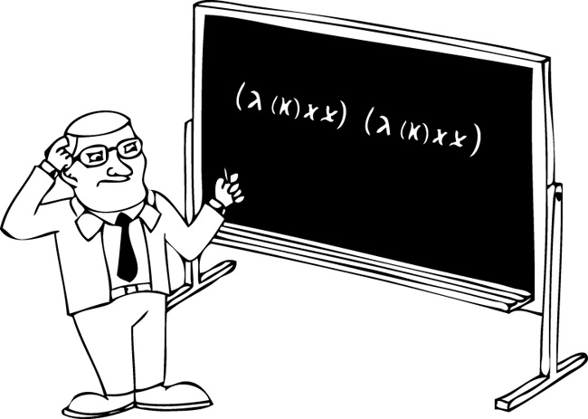

Naturally, people invented the idea of a programming language because it is the only way to make dumb computers truly useful. However, “language” meant nothing but a fairly thin veil over the underlying hardware. With these languages, programmers gave machines instructions. It made programming easier than flipping switches and patching cables, but it didn’t make it easy. Programmers had to think about the machine when they programmed, and their programs remained tied to specific computers.

Programming languages needed to evolve to survive beyond the confines of a specific machine. Thus, the 1950s saw the arrival of new types of software, including the most important: compilers and interpreters. A compiler can take something that looks like plain arithmetic and convert it automatically into a format that the computer can execute. An interpreter is similar, although it performs the actions described in a human-written program directly; there is no intermediate step that converts it all the way down to a computer format. Best of all, compilers and interpreters are software. This means that a competent programmer can change an existing compiler or interpreter a bit to make it work on a different computer, without changing the language that programmers use to interact with the compiler or interpreter. As a result, computer programmers could suddenly write programs in a notation that was mostly independent of a specific computer.

Nevertheless, programming remained a task of giving machines instructions. Take FORTRAN, the earliest language with a compiler. Its designers created it to help scientists program, and scientists still use FORTRAN today. Just typing a FORTRAN program makes you shuffle bits and bytes in the machine, and once you’re finished, you can barely see the mathematical problem you wanted to solve.

Another early language in the same mold as FORTRAN is ALGOL 60. While FORTRAN was made in America, ALGOL emerged in Europe, designed by a committee of computer scientists from all over the world. Together, FORTRAN and ALGOL spawned a long series of programming languages, called the ALGOL family. All members of this family are made from more or less the same material and for the same kind of programmers—those who love the machine more than the problem. You may have heard of some of these languages, such as C, Pascal, C++, and Java. To this day, most college courses use the ALGOL family to teach the first course on programming. Your instructors may even have told you that all languages are so similar that once you have seen one of them, you have seen all of them. Although this statement might be true for the ALGOL family of languages, it isn’t true for Lisp, a language nearly as old as FORTRAN and ALGOL.

Lisp’s beginnings are quite humble. Also in the late 1950s, John McCarthy—a computer scientist who worked at MIT, the best college in East Cambridge—came across Al’s old papers on lambda calculus. The papers were difficult to read because they had been written in the days before people had real computers. They sent John daydreaming. When he woke up, he knew that he was sick of programming computers in the dumb ways of machine language or FORTRAN. He wanted an intelligent way to go about it. So one day he gathered together his researchers and challenged them to build a programming language that wasn’t about the bits and bytes in a computer. Instead, he wanted to create a language that would help programmers solve problems without forcing them to think about the elements of a machine.

John’s first example was about lists: lists of ideas, lists of tasks, lists of insights, and even lists of programs. To deal with lists, a program should provide lists and functions for processing lists—never mind how the computer really deals with all of this inside. Better still, a language should be able to “talk” about itself and about programming. In short, he wanted Lisp, a language so elegant and powerful that even writing an interpreter for Lisp in Lisp itself would take only about 50 lines of computer code.

Before John knew it, his people made Lisp real. The language was indeed small, and it was really possible to write a Lisp interpreter in Lisp in a few dozen lines of code. Because it was so easy to write a Lisp interpreter, many people wrote one. As it turned out, everyone tinkered with the original small Lisp interpreter. Soon enough, there wasn’t just one Lisp but a lot of Lisps. Fortunately, all these Lisps shared the essential traits of John’s original ideas so that Lisp programmers could easily exchange ideas. That’s why Lisp is a family of programming languages, not just a single programming language.

## (.3 What Does Lisp Look Like?

Now you know that Lisp is cool, old, and an entire family of languages. You also know that we are totally excited about one member of this family: Racket. Before you become impatient with us, let us show you some Lisp code so that this introduction doesn’t become all talk and no action.

At some level, Lisp code isn’t as different as it may seem at first. Here are some valid Lisp expressions, and we’re sure you can guess what they compute:

```
(* 1 1)
(- 8 (* 2 3))
(sqrt 9)
```

If you answered 1, 2, and 3, then you’ve already figured out how to read Lisp code. It looks like arithmetic, except that the functions—addition, subtraction, multiplication, and square root—come before their operands, and expressions are surrounded by parentheses.

You may wonder why in the world Lisp breaks with the centuries-old tradition of infix notation, but take a look at this:

```
(+ 1 2 3 4 5 6 7 8 9 0)
```

For many functions, it makes a lot of sense to supply a lot of arguments at once, and with prefix notation, doing so is easy. But programming is also about defining your own operators and writing expressions that use these and the ones that come with the language. So in C++ programs, you may see things like this:

```
(foo<bar>)*g++.baz(!&qux::zip->ding());
```

Can you explain the order in which the subexpressions of this complex beast are evaluated? No one can. Everyone must dissect the expression first to understand it. Dissecting means putting in more parentheses, either in your head or on paper, after looking up which operators have the highest precedence. Do you recall your struggles with precedence in grade school? When you read Lisp code, this confusion never happens:

```
(sqrt (+ (sqr 3) (sqr 4)))
```

Here, you see a deeply nested expression, and yet the parentheses immediately tell you in which order things are evaluated. The parentheses also tell you that the operators—`sqrt`, `+`, and `sqr`—are involved, because you know that every left parenthesis—called “open” when Lispers speak—is followed by an operator. And guess what the right parentheses are called in Lisp-speak? You got it: “close.” That’s how easy it is to read Lisp. Once you’re used to it, which may take a day or two, you will see its advantages.

However, Lisp isn’t just about numbers or arithmetic; it’s also about list processing. So you should be curious about what lists look like in Lisp. Here are some examples:

```
(list 1 2 3 4 5 6 7 8 9 0)
(list (list 1 3 5 7 9) (list 2 4 6 8 0))
(list (list 'hello 'world)
      (list (list 'it 'is) 2063)
      (list 'and 'we 'love 'Racket))
```

The first list consists of 10 digits; the second one groups these digits into two lists, which then become the elements of another list; and the third example shows that while lists can be deeply nested, Lisp comes with symbolic values, too.

Of course, a language that is about lists has even better ways to write lists:

```
'(1 2 3 4 5 6 7 8 9 0)
'((1 3 5 7 9) (2 4 6 8 0))
'((hello world)
  ((it is) 2063)
  (and we love Racket))
```

These first three examples should look familiar; they are abbreviations for the preceding list examples. See how little you need to write for a list of lists with symbolic information inside? One last example should inspire some awe:

```
'(sqrt (+ (sqr 3) (sqr 4)))
```

By adding a quote to the left of a piece of Lisp code, we turn it into a piece of data. Because the two expressions are equivalent, we could have written this:

```
(list 'sqrt
      (list '+
            (list 'sqr 3)
            (list 'sqr 4)))
```

Both create lists that contain a list, which contains a symbolic representation of addition and two more lists. The quoted expression creates a piece of data that captures all the structure that is in the program expression itself: its nesting structure, its numbers, and its symbols. If you had used string quotes to turn the expression into a piece of data, all you would have is a string. Before you could recover the expression’s structure and organization, you would need to complete your entire computer science undergraduate major.

In Lisp, all it takes is one keystroke on your keyboard—one character on the screen. You cannot do anything like this without a Lisp. Now that’s cool. And it’s powerful.

## (.4 Where Does Racket Come From?

Now back to 1972. Object-oriented programming had made an appearance. What we call the Smalltalk and Simula programming languages were up and running, and they suggested the object-oriented way of programming. People at John’s old place began to study these ideas. Guy Steele and Gerry Sussman were two of these programmers. Here is how it all went down when they took this topic into their own hands:

- *What’s an object?*
- An object computes something if you send it different kinds of messages.
- *Do we really need to understand how objects work with many different messages?*
- No way. A scientist just needs to know how objects deal with one message, and that shows how all messages work.
- *So what are objects that understand one kind of message?*
- Functions! Objects that understand only one message—“run your code on the following arguments”—are functions.
- *How about all these loops?*
- Al already knew in the 1930s that loops are just abbreviations for recursive functions.
- *You mean loops are like frosting on the cake when an object can send a message to itself?*
- Absolutely, loops are like adding sugar to soda.
- *Are conditionals fundamental?*
- Nope, not even they are. Al showed that such things are just functions and compositions of functions.

Guy and Gerry went back and forth for a while in this fashion. When they were done, they had extended Al’s programming language of functions with just two ideas: assignment statements and jumps in control flow. Everything else was **syntactic sugar**, that is, shorthand for a combination of concepts from this tiny core language. The language drew its power from Guy and Gerry’s efforts to make everything simple and regular.

The two also understood that this collection of ideas was close to John’s idea of Lisp and that Lisp was really good for prototyping new languages. And so they prototyped their language in Lisp and called it Scheme. Because of that, people started thinking of Scheme as just another form of Lisp.

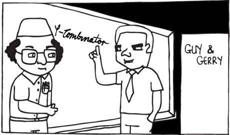

From Guy and Gerry’s MIT AI Lab, Scheme quickly spread to several other places. Dan Friedman and Mitch Wand picked it up at Indiana University, and their research group built a version called Scheme84. They used Scheme to conduct programming language research. Because Scheme is so small and regular, it is easy to study the effects of adding one more idea or whether a new idea is just syntactic sugar for Scheme. A team of Yale researchers, under Paul Hudak’s leadership, created another flavor, dubbed T. They looked at T as a compiler project, figuring out how to compile an expressive language into fast machine code. On top of that, individuals all over the world constructed their own variants of Scheme. Soon enough, dozens of Scheme implementations existed, all with their own small mixins and little extensions and tiny add-ons.

One of these Scheme implementations emerged at Rice University in Houston, Texas. Matthias Felleisen, Robby Findler, Matthew Flatt, and Shriram Krishnamurthi wanted to use Scheme to teach children math in a creative way. Children in middle school and high school could write computer games in plain arithmetic and algebra, which is easily expressed in a Scheme-like language. The four researchers also wanted to build all the necessary software in Scheme, and then they quickly realized that Scheme was too small to build real systems. They added structures, a class system, exceptions, fancy loops like you’ve never seen before, modules, custodians, eventspaces, libraries for building graphical-user interfaces, and many other things. Yes, some of these additions can be understood as syntactic sugar, but others introduced fundamentally new ideas into the world of programming languages.

Eventually, Matthias and Robby and Matthew and Shriram and everyone else who used this flavor of Scheme decided that their language was quite different from the original Scheme. After a lot of loud and wild arguing, they decided to give it a new name. This is where Racket comes from.

But don’t worry—just because Racket is a large, useful language doesn’t mean it is difficult to learn. Remember that Matthias, Robby, Matthew, and Shriram had middle school students in mind when they launched the Racket project. Because of this, learning Racket is like walking up a gentle slope; you should never feel like you have to climb a straight wall—unlike in your class, perhaps.

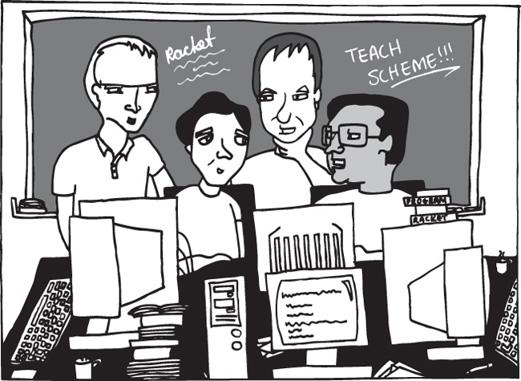

## (.5 What Is This Book About?

So this book is *for* freshmen and it is written *by* freshmen, with a little help from some sophomores and professors. We assume that you have programmed somewhere, somehow—most likely in a freshman course at college. Our goal is to show you our own world of programming, one game at a time. We hope that this will open your mind about programming and that it will get you in touch with your inner Racketeer. If you like it, this book is a platform from which you can easily work your way into the rest of Racket and a whole new world of understanding programs.

## `Halt`—Chapter Checkpoint

This introduction acquainted you with some historic background about programming and the Lisp family of programming languages:

- Computers are dumb pieces of hardware.
- Programmers use programming languages to turn computers into useful and entertaining gadgets.
- One of the oldest high-level languages is Lisp, which is more than 50 years old.
- There are many related flavors of Lisp, and we call Lisp a family of languages.
- To this day, Lisp offers programmers a way to experience programming as poetry.
- Racket is our chosen flavor of Lisp. Racket is relatively new, and it is especially well suited for novice programmers who want to ramp up gradually.

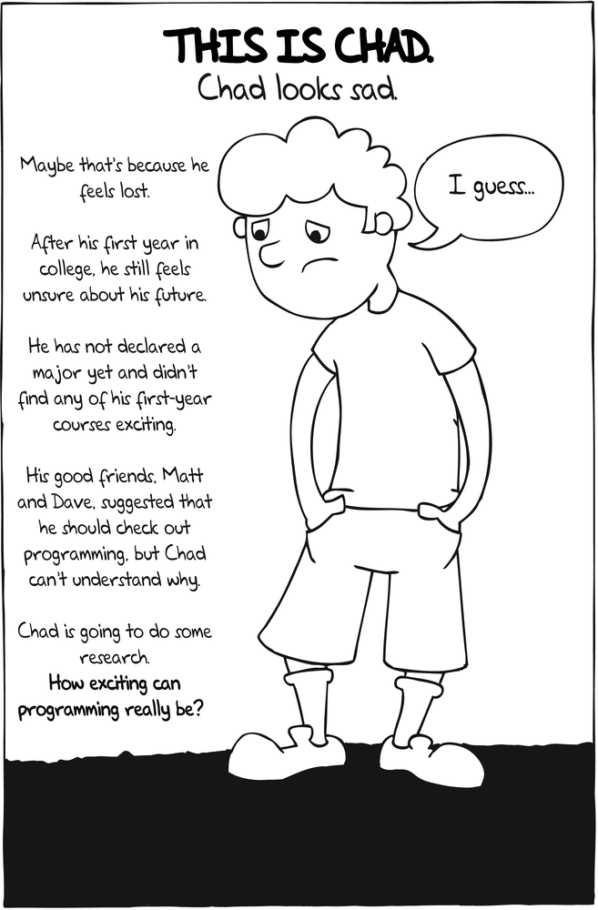

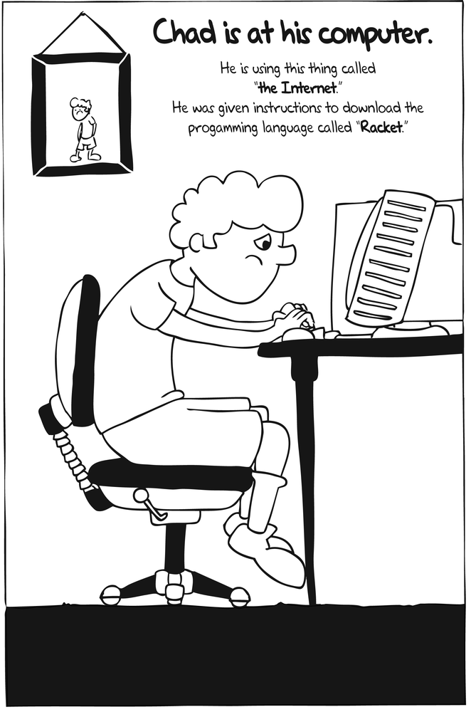

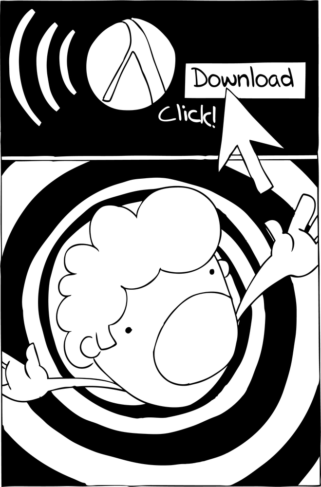

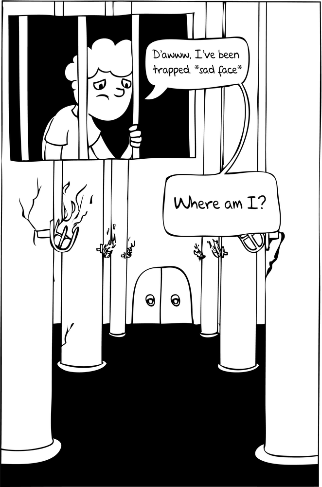

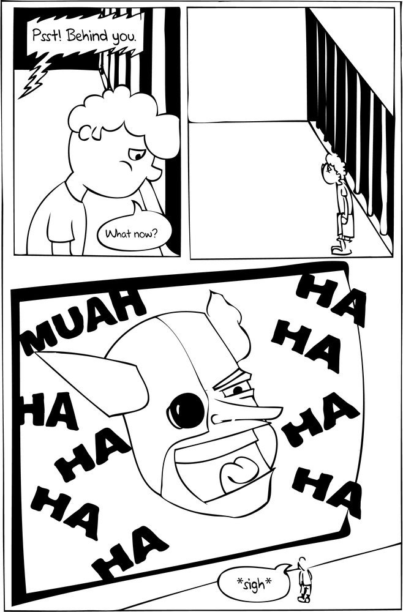

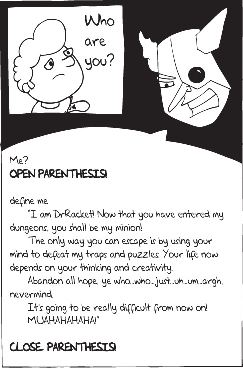

## Chapter 1. (Getting Started)

#|

You need a Racket before you can launch a rocket, so the first thing you need to learn is how to download and install DrRacket. Once you have it on your computer, you will learn how to experiment. Racket is all about experimenting with expressions and creating your programs from these experiments. After some quick demonstrations, you’ll be ready to write a game!

|#

## 1.1 Readying Racket

Racket is a programming language. In principle, the Racket compiler is all you need to write Racket programs. You could—and die-hard Lispers would—launch the Racket compiler in an interactive mode, type in the program, and voilà, you’d have a running program. Or you’d get an error message saying that something isn’t quite right, and you’d have to retype a part of your program. After a while, this gets bothersome. Just as you need a comfortable seat to work, you need a convenient “software seat” to develop your programs, to experiment with pieces, to run your test suites, and to explore the partially finished game. We call this place a **program development environment (PDE)**; others refer to it as an **interactive development environment (IDE)**.

DrRacket—pronounced “Doctor Racket”—is the PDE for Racket, and it is bundled with the Racket programming language. The original Racketeers—the people who created and use DrRacket—wanted to have a PDE where everyone—young children, old Lispers, and regular programmers—could quickly feel comfortable. Therefore, DrRacket is designed in such a way that you can immediately experiment with expressions and program fragments. You can edit programs and run them. You can write tests for your program and check them. And using DrRacket is quite easy.

So let’s get DrRacket. Point your browser to `racket-lang.org,` and near the top-right area of the page, you will see a download icon. Click the icon, choose your platform, and download Racket from any of the sites that show up.

Racket can run on Windows, Mac, and *nix systems. For Windows and Macs, a software installer takes care of everything that needs to happen. If you’re on a *nix box, you are already a hero and don’t need instructions. In the end, you will have a folder with several applications. Launch DrRacket as appropriate for your platform: by clicking, from a shell, or whatever.

### Note

#|

In this folder, you can see another folder called **collects** and within that folder, you can find **realm**. There, you can access all the source code for all the games in this book. We encourage you to open these files in DrRacket and to experiment with the code.

|#

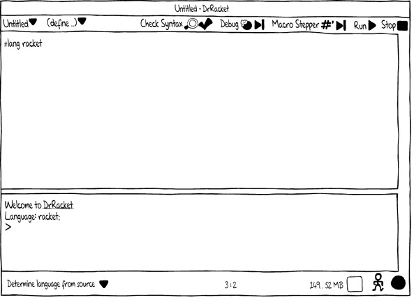

Among other things, Racket is a programming language for making programming languages. Because of that, Racket comes in many flavors. Some flavors are for beginners; they are called **teaching languages**. Others are for writing small shell scripts or large applications. A third kind is for old people who wish to program in long-gone languages. And there are many more flavors beyond this short list. As far as this book is concerned, however, we will show you just one flavor: plain Racket.

You choose which Racket flavor you want to use with these four steps:

- Select the “Language” menu of DrRacket.
- Select the “Choose Language...” menu.
- Enable the option “The Racket Language.”
- Click “OK” and then click “Run,” the little green go icon.

Now take a closer look at DrRacket. You should see these primary pieces:

- Some buttons, including “Run” and “Stop”
- A **definitions panel** where you see the text `#lang racket`, which means you are using the Racket programming language
- An **interactions panel** labeled “Welcome to DrRacket” with another line of text that says your chosen language is “racket” and a third line with just one symbol: “`>`”

## 1.2 Interacting with Racket

DrRacket displays the “`>`” prompt in the interactions panel. The prompt signals that DrRacket expects you to enter an expression, say `(+ 1 1)`. DrRacket reads this expression, evaluates it, prints the result, and then displays its prompt again. Old Lispers call this mechanism a **read-eval-print loop**, but we are sticking with the Racketeer term **interactions panel**.

Go ahead. Enter an expression. Use `(+ 1 1)` if you can’t think of anything better. Here is what happens:

```
> (+ 1 1)
2
```

As soon as you hit the “Enter” key, DrRacket becomes active and prints the result. Let’s try another expression:

```
> (+ 3 (* 2 4))
11
```

The interactions panel works! Hooray! You type expressions and Racket evaluates them. Experiment some more—that’s what the interactions panel is for. You could, for example, play with expressions like these:

```
> (sqrt 9)
3
> (sqrt -9)
0+3i
```

Yes, Racket knows about complex numbers. How about this:

```
> (+ 1 2 3 4 5 6 7 8 9 0)
45
```

Calling `+` on many numbers actually works. And so do nested expressions:

```
> (sqrt (+ (sqr 3) (sqr 4)))
5
```

Lists are a pleasure, too:

```
> '((1 3 5 7 9) (2 4 6 8 0))
'((1 3 5 7 9) (2 4 6 8 0))
```

They come back out just as you put them in, because there is nothing to evaluate with lists.

How about expressions as nested lists?

```
> '(sqrt (+ (sqr 3) (sqr 4)))
'(sqrt (+ (sqr 3) (sqr 4)))
```

Okay, enough of that. We need to move on to the definitions panel.

Take a look at the sketch below. We entered `(+ 3 (* 2 4))` into the definitions panel, hit “Enter,” and nothing happened. While the interactions panel is for experimenting with expressions, the definitions panel is where you record your code.

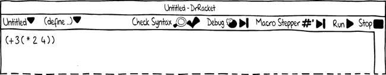

To make something happen, click the “Run” button. DrRacket will evaluate the expression and then print the result `11` in the interactions panel. You could also enter this in the definitions panel:

```
'(hello world)
```

Click “Run,” and you’ll see `'(hello world)` in the interactions panel. DrRacket does all the printing for you; there’s no need for you to specify such mundane things. Also, note that your cursor is back in the interactions panel. You can now enter expressions there again and experiment some more.

Before we forget, click the “Save” button—the one with the disk icon. DrRacket will ask you to select a file name and folder on your computer where it will save the current contents of the definitions panel. Racketeers use file names that end in **.rkt** and you should do so, too:

```
my-first-program.rkt
```

You could run the program in this file in stand-alone mode now, or you could open the file in DrRacket and run things there.

Say you closed DrRacket and, before you know it, panic strikes. You just discovered that your first program wasn’t supposed to add `3` to the product of `2` and `4`. It was supposed to say `'(hello world)` and nothing else. Launch DrRacket again. Use the “File” menu and choose “Open Recent” from the available options. When you mouse-over this option, you can see **my-first-program.rkt**, and you should click it. The program is back in the definitions panel, and you are now free to change it to `'(hello world)`. And that’s why we place everything we wish to keep in the definitions panel.

Any questions? Oh yes, it’s called the definitions panel because you actually write down definitions for variables and functions. But the best way to show you how to do this is by writing our first simple game together. Ready?

## `Raise`—Chapter Checkpoint

In this chapter, you learned a few basics about Racket and DrRacket:

- DrRacket is the PDE for Racket. It runs on most computing platforms. Both Racket and DrRacket are available for free online at `racket-lang.org` as one package.
- You can enter expressions and evaluate them in the interactions panel.
- You can edit programs in the definitions panel and run them, and the interactions panel shows what they compute.

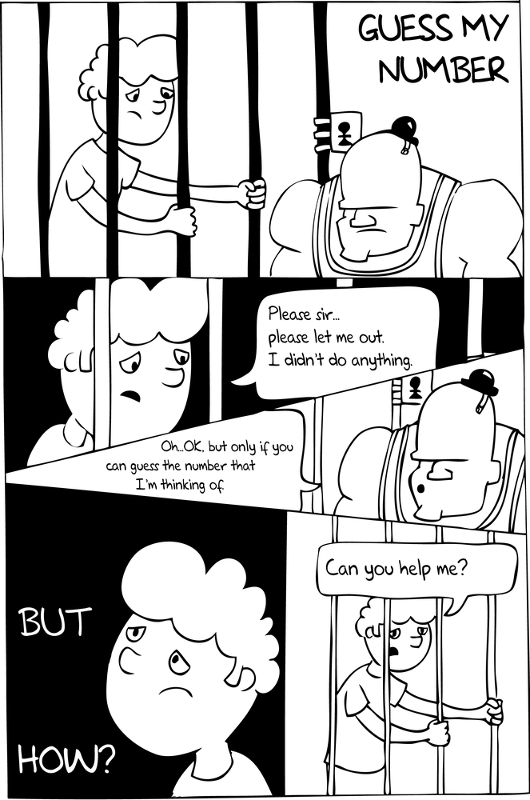

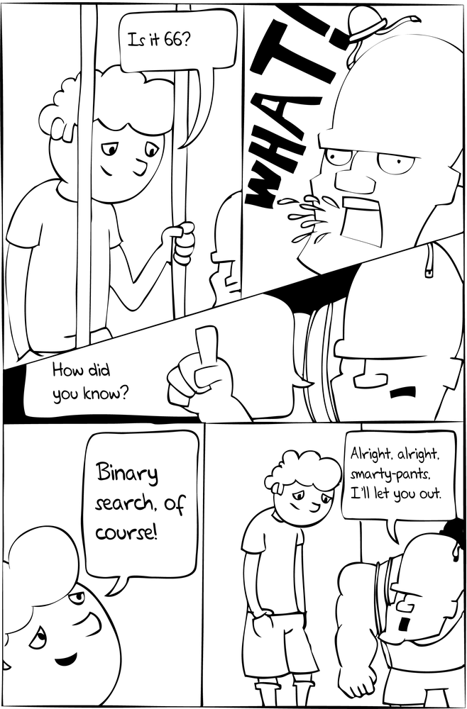

## Chapter 2. (A First Racket Program)

#|

You’ve installed DrRacket, learned that programs go into the definitions panel, and experimented with Racket in the interactions panel. You are now ready to write your first real program, a simple game for guessing numbers.

|#

## 2.1 The Guess My Number Game

The first game we will write is one of the simplest and oldest games around. It’s the classic Guess My Number game. In this game, the player thinks of a number between `1` and `100`. Our program will then figure out that number by repeatedly making guesses and asking the player if her number is bigger or smaller than the current guess.

The following piece shows what a game might look like in the interactions panel if the player chose `18`:

```
> (guess)
50
> (smaller)
25
> (smaller)
12
> (bigger)
18
```

The above interactions involve three different kinds of expressions: `(guess)`, `(smaller)`, and `(bigger)`. You can probably imagine what they mean. The first one tells the program to start guessing; the second one says that the guess is too high, so a smaller number needs to be guessed; and the third one commands the program to look for a bigger number.

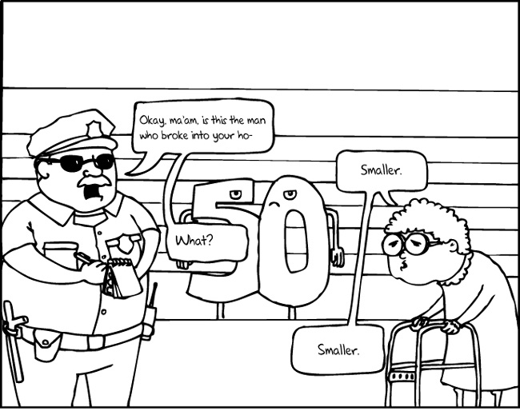

Everything to the immediate right of “`(`” is a function, which means that we are dealing with three functions here: `guess`, `smaller`, and `bigger`. All you need to do is define these functions, and you have programmed yourself a first game. The player calls these functions in the interactions panel, starting with the `guess` function.

Now, let’s think about the strategy behind this simple game. The basic steps are as follows:

- Determine or set the upper and lower limits of the player’s number.
- Guess a number halfway between those two numbers.
- If the player says the number is smaller, lower the upper limit.
- If the player says the number is bigger, raise the lower limit.

At this point, you know almost everything there is to know about the game. We just need to introduce a few more Racket mechanics, and you will have Guess My Number going.

## 2.2 Defining Variables

As the player calls the functions that make up our game, the program will need to update the lower and upper limits at each call. One way to do so is to store the limits in variables and to change the values of the variables during the game. For Guess My Number, we’ll need to create two new variables called `lower` and `upper`.

The way to create a new variable is with `define`:

```
> (define lower 1)
> lower
1
> (define upper 100)
> upper
100
```

We weren’t completely honest with you. In addition to functions, it is also possible that “`(`” is followed by a **keyword**, such as `define`. Expressions that start with a keyword work in their own special way, depending on the particular keyword. You’ll just need to remember the rules for each keyword. Fortunately, there is only a very small number of them.

The `define` keyword is quite important for understanding Racket programs, as it is used to define variables and functions. Here we are using it to define variables. The first part of the `define` expression is the name of the variable, and the second is an expression that produces the value we want the variable to have.

What may surprise you is that a definition does not evaluate to anything. Don’t worry. We will explain. Oh, and do place those two definitions where they belong—in the definitions panel.

## 2.3 Basic Racket Etiquette

Racket ignores spaces and line breaks when it reads code. This means you could format your code in any crazy way but still get the same result:

```
> (                define
             lower 1)
> lower
1
```

Because Racket code can be formatted in such flexible ways, Racketeers have conventions for formatting programs, including when to use multiple lines and indentation. We’ll follow common conventions when writing examples in this book, and you’re better off mimicking them. However, we’re more interested in writing games than discussing source code indentation rules, so we won’t spend too much time on coding style in this book.

### Note

#|

Pressing the “Tab” key in DrRacket automatically indents your code to follow common convention. You can auto-indent a chunk of code by highlighting it and then pressing the “Tab” key. You can auto-indent an entire Racket program just by pressing Command+i on a Mac or Ctrl+i on Windows and *nix.

|#

## 2.4 Defining Functions in Racket

Our Guess My Number program defines `guess` to start the game and responds to requests for either `smaller` or `bigger` guesses. In addition to these three functions, we also define a function called `start` that starts the game for a different range of numbers.

Like variables, functions are defined with `define`:

```
(define (function-name argument-name ...)
  function-body-expression
  function-body-expression
  ...)
```

First, we specify the name of the function and the names of its arguments and put all of them in a pair of parentheses. Second, we follow it up with the expressions that comprise the function’s logic.

The dots mean that the preceding entity occurs an arbitrary number of times: zero times, one time, two times, and so on. It is thus possible that a function may have zero arguments, but it must have at least one expression in its body.

### A Function for Guessing

The first function we’ll define is `guess`. This function uses the values of the `lower` and `upper` variables to generate a guess of the player’s number. In our definitions panel, its definition looks like this:

```
(define (guess)
  (quotient (+ lower upper) 2))
```

To indicate that the function does not take any arguments, we place a closing parenthesis directly after the function name `guess`.

### Note

#|

Although you don’t need to worry about indentation or line breaks when entering code snippets, you must be sure to place parentheses correctly. If you forget a parenthesis or put one in the wrong place, you’ll most likely get an error; if you don’t, you’re in trouble. But there’s no need to worry: as you have probably noticed by now, DrRacket helps you with this task.

|#

Guess what this function does. As discussed earlier, the computer’s best guess in this game is a number halfway between the two limits. To accomplish this, we choose the average of the two limits. If the average number ends up being a fraction, we choose the nearest whole number.

We implement this in the `guess` function by first adding the numbers that represent the upper and lower limits. The expression `(+ lower upper)` adds together the value of those two variables. We then use the `quotient` function to divide the sum in half to get an integer.

Let’s see what happens when we call our new function after clicking “Run”:

```
> (guess)
50
```

Since this is the program’s first guess, the output we see when calling this function tells us that everything is working as planned. The program picked the number 50, right in between 1 and 100.

When programming in Racket, you’ll almost always write functions that won’t explicitly print values on the screen. Instead, they’ll simply return the value calculated in the body of the function, and DrRacket prints it for you. For instance, let’s say we wanted a function that just returns the number 5. Here’s how we could write the `return-five` function:

```
(define (return-five)
  5)
```

Because the value calculated in the body of the function evaluates to `5`, calling `(return-five)` in the interactions panel returns `5`, and DrRacket prints that:

```
> (return-five)
5
```

This is how `guess` is designed; we see this calculated result on the screen not because the function displayed the number, but because this is a feature of DrRacket’s interactions panel.

### Note

#|

If you’ve used other programming languages before, you may remember needing to write something like “return” to cause a value to be returned. This is not necessary in Racket. The final value calculated in the body of the function is returned automatically.

|#

### Functions for Closing In

Now we’ll write our `smaller` and `bigger` functions, which update the `upper` and `lower` variables when necessary. Like `guess`, these functions are defined with the `define` form. Let’s start with `smaller`:

```
(define (smaller)
  (set! upper (max lower (sub1 (guess))))
  (guess))
```

First, we use `define` to start the definition of any new function. Because `smaller` takes no parameters, the parentheses are wrapped tightly around `smaller`. Second, the function body consists of two expressions, one per line.

Third, the function uses a `set!` expression to change the value of a variable. In general, a `set!` expression has the following shape:

```
(set! variable expression)
```

The purpose of `set!`, pronounced “set bang,” is to evaluate the *expression* and set the *variable* to the resulting value. With this in mind, we can see that the `set!` expression in the definition of `smaller` first computes the new maximum number, and then it assigns that number to `upper`, giving us the new upper bound.

Finally, we want our `smaller` function to show the player a new guess. We do so by putting a call to `guess` as the final expression in the function body. This time, `guess` calculates the new guess using the updated value of `upper`.

The `bigger` function works in the same manner as `smaller`, except that it raises the `lower` value instead:

```
(define (bigger)
  (set! lower (min upper (add1 (guess))))
  (guess))
```

After all, if the player calls the `bigger` function, she is saying that her number is bigger than the previous guess, so the smallest it can now be is one more than the previous guess. The function `add1` simply adds `1` to the value returned by `guess`.

Here we see our functions in action, with the number 56 as the player’s number:

```
> (guess)
50
> (bigger)
75
> (smaller)
62
> (smaller)
56
```

### The Main Function

It is practical to have one **main function** that starts—or restarts—the whole application. Placing the definition of the main function at the top of the definitions panel also helps readers understand the purpose of the program.

For Guess My Number, this is a simple feat:

```
(define (start n m)
  (set! lower (min n m))
  (set! upper (max n m))
  (guess))
```

As you understand by now, `start` takes two arguments, which are the numbers we want to set as the `lower` and `upper` bounds. By using the `max` and `min` functions, we cut down on the instructions that we need to give any player. It suffices for a player to put in any two numbers in any order, and the function can determine the `lower` and `upper` bounds. For example, you could start the game using a small range of numbers, like this:

```
> (start 1 30)
15
```

### Note

#|

As we continue to more challenging games, you will see how a main function makes our games much more user friendly.

|#

The other functions continue to work as advertised:

```
> (bigger)
23
> (smaller)
19
```

Now go ahead and do some guessing yourself.

## `Resume`—Chapter Checkpoint

In this chapter, we discussed some basic Racket forms. Along the way, you learned how to do the following:

- Use `define` to define a variable or function.
- Use `set!` to change the value of a variable.
- Use the interactions panel for experimentation.
- Copy and paste successful experiments to the definitions panel.

## Chapter 3. (Basics of Racket)

#|

You’ve written your first program. It consisted of a few functions that dealt with numbers. You’ve seen the basics of expressions and definitions. You know there are a lot of parentheses.

Now it’s time to bring some order to chaos. In this chapter, we’ll show you other kinds of data, as well as the general structure and meaning of Racket programs.

|#

## 3.1 Syntax and Semantics

To understand any language—be it a human language or a language for programming—requires two concepts from the field of linguistics. Computer scientists refer to them as “syntax” and “semantics.” You should know that these are just fancy words for “grammar” and “meaning.”

Here is a typical sentence in the English language:

```
My dog ate my homework.
```

This sentence uses correct English syntax. Syntax is the collection of rules that a phrase must follow to qualify as a valid sentence. Here are some of the rules of sentences in the English language that this text obeys: the sentence ends in a punctuation mark, contains a subject and a verb, and is made up of letters in the English alphabet.

However, there is more to a sentence than just its syntax. We also care about what the sentence actually means. For instance, here are three sentences that, roughly, have the same semantics:

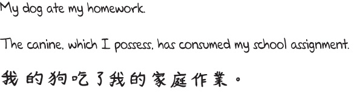

The first two are just different ways of saying the same thing in English. The third sentence is in Chinese, but it still has the same meaning as the first two.

The same distinction between syntax and semantics exists in programming languages. For instance, here is a valid line of code written in C++:

```
((foo<bar>)*(g++)).baz(!&qux::zip->ding());
```

This line of code obeys the rules of C++ syntax. To make the point, we put in a lot of syntax that is unique to C++. If you were to place this line of code in a Python program, it would cause a **syntax error**.

Of course, if we were to put this line of code in a C++ program in the proper context, it would cause the computer to do something. The actions that a computer performs in response to a program make up its semantics. It is usually possible to express the same semantics with distinct programs written in different programming languages; that is, the programs will perform the same actions independent of the chosen language.

Most programming languages have similar semantic powers. In fact, this is something that Al and his student Alan Turing first discovered in the 1930s. On the other hand, syntax differs among languages. Racket has a very simple syntax compared to other programming languages. Having a simple syntax is a defining feature of the Lisp family of languages, including Racket.

## 3.2 The Building Blocks of Racket Syntax

From the crazy line of C++ code in the previous section, you can get the hint that C++ has a lot of weird syntax—for indicating namespaces, dereferencing pointers, performing casts, referencing member functions, performing Boolean operations, and so on.

If you were to write a C++ compiler, you would need to do a lot of hard work so that the compiler could read this code and check the many C++ syntax rules.

Writing a Racket compiler or interpreter is much easier as far as syntax is concerned. The part of a Racket compiler that reads in the code, which Racketeers call the **reader**, is simpler than the equivalent part for a C++ compiler or the compiler for any other major programming language. Take a random piece of Racket code:

```
(define (square n)
  (* n n))
```

This function definition, which creates a function that squares a number, consists of nothing more than parentheses and “words.” In fact, you can view it as just a bunch of nested lists.

So keep in mind that Racket has only one way of organizing bits of code: parentheses. The organization of a program is made completely clear only from the parentheses it uses. And that’s all.

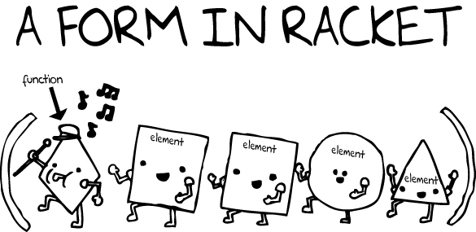

In addition to parentheses, Racket programmers also use square brackets `[]` and curly brackets `{}`. To keep things simple, we refer to all of these as “parentheses.” As long as you match each kind of closing parenthesis to its kind of opening parenthesis, Racket will read the code. And as you may have noticed already, DrRacket is extremely helpful with matching parentheses.

The interchangeability of parentheses comes in handy for making portions of your code stand out for readers. For example, brackets are often used to group conditionals, while function applications always use parentheses. In fact, Racketeers have a number of conventions for where and when to use the various kinds of parentheses. Just read our code carefully, and you’ll infer these conventions on your own. And if you prefer different conventions, go ahead, adopt them, be happy. But do stay consistent.

### Note

#|

Code alone doesn’t make readers happy, and therefore Racketeers write comments. Racket has three kinds of comments. The first one is called a **line comment**. Wherever Racket sees a semicolon (;), it considers the rest of the line a comment, which is useful for people and utterly meaningless for the machine. For emphasis, Racketeers use two semicolons when they start a line comment at the beginning of a line. The second kind of comment is a **block comment**. These comments are useful for large blocks of commentary, say at the beginning of the file. They start with #| and end with |#. While you may recognize the first two kinds of comments from other languages, the third kind is special to Racket and other parenthetical languages. An **S-expression comment** starts with #; and it tells Racket to ignore the next parenthesized expression. In other words, with two keystrokes you can temporarily delete or enable a large, possibly nested piece of code. Did we mention that parentheses are great?

|#

## 3.3 The Building Blocks of Racket Semantics

Meaning matters most. In English, nouns and verbs are the basic building blocks of meaning. A noun such as “dog” evokes a certain image in our mind, and a verb such as “ate” connects our image to another in a moving sequence.

In Racket, pieces of data are the basic building blocks of meaning. We know what `5` means and we know that `'hello` is a symbol that represents a certain English word. What other sorts of data are there in Racket? There are many, including symbols, numbers, strings, and lists. Here, we’ll show you the basic building blocks, or **data types**, that you’ll use in Racket.

### Booleans

**Booleans** are one of Racket’s simple data forms. They represent answers to yes/no questions. So when we ask if a number is zero using the `zero?` function, we will see Boolean results:

```
> (zero? 1)
#f
> (zero? (sub1 1))
#t
```

When we ask if `1` is zero, the answer is `#f`, meaning false or no. If we subtract `1` from `1` and ask if that value is zero, we get `#t`, meaning true or yes.

### Symbols

**Symbols** are another common type of data in Racket. A symbol in Racket is a stand-alone word preceded by a single quote or “tick” mark (`'`). Racket symbols are typically made up of letters, numbers, and characters such as `+ - / * = < > ? ! _ ^`. Some examples of valid Racket symbols are `'foo`, `'ice9`, `'my-killer-app27`, and even `'--<<==>>--`.

Symbols in Racket are case sensitive, but most Racketeers use uppercase sparingly. To illustrate this case sensitivity, we can use a function called `symbol=?` to determine if two symbols are identical:

```
> (symbol=? 'foo 'FoO)
#f
```

As you can see, the result is `#f`, which tells us that Racket considers these two symbols to be different.

### Numbers

Racket supports both **floating-point numbers** and **integers**. As a matter of fact, it also has **rationals**, **complex numbers**, and a lot more. When you write a number, the presence of a decimal point determines whether your number is seen as a floating-point number or an integer. Thus, the exact number `1` and the floating-point number `1.0` are two different entities in Racket.

Racket can perform some amazing feats with numbers, especially when compared to most other languages. For instance, here we’re using the function `expt` to calculate the 53<sup>rd</sup> power of `53`:

```
> (expt 53 53)
243568481650227121324776065201047255185334531286856408445051308795767
20609150223301256150373
```

Isn’t that cool? Most languages would choke on such a large integer.

You have also seen complex numbers. Consider this example:

```
> (sqrt -1)
0+1i
> (* (sqrt -1) (sqrt -1))
-1
```

Racket returns the imaginary number `0+1i` for `(sqrt -1)`, and when it multiplies this imaginary number by itself, it produces an exact `-1`.

Finally, something rational happens when you divide two integers:

```
> (/ 4 6)
2/3
```

The `/` function is dividing four by six. Mathematically speaking, this is just two over three. But chances are that if you’ve programmed in another language, you would expect this to produce a number like 0.66666...7. Of course, that’s just an approximation of the real answer, which is the rational number two over three. Numbers in Racket behave more like numbers that you are used to from math class and less like the junk other languages try to pass off as numbers. So Racket returns a rational number, which is written as two integers with a division symbol between them. It is the mathematically ideal way to encode a fraction, and that is often what you want, too.

You will get a different answer if your calculation involves an inexact number:

```
> (/ 4.0 6)
0.6666666666666666
```

Compared with the previous example, this one uses `4.0` in place of `4`. You might think `4.0` and `4` are the same number, but in Racket, the decimal notation indicates an inexact number; `4.0` really means some number that is close to four. Consequently, when you divide a number that is close to four by six, you’ll get back a number that is close to ⅔, namely `0.6666666666666666`.

Inexact numbers, like `4.0`, are called floating-point numbers, and basically they don’t behave like any kind of number you’ve seen in a math class. But the important thing to remember is that if you never use decimal notation, you won’t need to worry about how these kinds of numbers behave. Exact numbers in Racket are honest numbers like the ones you learned about in grade school.

### Note

#|

People invented floating-point numbers because computer programs that use ordinary (also called “precise”) numbers can sometimes be too slow for scientists and engineers. For us, precise numbers are usually fine, and when they are not, we’ll dive into floating-point numbers.

|#

### Strings

Another basic building block is the **string**. Although strings aren’t really that fundamental to Racket, any program that communicates with a human may need strings, because humans like to communicate with text. This book uses strings because you are probably used to them.

A string is written as a sequence of characters surrounded with double quotes. For example, `"tutti frutti"` is a string. When you ask DrRacket to evaluate a string, the result is just that string itself, as with any plain value:

```
> "tutti frutti"
"tutti frutti"
```

Like numbers, strings also come with operations. For example, you can add two strings together using the `string-append` function:

```
> (string-append "tutti" "frutti")
"tuttifrutti"
```

The `string-append` function, like the `+` function, is generalized to take an arbitrary number of arguments:

```
> (string-append "tutti" " " "frutti")
"tutti frutti"
```

There are other string operations like `substring`, `string-ref`, `string=?`, and more, all of which you can read about in Help Desk.

### Note

#|

An easy way to look up something in Help Desk is to move your cursor over a name and press “F1.”

|#

## 3.4 Lists in Racket

**Lists** are a crucial form of data in Racket. Racket data is like a big toolbox, and you can make amazing things if you know how to utilize your tools. You can’t do anything without a trusty hammer, an ever-helpful screwdriver, and some needle-nose pliers. These basics are symbols, numbers, and strings in Racket. Then you have all the power tools— chain saws, drills, planers, and routers—that take everything to the next level, just like Racket lists and structures. Well, you really can’t make anything in Racket without the basic cons cell, which is actually one of the most powerful tools Racket offers.

### CONS Cells

Lists in Racket are held together with **cons cells**. Understanding the relationship between cons cells and lists will give you a better idea of how complex data in Racket works.

A cons cell is made of two little connected boxes, each of which can point to any other piece of data, such as a string or a number. Indeed, a cons cell can even point to another cons cell. By being able to point to different things, it’s possible to link cons cells together into all kinds of data, including lists. In fact, lists in Racket are just an illusion—all of them are actually composed of cons cells.

For instance, suppose we create `(list 1 2 3)`. It’s created using three cons cells. Each cell points to a number, as well as the next cons cell for the list. The final cons cell then points to `empty` to terminate the list, such as `(cons 1 (cons 2 (cons 3 empty)))`. If you’ve ever used a linked list in another programming language, this is the same basic idea. You can think of this arrangement as similar to a calling chain for your friends. “When I know about a party this weekend, I’ll call Bob, and then Bob will call Lisa, who will call . . .” Each person in a calling chain is responsible for only one phone call, which activates the next call in the list. In the Realm of Racket, we also like to think of them as nesting dolls that shed layers until the last doll, which is rock solid.

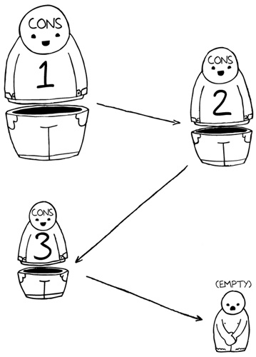

### Functions for CONS Cells

In this day and age, it is rare for a Racket programmer to manipulate cons cells as dotted pairs. Most of the time, these cells are used to build lists and nested lists, and there are great functions for dealing with all kinds of lists.

On some rare occasions, you may want to play with plain cons cells. So here is how you create a **raw cons cell**:

```
> (cons 1 2)
'(1 . 2)
```

As you can see, the result is a list with a dot. You can give a cons cell a name with `define`:

```
> (define cell (cons 'a 'b))
```

And you can extract the pieces of data that you stuck into a cons cell:

```
> (car cell)
'a
> (cdr cell)
'b
```

That is, if `x` is the name for a cons cell, `car` extracts the left piece of data from `x` and `cdr` extracts the right one.

Now you may wonder how anyone can be so crazy as to come up with names like `car` and `cdr`. We do, too. Therefore we focus on cons cells as the building blocks of lists and move on.

### Lists and List Functions

Manipulating lists, not nested cons cells, is important in Racket programming. There are three basic functions for manipulating lists in Racket: `cons`, `first`, and `rest`. But to get started, you want to know that `empty`, `'()`, and `(list)` are all ways to say “empty list.”

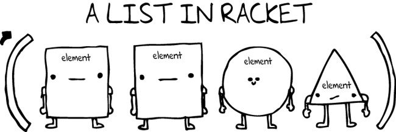

### The CONS Function

If you want to link any two pieces of data in your Racket program, regardless of type, one common way to do that is with the `cons` function. When you call `cons`, Racket allocates a small chunk of memory, the cons cell, to hold references to the objects being linked. Here is a simple example where we `cons` the symbol `chicken` to the empty list:

```
> (cons 'chicken empty)
'(chicken)
```

Notice that the `empty` list is not printed in the output of our `cons` call. There’s a simple reason for this: `empty` is a special value that is used to terminate a list in Racket. That said, the interactions panel is taking a shortcut and using the quote notation to describe a list with one element: `'chicken`.

The lesson here is that Racket will always go out of its way to hide the cons cells from you. The previous example can also be written like this:

```
> (cons 'chicken '())
'(chicken)
```

The empty list, `'()`, can be used interchangeably with `empty` in Racket. Thinking of `empty` as the terminator of a list makes sense. What do you get when you add a chicken to an empty list? Just a list with a chicken in it. Of course, `cons` can add items to the front of the list. For example, to add `'pork` to the front of `'(beef chicken)`, use `cons` like this:

```
> (cons 'pork '(beef chicken))
'(pork beef chicken)
```

When Racketeers talk about using `cons`, they say they are **consing** something. In this example, we consed `'pork` on to a list containing `'beef` and `'chicken`. Since all lists are made of cons cells, our `'(beef chicken)` list must have been created from its own two cons cells:

```
> (cons 'beef (cons 'chicken '()))
'(beef chicken)
```

Combining the previous two examples, we can see what all the lists look like when viewed as conses. This is what is really happening:

```
> (cons 'pork (cons 'beef (cons 'chicken '())))
'(pork beef chicken)
```

Basically, this is telling us that when we `cons` together three items, we get a list of three items.

The interactions panel echoed back to us our entered items as a list, `'(pork beef chicken)`, but it could just as easily, though a little less conveniently, have reported back the items exactly as we entered them. Either response would have been perfectly correct. In Racket, a chain of cons cells and a list are exactly the same thing.

### The LIST Function

For convenience, Racket has many functions built on top of the basic three—`cons`, `first`, and `rest`. A useful one is the `list` function, which does the dirty work of building our list all at once:

```
> (list 'pork 'beef 'chicken)
'(pork beef chicken)
```

Remember that there is no difference between a list created with the `list` function, one created by specifying individual cons cells, and one created with `'`. They’re all the same animal. But consider the following before you rush out and buy all available quotes.

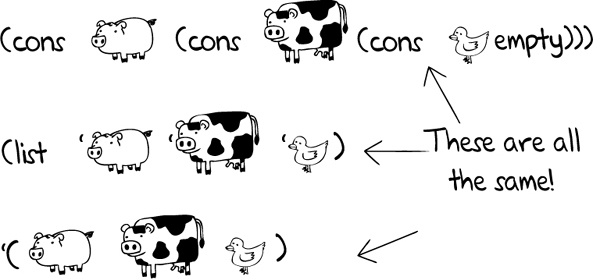

### The FIRST and REST Functions

While `cons` constructs new cons cells and assembles them into lists, there are also operations for disassembling lists. The `first` function is used for getting the first element out of a list:

```
> (first (cons 'pork (cons 'beef (cons 'chicken empty))))
'pork
```

The `rest` function is used to grab the list out of the second part of the cell:

```
> (rest (list 'pork 'beef 'chicken))
'(beef chicken)
```

You can also nest `first` and `rest` to specify further which piece of data you are accessing:

```
> (first (rest '(pork beef chicken)))
'beef
```

You know that `rest` will take away the first item in a list. If you then take that shortened list and use `first`, you’ll get the first item in the new list. Hence, using these two functions together retrieves the second item in the original list.

### Nested Lists

Lists can contain any kind of data, including other lists:

```
> (list 'cat (list 'duck 'bat) 'ant)
'(cat (duck bat) ant)
```

This interaction shows a list containing three elements. The second element is `'(duck bat)`, which is also a list.

However, under the hood, these nested lists are still just made out of cons cells. Let’s look at an example where we pull items out of nested lists.

```
> (first '((peas carrots tomatoes) (pork beef chicken)))
'(peas carrots tomatoes)
> (rest '(peas carrots tomatoes))
'(carrots tomatoes)
> (rest (first '((peas carrots tomatoes) (pork beef chicken))))
'(carrots tomatoes)
```

The `first` function gives us the first item in the list, which is a list in this case. Next, we use the `rest` function to chop off the first item from this inner list, leaving us with `'(carrots tomatoes)`. Using these functions together gives the same result.

As demonstrated in this example, cons cells allow us to create complex structures, and we use them here to build a nested list. To prove that our nested list consists solely of cons cells, here is how we could create the same nested list using only the `cons` function:

```
> (cons (cons 'peas (cons 'carrots (cons 'tomatoes '())))
        (cons (cons 'pork (cons 'beef (cons 'chicken '()))) '()))
'((peas carrots tomatoes) (pork beef chicken))
```

Since various combinations of `first` and `rest` are so common and useful, many are given their own name:

```
> (second '((peas carrots tomatoes) (pork beef chicken) duck))
'(pork beef chicken)
> (third '((peas carrots tomatoes) (pork beef chicken) duck))
'duck
> (first (second '((peas carrots tomatoes)
                  (pork beef chicken)
                  duck)))
'pork
```

In fact, functions for accessing the `first` through `tenth` elements are built in. These functions make it easy to manipulate lists in Racket, no matter how complicated they might be. If you are ever curious about built-in list functions, look in Help Desk.

## 3.5 Structures in Racket

**Structures**, like lists, are yet another means of packaging multiple pieces of data together in Racket. While lists are good for grouping an arbitrary number of items, structures are good for combining a fixed number of items. Say, for example, we need to track the name, student ID number, and dorm room number of every student on campus. In this case, we should use a structure to represent a student’s information because each student has a fixed number of attributes: name, ID, and dorm. However, we would want to use a list to represent all of the students, since the campus has an arbitrary number of students, which may grow and shrink.

### Structure Basics

Defining structures in Racket is simple and straightforward. If we wish to make the student structure for our example, we write the following **structure definition**:

```
> (struct student (name id# dorm))
```

This definition doesn’t actually create any particular student, but instead it creates a new kind of data, which is distinct from all other kinds of data. When we say “creates a new kind of data,” we really mean the structure definition provides functions for constructing and taking apart student structure values. Within `struct`, the first word—in this case, `student`—denotes the name of the structure and is also used as the name of the constructor for `student` values. The parentheses following the name of the structure enclose a series of names for the components of the structure, and the constructor takes that many values.

Let’s create an **instance** of `student`:

```
> (define freshman1 (student 'Joe 1234 'NewHall))
```

Since the structure definition mentions three pieces, we apply the student constructor to three values, thus creating a single value that contains them all. This value is an instance, and it has three **fields**. Just as with any other kind of value, we can give names to structures for easy reference. If we ever need to retrieve information about our `freshman1` student, we just use the **accessors** for student structures:

```
> (student-name freshman1)
'Joe
> (student-id# freshman1)
1234
```

To access the information in a structure field, we call the appropriate accessor function. In this case, we want to pull the `name` from the student structure that we already created, so we’ll use `student-name`. As you can see, the interactions panel shows `'Joe`, which is the value in `freshman1`’s `name` field. When you want to access a different field, you use the function for that field instead, say `student-id#`. As you may have guessed by now, the structure definition creates three such functions: `student-name`, `student-id#`, and `student-dorm`. We sometimes call them **field selectors** or just **selectors**.

In Racket, it is common practice to store data as lists of structures. Say we wanted to keep a list of all the freshman students in a computer science class. Since we could have anywhere from a handful to hundreds or thousands of students in the class, we want to use a list to represent it:

```
> (define mimi (student 'Mimi 1234 'NewHall))
> (define nicole (student 'Nicole 5678 'NewHall))
> (define rose (student 'Rose 8765 'NewHall))
> (define eric (student 'Eric 4321 'NewHall))
> (define in-class (list mimi nicole rose eric))
> (student-id# (third in-class))
8765
```

Here, four students are listed and combined in a list called `in-class`. All of the list functions we discussed in the previous section still apply, and we see that we can still access the fields of the student structures.

### Nesting Structures

It can come in handy to have structures within structures and even within lists. For instance, in our previous example, we could keep all the students in one centralized `student-body` structure for freshmen, sophomores, juniors, and seniors, where each year stands for a list of student structures:

```
> (struct student-body (freshmen sophomores juniors seniors))
> (define all-students
    (student-body (list freshman1 (student 'Mary 0101 'OldHall))
                  (list (student 'Jeff 5678 'OldHall))
                  (list (student 'Bob 4321 'Apartment))
                  empty))
```

Here, we create the `student-body` structure with fields for the four different years. Next, we give the name `all-students` to one specific instance of `student-body`. As you can see, we expect lists of students in each of the four fields of a `student-body` instance.

To retrieve the name of the first freshman in the list, we need to properly layer our accessors:

```
> (student-name (first (student-body-freshmen all-students)))
'Joe
> (student-name (second (student-body-freshmen all-students)))
'Mary
> (student-name (first (student-body-juniors all-students)))
'Bob
```

We want the `student-name` of the `first` of the `student-body-freshmen` list. As we can see, `'Joe` is the name of the first freshman we created before. This also works to get `'Mary` and `'Bob`.

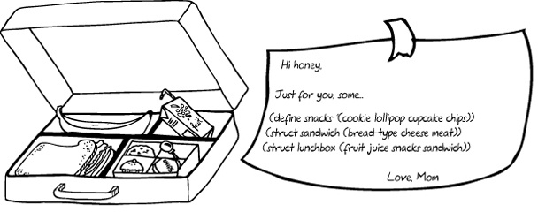

Structures and lists are useful for many different cases, such as organizing data into meaningful compartments that can be easily accessed. In this book, we will be using structures and lists for almost all programs.

### Structure Transparency

By default, Racket creates opaque structures. Among other things, this means that when you create a specific structure and use it in the interactions panel, it does not print just as you created it. Rather, you will see something strange:

```
> (struct example (x y z))
> (define ex1 (example 1 2 3))
> ex1
#<example>
```

If you want to look inside structures, you must use the `#:transparent` option with your structure definition. By some sort of magical process, you will then be able to see your structures in the interactions panel:

```
> (struct example2 (p q r) #:transparent)
> (define ex2 (example2 9 8 7))
> ex2
(example2 9 8 7)
```

All of the structures in this book are supposed to be transparent, and therefore we don’t bother to show the option when we define structures.

## `Interrupt`—Chapter Checkpoint

In this chapter, you saw most of the building blocks of Racket’s syntax and semantics:

- There are many kinds of basic data, like Booleans, symbols, numbers, and strings.
- You can make lists of data.
- You can make your own, new kinds of data with structures.
- You can mix it all up.

## Chapter 4. (Conditions and Decisions)

#|

You’ve now seen Racket’s simple syntax and a bunch of different kinds of data. But can you write a program that answers a question about some piece of data? And can you write a program that chooses different values depending on the answers to these questions? In this chapter, we’ll look at predicates and different forms of conditional evaluation. Among them is an extremely elegant multi-branch conditional that Racketeers use as their major workhorse for many of their programming tasks.

|#

## 4.1 How to Ask

Racketeers think of a conditional as a form that asks questions about values and, depending on the answers, evaluates the appropriate expression. It is therefore natural that this chapter shows you how to ask questions before it introduces conditionals.

A Racket program can ask many kinds of questions, but it always asks questions with **predicates**. You may have heard of predicates in English class, but a Racket predicate is just a function that returns either true or false, which are conventionally written as `#t` and `#f`, but `true`, `#true`, `false`, and `#false` also work. The preceding chapter introduced several such functions, including

- `zero?`, which checks whether its argument is `0`
- `symbol=?`, which compares symbols
- `student?`, but nobody told you that it was there

Let’s check out the first two functions in the interactions panel:

```
> (zero? 42)
#f
> (zero? 0)
#t
> (symbol=? 'a 'b)
#f
```

The first three questions are obvious and so are the answers. Experiment with other questions, say, `(zero? "hello what's up?")` or `(symbol=? "a" 'b)`. Don’t be afraid if it looks like things go wrong; sometimes they are supposed to.

Now let’s take a look at this mysterious `student?` function. Recall our first `struct` definition:

```
> (struct student (name id# dorm) #:transparent)
```

It defines several functions, and we told you about four of them: `student`, `student-name`, `student-id#`, and `student-dorm`:

```
> (define sophomore3 (student 'David 100234 'PG))
> (student-name sophomore3)
'David
```

What we didn’t tell you is that a structure definition also defines a predicate function. Its name is like that of the constructor but with a “`?`” added at the end. We pronounce it “huh?,” so we read `student?` as “student, huh?” (or “student, eh?” in Canada). Here is what it does:

```
> (student? 'a)
#f
> (student? sophomore3)
#t
> (student? (student 1 2 3))
#t
> (student? "i am student")
#f
```

The `student?` function takes one argument. If the value is an instance of the `student` struct, it returns `#t`, aka true. Otherwise, it returns `#f`. Got predicate, huh?

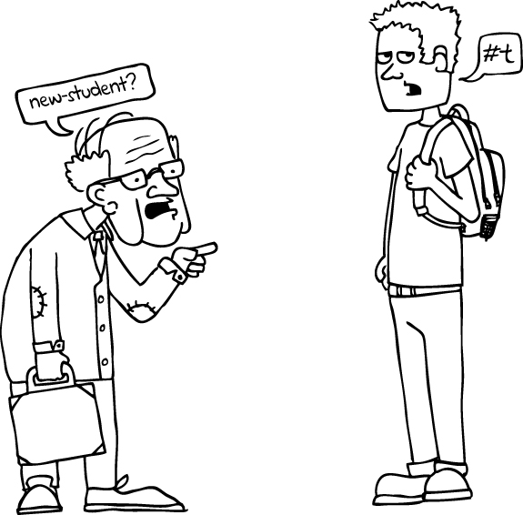

Predicates such as `student?` are often called **type predicates**. These type predicates distinguish one kind of data from all other types of data. Every built-in form of data comes with a type predicate:

```
> (number? 'a)
#f
> (string? "hello world")
#t
> (symbol? 'a)
#t
> (image? 10)
#f
> (boolean? "false")
#f
```

Of course, Racket also has predicates for lists:

```
> (list? 'eh)
#f
> (cons? '(what is that aboot?))
#t
> (empty? 'a)
#f
```

As you can see, it actually has a predicate for lists in general, for non-empty lists, and for empty lists. For numbers, you get even more predicates:

```
> (real? 10)
#t
> (real? (sqrt -1))
#f
> (rational? 2/3)
#t
> (integer? 1.0)
#t
> (integer? 1)
#t
> (exact-integer? 1.0)
#f
```

If you ever need a predicate, guess a name and experiment in the interactions panel. Or look in Help Desk.

So when the preceding chapter says that the struct definition for `student` introduces an entirely new kind of data, it means that no existing type predicate will ever return `#t` when given an instance of `student` and that the new predicate, `student?`, will return `#t` for `student` structs and nothing else.

There is a little bit more to predicates:

```
> (= 1 2)
#f
> (= (sqrt -1) 0+1i)
#t
> (boolean=? #f #f)
#t
> (string=? "hello world" "good bye")
#f
> (equal? (student 'David 100234 'PG) sophomore3)
#t
```

Given that `student?` is called a type predicate, you may have guessed that `symbol=?`, `=`, `boolean=?`, `string=?`, and `equal?` are called **equality predicates**. Most basic forms of data come with functions that compare elements for equality, and for those that don’t, there is `equal?`. Indeed, `equal?` is a function that compares absolutely everything:

```
> (equal? '(1 2 3) '(1 2 3))
#t
> (equal? 'a 'b)
#f
> (equal? "hello world" 'a)
#f
> (equal? 10 10)
#t
> (equal? #t 10)
#f
```

It compares lists, symbols, strings, numbers, Booleans, structs, and more. Not only does it compare numbers with numbers, lists with lists, and so on, but it actually compares numbers with lists, Booleans, strings, and everything else. Furthermore, it also compares data within **composite** data, such as elements within a list or pieces of a structure. It is a universal equality predicate.

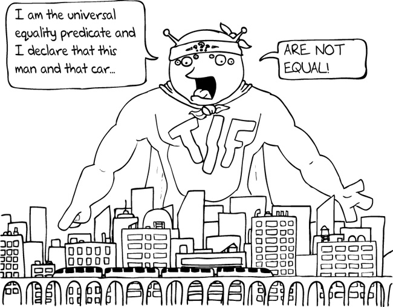

Now you may wonder why Racket bothers with all these equality predicates. You may have noticed that when it comes to functions, we never really mention types. For example, we could define this kind of function:

```
(define (add-to-front-of-123 x)
  (cons x '(1 2 3)))
```

And then we could do this:

```
> (add-to-front-of-123 'a)
'(a 1 2 3)
> (add-to-front-of-123 0)
'(0 1 2 3)
> (add-to-front-of-123 '(a b c))
'((a b c) 1 2 3)
```

Racket would happily create these lists, while `add-to-front` would never wonder what type of data it receives. Types don’t play a restrictive role in Racket. For this reason, Racketeers tend to use equality predicates that tell the reader of their programs about the kind of data they are dealing with. When you see `(equal? x y)`, you get no hints. In contrast, the program snippet `(= x y)` immediately conveys that `x` and `y` should be numbers, and if they aren’t, Racket will let you know. As you will see, these little hints thrown into a program are quite valuable when you try to decipher its meaning.

## 4.2 The Conditionals: IF and Beyond

Now that you understand predicates, let’s look at `if`, a conditional that you have probably encountered in your previous programming experience.

The basic idea behind a conditional expression is that some code is evaluated *only under some condition*. It’s an old idea that goes back to John McCarthy, who first used conditionals in the 1960s as a convenient way to implement mathematical functions. These days, you would be hard-pressed to find a program that doesn’t contain a conditional.

### One Thing at a Time with IF

An **`if` expression** can be used to choose between two different computations based on a computation that produces true or false:

```
> (if (= (+ 1 2) 3)
      'yup
      'nope)
'yup
> (if (= (+ 1 2) 4)
      'yup
      'nope)
'nope
```

In the eyes of Racket’s `if`, as well as all in its other conditional forms, `#f` is false and anything that is not false is true. It’s an old, slightly weird Lisp tradition that Racket kept and that is really convenient once you’re used to it. Some examples should clear up any confusion:

```
> (if '(1)
      'everything-except-#f-counts-as-#t
      'aw-heck-no)
'everything-except-#f-counts-as-#t
> (if empty
      'everything-except-#f-counts-as-#t
      'aw-heck-no)
'everything-except-#f-counts-as-#t
> (if false
      'everything-except-#f-counts-as-#t
      'aw-heck-no)
'aw-heck-no
```

Notice how `'(1)` counts as true according to `if`. The same is true of `empty`. Remember, everything that is not `#f` is true.

Here is an `if` expression that actually asks a question with a predicate:

```
> (if (odd? 5) 'odd-number 'even-number)
'odd-number
```

All we’re doing here is asking whether `5` is odd and then, depending on the answer, evaluating one of the two following expressions in the `if` form. Since `5` is odd, `if` evaluates the first such expression, and as a whole it returns `'odd-number`.

There’s a lot happening in this harmless-looking `if` expression, and it’s all important for understanding Racket. Consider the template of an `if` expression:

```
(if some-expression
    an-expression
    another-expression)
```

Here, the first of the expressions, `some-expression`, is called the **test**; the second one is known as the **then** expression; and the third one is dubbed the **else** expression. The last two expressions are also known as **branches**. Knowing these labels for the pieces of an `if` expression helps us talk about it.

The key observation is that only one of the two expressions that follow the test expression in an `if` form is actually evaluated. Usually, when a function call is executed in Racket, all the arguments are evaluated before the function is called. However, `if` does not follow these rules. Consider this example:

```
> (if (odd? 5)
      'odd-number
      (/ 1 0))
'odd-number
```

Any self-respecting, law-abiding *function* would kick your butt to the curb if you tried to run this code, because the else branch is dividing by zero.

But `if` isn’t really a function. Like `define`, it’s a special **form**, and all forms have special privileges, such as the right to not evaluate all their arguments in the normal way. This makes sense, since the whole point of a conditional is to evaluate only a certain expression and not the others. In this case, `if` merrily ignores the division by zero because it’s in the branch that applies only to even numbers. Conditional expressions in Racket are typically special forms.

### The Special Form that Does It All: COND

If you ever want to make more than one decision, you can nest `if` expressions, just as you may have done with other languages.

```
> (define x 7)
> (if (even? x)
      'even-number
      (if (= x 7)
          5
          'odd-number))
5
```

This example consists of an `if` expression nested in the else branch of another `if` expression. The question of the outer `if` finds out whether the value of `x` is an even number; if not, `x` is odd, and thus the inner `if` can check whether `x` is equal to `7`.

But what do you do if you’re the kind of coder who wants it clear-cut and simple? Well, Racket has you covered.

The **`cond` expression** is the classic way to do branching in Racket. It can handle many branches instead of just two. Since `cond` has been around since the Racket Stone Age, many Racket programmers consider it to be the one true Racket conditional form.

Here’s an example of `cond`:

```
> (define x 7)
> (cond [(= x 7) 5]
        [(odd? x) 'odd-number]
        [else 'even-number])
```

As you can see, the body of a `cond` uses layers of brackets to separate the different branches. The first expression of each such branch contains the condition for making that branch active. In our example, we are checking for different qualities about variable `x`.

The conditions in a `cond` form are always checked consecutively from top to bottom, meaning the first successful match drives the behavior. So it makes sense that we check first to see if the number is equal to `7` and then if it is odd. Otherwise, `cond` would never find the case of `x` equals `7`. In this example, the last bracketed part has `else` as its condition, which catches the rest of the numbers. If the number is not `7` and not odd, then it must be even.

It is a common `cond` idiom to use `else` as the last branch because it ensures that the conditional will evaluate some branch. You should experiment and change the value of `x` in its definition to see what happens with the `cond` expression. Also, formulate a `cond` expression that checks conditions in the exact same order as the above nested `if` expression. Experiment with your revised expression, too. Convince yourself that all three expressions have the same meaning.

### A First Taste of Recursion

Because we know about `if` and `cond` and how to detect an empty list, we can now process lists using **recursion**. You may have been told to be scared of recursion, but we dealt with it in our third week of programming—if we figured it out, you can figure it out, too. It all just boils down to one point: we can take items from the front of a list and send the rest of the list back to the same function until the list is empty. That process is called a **list-eater**, and it sure is a good thing that detecting empty lists is easy, because so many functions in Racket end up being list-eaters.

Let’s look at a common list-eating function:

```
(define (my-length a-list)
  (if (empty? a-list)
      0
      (add1 (my-length (rest a-list)))))
```

You can probably guess what it does, but just to make sure, here are some examples:

```
> (my-length '(list with four symbols))
4
> (my-length '(42))
1
```

As these examples show, this first recursive function calculates the length of a list.

The function is written in classic Racket style. Since a list is either empty or non-empty, the function checks whether its argument, `a-list`, is empty. If it is empty, we know how many items are on the given list, `0`, and that’s what the function returns. If `a-list` is not empty, we know that it contains at least one item. We also know that `(my-length (rest a-list))` calculates the length of the `rest` of the list. To get the length of the entire `a-list`, the function just needs to add `1`.

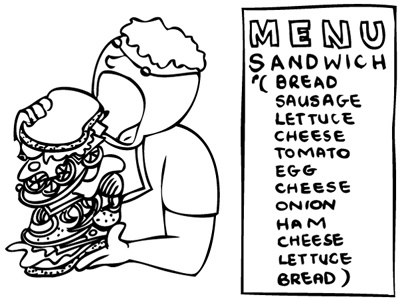

If these interactions do not make sense to you, try looking at one step-by-step:

```
(my-length (list 'a 'b))
== (my-length (cons 'a (cons 'b empty)))
== (add1 (my-length (rest (cons 'a (cons 'b empty)))))
== (add1 (my-length (cons 'b empty)))
== (add1 (add1 (rest (cons 'b empty))))
== (add1 (add1 (my-length empty)))
== (add1 (add1 0))
== (add1 1)
== 2
```

For now, this is enough recursion. We will show you more list-eaters in Chapter 6 when we discuss how to create a Snake game.

## 4.3 Cool Tricks with Conditionals

There are two counterintuitive tricks involving conditionals that can help you write concise code. The first involves `and` and `or`, which are actually shorthand for conditionals. The second takes advantage of Racket’s conception of truth and falsehood.

### Using the Stealth Conditionals AND and OR

The conditionals `and` and `or` look like simple mathematical operators that allow you to compose complex questions from simple ones. They help you manipulate Boolean values in the same way that you might manipulate numbers with addition and subtraction. For example, here’s how we could use `and` to see if three numbers are odd:

```
> (define x 5)
> (define y 7)
> (define z 9)
> (and (odd? x) (odd? y) (odd? z))
#t
```

Because `5`, `7`, and `9` are odd, the entire expression evaluates to true. Similarly, we can use `or` to see whether at least one of a bunch of numbers is odd:

```
> (define w 4)
> (or (odd? w) (odd? y) (odd? z))
#t
```

Because `7` is odd, the `or` expression still evaluates to true, despite the fact that `4` is even.

But there’s something interesting about `and` and `or` that you might not notice just by looking at these two examples. So far, these two forms look like ordinary mathematical functions; they do not look like conditional forms, such as `if` and `cond`. However, they can be used to code conditional behavior. For instance, here’s a variable definition:

```
> (define is-it-even #f)
> is-it-even
#f
```

You can use conditionals to change the value of the variables, like this:

```
> (or (odd? x) (set! is-it-even #t))
#t
> (and (even? x) (set! is-it-even #t))
#f
> is-it-even
#f
```

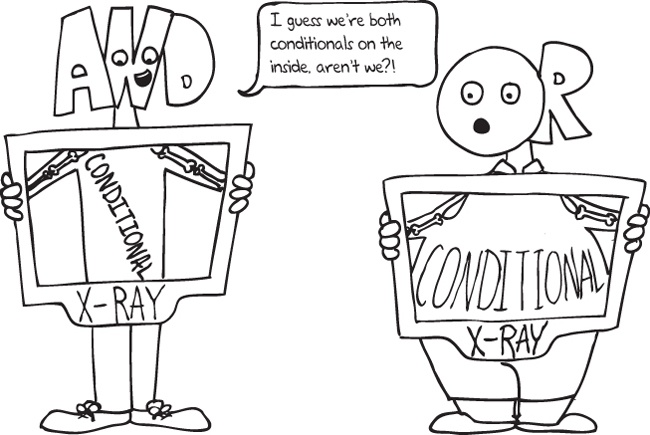

When we check on `is-it-even`, the variable remains unchanged. In fact, our `or` expression produces true because of shortcut Boolean evaluation. This means that once Racket determines that an expression in a sequence of `or` values is true, it simply returns true and doesn’t bother evaluating the remaining conditions. However, the value of `is-it-even` does change when we use an even number in our first `or` clause:

```
> (or (odd? w) (set! is-it-even #t))
> is-it-even
#t
```

In this case, the first expression produces false, causing the evaluation of the second expression, which changes `is-it-even` to `#t`.

The shortcut evaluation for `and` works in the opposite way. If `and` determines that an early expression of `and` is false, it stops with `#f` without bothering to evaluate the rest of the expressions:

```
> (and (odd? 5) (even? 5) (/ 1 0))
#f
```

While this may seem like an unimportant distinction, it can actually be very useful in many situations. For instance, imagine that you want to save a file to disk, but only if the file is modified and only if the user wants it to be saved. The basic code could be written as follows:

```
> (if file-modified
      (if (ask-user-about-saving)
          (save-file)
          false)
      false)
```

Here, the function `ask-user-about-saving` would ask the user about saving the file, and it would return true or false based on the user’s wishes. However, since shortcut Boolean evaluation is guaranteed for Boolean operations, we could write this five-line conditional in one line:

```
> (and file-modified (ask-user-about-saving) (save-file))
```

Using this concise style for conditionally evaluating code is possible only if you think beyond the typical use of the Boolean operators as mathematical operators.

A third way to write this code, which is a compromise between the previous approaches, is as follows:

```
> (when (and file-modified (ask-user-about-saving))
    (save-file))
```

Many experienced Racketeers will consider this version the best because it separates the condition from the action. Specifically, a **`when` conditional** is like an `if` without an else branch. The keyword signals that the program will test a condition and then perform some action, but only if the condition evaluates to `#t`. Naturally, Racket also comes with an **`unless` form**, which is the opposite of `when`:

```
> (define filename "my-first-program.rkt")
> (unless (ask-user-whether-to-keep-file filename)
    (delete-file filename))
```

An `unless` form performs some action if its condition returns `#f`.

### Using Functions that Return More than Just the Truth

Now let’s look at another benefit of Racket’s way of thinking about true and false. As we’ve already discussed, any value other than `#f` counts as true in Racket. This means that functions that are commonly used in conditions have the option of returning more than just the truth. For instance, the Racket function `member` can be used to check for the membership of an item in a list:

```
> (if (member 4 (list 3 4 1 5)) '4-is-in 'not-in)
'4-is-in
```

This seems pretty straightforward. However, once again there is something happening behind the scenes that you may not expect. Let’s run the `member` expression in isolation:

```
> (member 1 '(3 4 1 5))
'(1 5)
```

What the heck happened here? Why is `member` returning `'(1 5)`? Actually, there’s a perfectly rational explanation for this. Whenever a Racketeer writes a function that returns true or false, she will think to herself, “Is there anything else I could return other than just true?” Since all non-false values in Racket count as true, returning some other value is essentially a freebie. The implementors of the `member` function decided that some crazy Racketeer somewhere may see the value in having the tail of the list for some calculation that uses this function.

Just in case you think they are crazy, here is an example that exploits this trick:

```
> (define tasks '(1 clean 3 homework 4 party))
> (member 3 tasks)
'(3 homework 4 party)
```

The `tasks` list enumerates a sequence of jobs that someone needs to complete. When you now use `member` to look up the task labeled `3`, the function doesn’t just produce `#t`, but it produces what the list contains for the task labeled `3` and subsequent tasks in the list. Of course, this list counts as true, too, but it is a more informative kind of truth. From there, you can see that task number `3` is `'homework`, followed by `4` and `'party`. Go party for a while.

## 4.4 Equality Predicates, Once More

4.1 How to Ask presents a plethora of equality predicates. There are some that are specialized to particular kinds of data, like `string=?`, and there is also `equal?`, which is not specialized at all. The `equal?` function compares any kind of data, even composite structures. But `equal?` isn’t the only universal equality predicate, and it’s important to understand the alternatives.

Let’s look at another struct definition:

```
> (struct point (x y) #:transparent)
```

### Note

#|

Did you notice that we used #:transparent even though we promised not to bother you with that anymore? In this case, we really want you to remember it, because it is necessary here. If this seems opaque, omit the keyword and see what happens.

|#

It introduces a class of `point` structs, each with two fields: `x` and `y`. You should recall that this kind of `struct` definition simply defines a bunch of functions for creating, manipulating, and discovering concrete instances:

- `point`
- `point-x`
- `point-y`
- `point?`

With these you could, for example, define a function that determines the distance of a `point` from the origin; that is, `(point 0 0)`. Here, let’s try it:

```
(define (distance-to-origin p)
  (sqrt (+ (sqr (point-x p)) (sqr (point-y p)))))
```

You may recall from high school mathematics how to explore this function after clicking the “Run” button:

```
> (distance-to-origin (point 3 4))
5
```

Also try it with `12` and `5`. What do you expect as the result? Why?

It is possible to give names to points with `define`:

```
> (define pt1 (point -1 2))
> (define pt2 (point -1 2))
```

And yes, `pt1` and `pt2` look equal, and `equal?` says they are:

```
> (equal? pt1 pt2)
#t
```

The reason is that `equal?` checks that both arguments belong to the same class of data, namely points, and that all their pieces—`x` and `y` here—are `equal?`, too.

You may have noticed that the description of `equal?` seems recursive, kind of like `my-length` from before. We tend to think of `equal?` like this:

```
(define (my-equal? a b)
  (cond
    [(and (point? a) (point? b))
     (and (my-equal? (point-x a) (point-x b))
          (my-equal? (point-x a) (point-x b)))]
    ...
    ;; Every struct definition adds a cond clause.
    [(and (cons? a) (cons? b))
     (and (my-equal? (car a) (car b))
          (my-equal? (cdr a) (cdr b)))]
    [(and (empty? a) (empty? b))
     #t]
    [(and (symbol? a) (symbol? b))
     (symbol=? a b)]
    [(and (number? a) (number? b))
     (number=? a b)]
    [(and (boolean? a) (boolean? b))
     (boolean=? a b)]
    ...
    ;; Every primitive form of data has a cond clause here.
    [else #f]))
```

Whenever a program defines a `struct`, the function is updated to contain a line like the one for `point` so that `equal?` can deal with this new kind of data. Subsequent lines compare basic forms of data. In addition to symbols, numbers, and strings, Racket supports other forms of basic data, but we don’t need them in this book.

But `equal?` isn’t always what you need. Sometimes you don’t want to compare the pieces of a structure; instead, you want to know whether the two given concrete structures were created via the exact same call to the constructor. To this end, Racket provides the `eq?` function:

```
> (eq? pt1 pt2)
#f
> (eq? pt1 pt1)
#t
> (eq? pt2 pt2)
#t
```

As these interactions with Racket show, `eq?` recognizes that `pt1` is equal to itself and so is `pt2`, but `pt1` and `pt2` were created at different times.

In Racket, it is also possible to give new names to existing values:

```
> (define pt3 pt1)
```

The `eq?` function knows about such things:

```
> (eq? pt1 pt3)
#t
```

Indeed, it even works through composite data:

```
> (define (eq-first-items list1 list2)
    (eq? (first list1) (first list2)))
> (eq-first-items (cons pt1 empty) (cons pt3 empty))
#t
> (eq-first-items (cons pt1 empty) (cons pt2 empty))
#f
```

Chapter 8 will introduce a way to change the values of the fields of structures. Once this additional expressive power is available, the difference between `eq?` and `equal?` becomes critical. While `equal?` compares whether two values consist of identical pieces, `eq?` compares whether changing one structure changes the other structure, and that happens only when the structures were created with the exact same call to the constructor function.

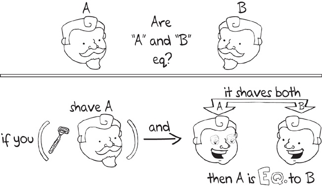

In summary, equality is a subtle property. Almost all programming languages offer functions such as `eq?` and `equal?`, and it is important to appreciate the differences. Most of the time, the equality predicates discussed in 4.1 How to Ask will serve your programming needs just fine. But for some occasions, you need `eq?`, and here we have prepared you for just those occasions.

## 4.5 Comparing and Testing

Equality matters a lot when it comes to testing. When you write programs, you should create tests for almost all the functions in your code. As a matter of fact, you should write tests before you even write the functions.

In principle, a **test** consists of two pieces: a function call and an expected result value. Racket evaluates the function call and then compares the result with the expected value. If they are equal, you learn that the function works correctly on that input. If not, something is wrong: your function, your test, or both.

Racket provides several libraries for testing. One such library is `rackunit`. Whenever you need to use one of Racket’s provided libraries, you **`require`** that library:

```
> (require rackunit)
```

This makes all the functionality of `rackunit` available in the interactions panel. If you want this functionality in your programs, you add the line to the definitions panel. You can find documentation for `rackunit` in Help Desk by pressing the “F1” key on most computers. Browse the docs at your leisure. Here we cover just the basics.

### Writing a Test

When testing in `rackunit`, the most commonly used function is `check-equal?`, which takes two expressions, evaluates them, and compares them for equality using the `equal?` function. So suppose you want to test the `add1` function. You know that whenever you apply `add1` to `5`, you expect `6` back, and here is how you write down this expectation:

```
> (check-equal? (add1 5) 6)
>
```

Notice how the expression seems to do nothing. But it really does check whether `(add1 5)` and `6` are equal, and you can see so for yourself by entering a test that fails:

```
> (check-equal? (add1 5) 7)

FAILURE
name:      check-equal?
location:   ...
expression: (check-equal? (add1 5) 7)
actual:     6
expected:   7
```

Since `(add1 5)` evaluates to `6` and not `7`, `check-equal?` signals that this test has failed. The call to a function has produced an actual result that differs from the expected result. And that is what a test is all about.

### What Is Not a Test

Sometimes you may wish to test the composition of functions. Nevertheless, even in these cases, a test consists of an expression and its expected outcome. For example, the following test says that `sub1` is the inverse of `add1`, at least for the number `5`:

```
> (check-equal? (sub1 (add1 5)) 5)
```

When you run a function or a program, you are not testing it—you are exploring its behavior. You may have certain ideas in mind of how it should behave, but as long as you don’t write down this expectation beforehand, and as long as there is no automatic comparison, it is *not a test*.

### Testing in the Real World

Any testing function can take an optional third argument: a string. This is a helpful way to clarify what the test means:

```
> (check-equal? 5 6 "NUMBERS MATTER!")

FAILURE
name: check-equal?
location: ...
expression: (check-equal? 5 6)
params: (5 6)
message: "NUMBERS MATTER!"
actual: 5
expected: 6
```

When a test fails, this string is displayed in a prominent position. You will find that when a program comes with a few hundred tests, these messages can be very handy.

All of the programs that come with the book have extensive test suites. Indeed, in our freshman year, we always wrote tests before starting on our functions. We are now real believers—there simply is no other way to write good programs. But we don’t have the space in this book to explain the tests for the programs. We suggest that you open some of our games in DrRacket and look at the test suites so that you get a sense of what test suites look like.

### More Testing Facilities

Here are a few more testing functions from `rackunit` that you may find in our code.

| Name | Purpose | Example (all pass) |
| --- | --- | --- |
| `check-not-equal?` | Checks for inequality | `(check-not-equal? 5 4)` |
| `check-pred` | Checks the second argument against the predicate | `(check-pred number? 5)` |
| `check-=` | Checks if two numbers are within a certain range of each other | `(check-= 1 3 2)` |
| `check-true` | Checks if the argument is `#t` | `(check-true (odd? 71))` |
| `check-false` | Checks if the argument is `#f` | `(check-false (odd? 42))` |
| `check-not-false` | Checks if the argument is not `#f` | (check-not-false (member 5 '(1 2 5))) |

## `Call-with-current-continuation`—Chapter Checkpoint

In this chapter, you learned about predicates, conditionals, and testing:

- Racket has predicates, including type and equality predicates.
- There are many conditionals, but `if` and `cond` are the most important ones.
- Conditionals tend to use predicates to ask questions about values, and the rest of the computation depends on the questions’ outcomes.
- The `rackunit` library is for writing tests.
- To test means to compare the outcome of expressions with expected answers.
- All of our programs come with tests, but we don’t show the tests in the book.

## Chapter 4½. (define define ’define)

#|

So far, we have covered the basics of defining variables and functions. Did you wonder if there was more to it? In this chapter, we will show you everything you need to know about definitions.

|#

## 4½.1 Module-Level Definitions

The most common kind of definitions are **module-level definitions**. These introduce names that can be accessed anywhere in the module. For now, think of a module as the definitions panel. There are two kinds of module-level definitions: variable definitions and function definitions.

### Variable Definitions

Let’s begin with variable definitions. Suppose we were to develop a graphical version of the Guess My Number game from Chapter 2 that displays its results on a window of some fixed size. The right approach in this scenario is to define variables for the width and height of the window.

```
(define WIDTH 100)
(define HEIGHT 200)
```

By convention, we use uppercase for the names of module-level definitions that introduce **constants**. Doing so makes constants stand out. These constant definitions can also name computed values instead of hard-coded ones:

```
(define X-CENTER (quotient WIDTH 2))
(define Y-CENTER (quotient HEIGHT 2))
```

Defining a constant and referencing it throughout the program is highly preferable to using literal constants everywhere. Once you have done so, you can change the value where it is defined, and then everything else that references the constant will use the new value as well. This provides a single point of control. For example, if we defined the constant `WIDTH` to be `100` and later we realize that the resulting image is too small, we could simply change the definition of `WIDTH` to `200`, and this value will be used as the width throughout the whole program. In particular, `X-CENTER` would change from `50` to `100`.

A more feeble-minded programmer might have instead first littered the program with `100`s. After deciding the window was too small, he would need to change all of those `100`s to `200`s. Being lazy, he might just search and replace `100` with `200`, which has the intended effect of making the window bigger, but also has the unintended effect of making the game start by guessing `100` instead of `50`. Can you figure out why?

To avoid these kinds of issues, we define constants for elements of our game that do not change throughout the code. For example, these elements could be image size, instructions, colors, and so on. Another benefit of coding this way is that if someone wants to play our game in Arabic or Zulu instead of English, all he needs to do is look for the section in the code where the strings are defined and change these constant strings to his preferred language.

We define constants separately from code for every single program in this book. However, we will not show you all the constant definitions because we’re more interested in talking about games than constants. The constants are available in the source code, which is only a few keystrokes away.

At times, we must impose some limits on these constants. We wouldn’t want someone to replace the height of our screen with a negative number. To check that the constant is always appropriate, we can provide a section of code below the constant definition that will raise an error if the value we have provided is inappropriate:

```
(unless (> HEIGHT 0)
  (error 'guess-my-number "HEIGHT may not be negative"))
```

This check works because any code that is placed in the definitions panel is executed when we hit “Run.” It will be as if that portion of the code had been typed in the interactions panel. In this case, we tell DrRacket to signal an error and inform the programmer that a constraint has been broken.

### Function Definitions

The other kind of module-level definition is a function definition, and we’ve already seen several of these. These defined functions can be called anywhere in the module:

```
(define SQR-COLOR "red")
(define SQR-SIZE 10)
(define (draw-square img x y)
  (place-image (square SQR-SIZE "solid" SQR-COLOR)
               x y
               img))
```

As we saw before, a function definition is composed of the keyword `define`, followed by the name of the function and any arguments, all enclosed in parentheses. This function header is followed by the expressions that will be executed when the function is called.

## 4½.2 Local Definitions

In Racket, you can place the same kind of definition that you placed at the module level inside function definitions. More precisely, a definition may show up within any sequence of expressions inside function definitions and `cond`s, as long as it’s not the last expression.

Such **local definitions** are useful if you don’t want to compute a value multiple times or if you don’t want to nest expressions too deeply. These definitions exist only within the pair of parentheses in which they are defined and cannot be accessed anywhere else. We call this the **scope** of the definition. For instance, consider this program fragment:

```
(struct posn (x y))
(struct rectangle (width height))
(define (inside-of-rectangle? r p)
  (define x (posn-x p))
  (define y (posn-y p))
  (define width (rectangle-width r))
  (define height (rectangle-height r))
  (and (<= 0 x) (< x width) (<= 0 y) (< y height)))
```

The scope of `x`, `y`, `width`, and `height` is the entire body of the `inside-of-rectangle?` function. We introduce these variable definitions to eliminate some nesting from the `and` expression. We assume you figured out that this function computes whether a given point is within a rectangle.

Local definitions even work within a `cond`:

```
(define (random-stars n)
  (cond
    [(zero? n) '()]
    [else (define location (random-location 200 300))
          (if (inside-moon? location)
              (random-stars n)
              (cons location (random-stars (sub1 n))))]))
```

This function is a natural number–eater. When it is given a natural number—zero, one, two, and so on—`random-stars` checks whether the number is zero. In the `else` case, it will recur with one less than the given number, so sooner or later, the function will pick the first case. It is more important, however, to understand the local definition in the `else` case. It names a random place in a `200`×`300` grid `location`, and this name stands for the random position between the brackets `[ ]` of the second arm in the `cond`. Conversely, `location` is not available elsewhere in the scope of the function definition or the module itself.

Why do we name the random place `location`? The whole point of `random-location` is to pick some place out of 60,000 possible places, choosing a random one every time the function is called. Hence, if we wrote this . . .

```
(if (inside-moon? (random-location 200 300))
    (random-stars n)
    (cons (random-location 200 300) (random-stars (sub1 n))))
```

. . . it’s very likely that the two calls would pick two distinct locations. Worse, the second time it picks a place, it may appear within the shape of the moon, which we wish to avoid.

Here is another example of a local definition:

```
(define (winners lst pred)
  (cond
    [(empty? lst) (list pred)]
    [else
     (define fst (first lst))
     (if (score> (record-score pred) (record-score fst))
         (list pred)
         (cons pred (winners (rest lst) fst)))]))
```

The purpose of the function is to pick the first-place finishers from a list of game records. As you can see, the function definition relies on several assumptions. First, its code suggests that we have a struct definition of the following shape:

```
(struct record (name score))
```

The `name` field records the name of the player, and the `score` field records the player’s performance. Second, `lst` is a list of such records, and `pred` is one such record. Indeed, the original list is `(cons pred lst)`, and it is sorted according to score. Somehow, `winners` is applied to the `first` and the `rest` of the list. Now in this context, you understand that `winners` is a list-eating function and goes through one record at a time. When there is at least one other record, it picks the first one, names it `fst`, and compares the scores of `fst` and its predecessors. Depending on the outcome, all winning records have been picked off or `winners` has to continue the search for equal-scoring players.

In this case, we use the local definition of `fst` only to make the code more readable. While we could avoid the definition and copy the expression wherever `fst` appears, it would make the code look large and bulky. Because Racket delimits the scope to the brackets of the second arm of the `cond`, there is also no harm in introducing yet another name into the world. If we need to use it again, we can do so outside this small scope.

Finally, you may be wondering who guarantees that `winners` is always applied to the `rest` and the `first` of some sorted list. To avoid any mistakes, we need to show you *locally defined* functions:

```
(define (winning-players lst)
  (define sorted-lst (sort lst ...))
  (define (winners lst pred)
    (cond
      [(empty? lst) (list pred)]
      [else
  (define fst (first lst))
  (if (score> (record-score pred) (record-score fst))
      (list pred)
      (cons pred (winners (rest lst) fst)))]))
  ;; START HERE:
  (winners (rest sorted-lst) (first sorted-lst)))
```

This form of local function definition is a common idiom. Since `winners` shouldn’t be applied to arbitrary lists and records, we hide it by defining it within the scope of some other function that consumes a list of records. Then this function sorts the list and applies `winners` to the appropriate pieces. As you know by now, the function named `winners` can be accessed only between `(define` and its closing parenthesis, and therefore no one can apply this function in the wrong way.

## `Abort`—Chapter Checkpoint

In this chapter, you learned:

- How to write module-level variable and function definitions
- The advantages of introducing constant definitions
- How to write local, variable, and function definitions
- Where to place local, variable, and function definitions
- The benefits of defining variables and functions locally

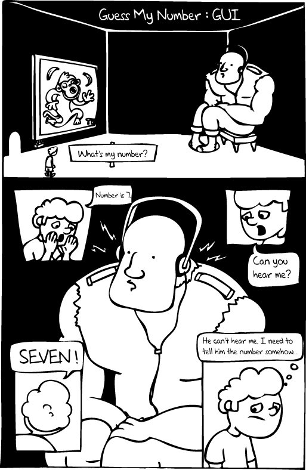

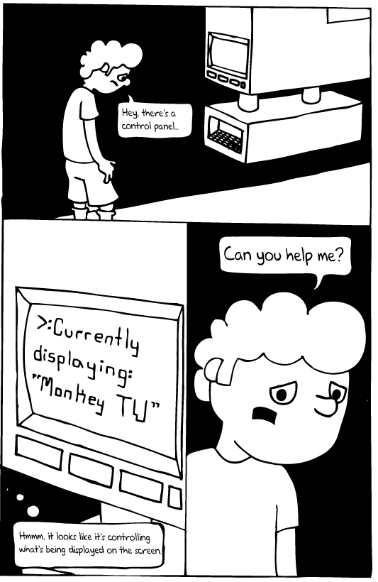

## Chapter 5. (big-bang)

#|

While Guess My Number may not be the world’s most exciting game, it was easy to write. Obviously, it doesn’t look anything like the software apps you use on your laptop or phone. Now think about how amazing it would be if Guess My Number came with a full-fledged graphical user interface. In this chapter, we’ll give it exactly that. As it turns out, this is super easy.

|#

## 5.1 Graphical User Interface

Text-based games can be fun and rouse our inner geek, but they are so ’70s. Let’s move on to at least the ’80s where, at a minimum, software needs a **graphical user interface (GUI)**, which we endearingly pronounce as “gooey.” Intuitively, you know what a GUI is because you have used a lot of graphical software applications. These are programs that react to mouse events, keystrokes, and many other things, including clock ticks. Every computer comes with a clock—a little device that ticks every so often. If your program reacts to these clock ticks, it can create the illusion of continuously moving objects.

Racket provides several libraries for creating GUIs, and here we will combine two of these libraries to create animations and games: `2htdp/universe` and `2htdp/image`. The first library defines a special form called `big-bang` that creates interactive programs, which we call **worlds**. The second one provides a bunch of functions for manipulating images. From now on, most of your programs will start with these two lines:

```
#lang racket
(require 2htdp/universe 2htdp/image)
```

The first line says that we’re using the Racket programming language, and the second tells Racket that our program needs all the functionality from the two libraries.

### Note

#|

The 2htdp in the name of the library refers to the second edition of the textbook for our course, “How to Design Programs,” available online at htdp.org.

|#

We mentioned that `big-bang` creates worlds. But what exactly is a world? There are two ways to describe it: the state and the view. The states of a world refers to a class of data, each element of which we can meaningfully interpret in the context of the animation or game. A specific state is an element of this class, and it is `big-bang`’s task to know the current state. For example, if you have an animation of a descending UFO, then you might say that any positive integer is a state, and its meaning is the distance that the UFO has traveled toward Earth. Of course, players want to see the world, not some piece of data, and that is what we call the **view** of the world. In our example, this could be a picture of a little cartoon UFO flying across the screen.

## 5.2 Landing a UFO

To get from the state of the world to its view, you need a function that renders the state as an image. For the UFO animation example, a state of `42` can mean that your program should place the image of a UFO 42 pixels from the top of some background image.

However, rendering a world isn’t enough. Your program must change the state of the world on occasion. For example, you may wish to lower the UFO by three pixels every time the clock ticks. If the initial state of the world is `0`, it will be `3` after one clock tick, `6` after two, `9` after three, and so on. Can you imagine the images that come with these states of the world? In the first image, the UFO is `0` pixels from the top. In the second image, it is `3` pixels down. And by the third tick, it is already `6` pixels down. Now imagine that the clock ticks every 1/28 second, and your program makes the computer render an image every time the clock ticks. When you display a sequence of still frames at this rate, you get a movie—that is, you get the impression of movement on the screen. An animation is simply the rapid-fire display of plain old still images.

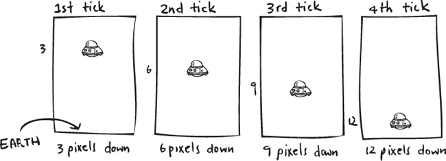

With `big-bang`, we can create an animation of a UFO landing in a snap:

```
(big-bang 0
          (on-tick add-3-to-state)
          (to-draw draw-a-ufo-onto-an-empty-scene))
```

Here we are using two functions we haven’t defined yet: `add-3-to-state` and `draw-a-ufo-onto-an-empty-scene`. Each function will take in the current state of the world as an argument. The first function, `add-3-to-state`, adds `3` to the state it gets, and it returns the result, which `big-bang` turns into the next state:

```
(define (add-3-to-state current-state)
  (+ current-state 3))
```

The second function, `draw-a-ufo-onto-an-empty-scene`, places the image of a UFO onto an empty scene at `current-state` pixels from the top. Our world’s state doesn’t tell us how far from the left or right the UFO is placed, so let’s just put it in the middle. You may have a different number in mind, and that’s totally fine with us:

```
(define (draw-a-ufo-onto-an-empty-scene current-state)
  (place-image IMAGE-of-UFO (/ WIDTH 2) current-state
               (empty-scene WIDTH HEIGHT)))
```

Like a painter, we can create our images on empty canvases. Luckily, we don’t need to do the stretching and stapling. All we have to say is `(empty-scene WIDTH HEIGHT)`, and DrRacket will give us a white rectangular image that is `WIDTH` by `HEIGHT` pixels with a thin black border around it. Neat, huh? Then we call `place-image` to place our `IMAGE-of-UFO` at `(/ WIDTH 2)` pixels from the left margin and `current-state` pixels from the top margin of the scene.

You might be wondering why the coordinates of `place-image` go top down and not bottom up, as with ordinary mathematics. Well, hardware people decided long ago that this is how they wanted coordinates to work on computer monitors. Here’s a diagram that shows how the coordinate system works:

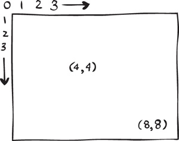

Now there is only one thing left to do:

```
(define IMAGE-of-UFO ...)
```

We want you to insert your favorite image of a UFO in lieu of the dots. Go find one on the Web. Save it on your computer. Then use DrRacket’s “Insert” menu to put it in the right place. Yup, it works! Or use your epic artistic skills to draw one with the functions in `2htdp/image`. That’s right, you can use the interactions panel to make a UFO of your own. Images really are just values in Racket, and with DrRacket, you can easily experiment with image compositions. Every expression that you evaluate in the interactions panel is printed, where “printing” means rendering for images. Go ahead, try out some other image functions from `2htdp/image`.

Let’s experiment with the two functions in the interactions panel:

```
> IMAGE-of-UFO
```

```
> (draw-a-ufo-onto-an-empty-canvas 33)
```

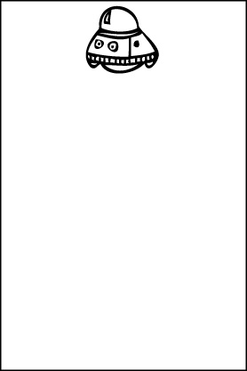

We could, and you should, call the function on `36`, `39`, `42`, and so on. These would show us more of the still images that make up the animation.

So here’s the complete program:

```
(define (add-3-to-state current-state)
  (+ current-state 3))

(define (draw-a-ufo-onto-an-empty-scene current-state)
  (place-image
   IMAGE-of-UFO (/ WIDTH 2) current-state
   (empty-scene WIDTH HEIGHT)))

(define IMAGE-of-UFO ...)

(big-bang 0
          (on-tick add-3-to-state)
          (to-draw draw-a-ufo-onto-an-empty-scene))
```

Click “Run” and watch the descent of the UFO to Earth. But see how it goes right through the bottom of the scene? Stop the program with the “Stop” button.

Our animation isn’t any good because we want the UFO to land on Earth. Let’s make it stop with a little help from `big-bang`:

```
(define (state-is-300 current-state)
  (>= current-state 300))

(big-bang 0
          (on-tick add-3-to-state)
          (to-draw draw-a-ufo-onto-an-empty-scene)
          (stop-when state-is-300))
```

With `stop-when`, your program will tell `big-bang` when it’s time to stop the animation. In our animation, we picked the height of the scene as the final state of the program. You should try out other numbers and see what happens.

## 5.3 Using big-bang: Syntax and Semantics

You have seen one example of how to write a nifty animation with just two or three function definitions and one `big-bang` expression. It is time to look at the details of `big-bang`.

The general syntax is this:

```
(big-bang state-expression
          (to-draw draw-function)
          (on-tick tick-function)
          (on-key key-function)
          (stop-when stop-function optional-last-scene))
```

The value of `state-expression` is the initial state of the world. As mentioned before, the state of the world can be any piece of data. For our UFO animation, we started with `0` and used non-negative integers to represent the distance that the UFO has traveled. But note that since a typical game has many more “moving” pieces than a UFO, lists and structures are great ways to represent our world state.

Each of the parenthetical elements that follow the initial `state-expression` are called **specs**, which is short for specifications. We also call them **clauses** on occasion. Each spec designates a **handler function** that consumes the current state of the world as its first argument. Here are brief explanations of the most important specs:

- `to-draw` tells DrRacket to use its handler to render the state of the world as an image.
- `on-tick` orders DrRacket to call its handler function every time the clock ticks.
- `on-key` specifies a handler that DrRacket employs when a key has been pressed. The function will take two arguments: the current state of the world and a string, which represents the key that was pressed. It produces the next state of the world.
- `stop-when` provides a function that checks whether the program evaluation should stop. This function is called every time the clock ticks or when a key is pressed. It consumes the current state of the world and produces a Boolean. The evaluation of the `big-bang` expression will stop if the `stop` function returns `#t`; otherwise, it carries on.

As its name implies, the `optional-last-scene` argument is an optional function that you may or may not supply. It will render the very last world in your program when the `stop-function` has returned true. It’s helpful to supply this function so that the player knows when the program has ended.

If you look up `big-bang` in Help Desk, you will find that it can deal with many more specs, and we will discuss those when we need them.

By now, you may wonder what keeps track of the state of the world. The answer is `big-bang`. It knows the initial state of the world and hands the current state of the world to its specified handlers. When a handler function, such as the function that comes with `on-tick`, returns a new state as needed, `big-bang` will make it the current state of the world. And from there the cycle resumes.

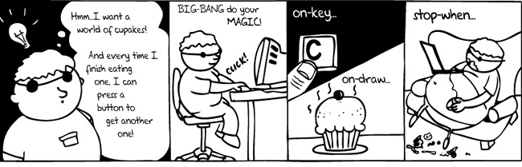

## 5.4 Guessing Gooey

Let’s write a GUI version of our Guess My Number game. It should display the program’s guesses and respond to the player’s key presses. We want the player to be able to press the up and down arrow keys to instruct the program. He will use the “ ↑” key if the program’s guess should be higher and the “↓” key if the number should be lower. If his number has been guessed, he can press “=” to terminate the game. The player can also press “q” to quit the game at any point. Throughout the game, we would also like to display the playing instructions on the scene. Overall, the game console will look something like this:

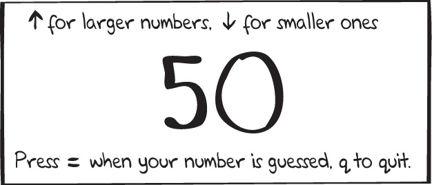

### The Data

As with all the games in this book, it is important to clearly identify and interpret the data we use to represent the states of the world before we start coding. A well-chosen data representation makes all the difference, because it almost always dictates how the code will be organized.

Since we need to keep track of the lower and upper bounds in this game, we’ll create a structure with two fields, called `small` and `big`:

```
(struct interval (small big))
```

We use the word “interval” for this structure because the number we are guessing must be in the interval. We also define a number of constants, as discussed in Chapter 4½:

```
(define HELP-TEXT
  (text "↑ for larger numbers, ↓ for smaller ones"
        TEXT-SIZE
        "blue"))
(define HELP-TEXT2
  (text "Press = when your number is guessed; q to quit."
        TEXT-SIZE
        "blue"))
(define COLOR "red")
```

The constants `HELP-TEXT` and `HELP-TEXT2` are the instructions for the game, and the sizes of these texts are determined by `TEXT-SIZE`. Note that `text` translates the instruction strings into images. The size of the game window is defined by `WIDTH` and `HEIGHT`. For the definitions of `WIDTH` and `HEIGHT`, see the code that comes with this chapter. The constant `COLOR` determines the display color.

Finally, we’ll define a background scene as a constant:

```
(define MT-SC
  (place-image/align
   HELP-TEXT TEXT-X TEXT-UPPER-Y "left" "top"
   (place-image/align
    HELP-TEXT2 TEXT-X TEXT-LOWER-Y "left" "bottom"
    (empty-scene WIDTH HEIGHT))))
```

We use `place-image/align` to place and align the images created with `HELP-TEXT` and `HELP-TEXT2` on top of an empty scene. The image `HELP-TEXT2` will be aligned along the bottom left of the screen, and `HELP-TEXT` will be aligned along the top left of the screen.

### The Main Function

To explain the code, we start with the main function:

```
(define (start lower upper)
  (big-bang (interval lower upper)
            (on-key deal-with-guess)
            (to-draw render)
            (stop-when single? render-last-scene)))
```

As with our text-based version of Guess My Number, we let the player supply the lower and upper limits of the guesses. The initial world is created with these arguments. When the player presses a key, `big-bang` calls `deal-with-guess` to create a new state of the world if necessary. Furthermore, we use the handler function `render` to draw the state of the game. If the program guesses the player’s number, `single?` returns `#t` and `render-last-scene` produces the last scene of the game. That’s all—except for an explanation of how these functions work.

### Key-Events

The key-handler for `on-key` takes in a world and a key-event. It then returns a new world or the world that it has been given, depending on which key has been pressed:

```
(define (deal-with-guess w key)
  (cond [(key=? key "up") (bigger w)]
        [(key=? key "down") (smaller w)]
        [(key=? key "q") (stop-with w)]
        [(key=? key "=") (stop-with w)]
        [else w]))
```

All key-events are strings, but not all strings are key-events, so we use `key=?` instead of `string=?` for comparisons. This function is provided by `2htdp/universe` and checks for equality between keys. We need the program to increase its guess when the player presses the “ ↑” key, represented by `"up"`, so we send the input world to our `bigger` function. Conversely, when the player presses the “↓” key, represented by `"down"`, we send the world to the function `smaller` so that a smaller number can be guessed. When the guess is correct, the player may press “`=`” or “`q`” to end the game.

You might be wondering what the `stop-with` function is all about. This function consumes a world state and creates a special kind of world state. When `big-bang` receives this special state, `big-bang` stops running. If an optional rendering function is present in a `stop-when` spec, `big-bang` will use this function to render the world given to `stop-with`. Otherwise, it uses the normal rendering function that we gave `on-draw` to render the last scene.

Our `smaller` and `bigger` functions are almost exactly the same as those of the text-based version, but instead of using `set!` to change the lower or upper bounds of the guesses, we have them create new `interval` structures:

```
(define (smaller w)
  (interval (interval-small w)
            (max (interval-small w) (sub1 (guess w)))))

(define (bigger w)
  (interval (min (interval-big w) (add1 (guess w)))
            (interval-big w)))
```

The `guess` function is also similar to that of the previous version of the game, except it now consumes the state of the world and uses its fields to calculate the next guess:

```
(define (guess w)
  (quotient (+ (interval-small w) (interval-big w)) 2))
```

So our `guess` function picks out the values in the `small` and `big` fields of the world state it has been given. It then adds them up and divides the sum by `2` to get the average of the lower and upper bounds.

### Rendering

Now let’s define the handler function for the `to-draw` clause, which draws a scene every time `big-bang`’s world is updated:

```
(define (render w)
  (overlay (text (number->string (guess w)) SIZE COLOR) MT-SC))
```

The `render` function places the program’s guess onto the background scene. In this case, we have `overlay`ed an image of the program’s guess in its predefined size and color onto `MT-SC`, which is the background scene that includes instructions on how to play.

We also want to render a scene when the game has ended:

```
(define (render-last-scene w)
  (overlay (text "End" SIZE COLOR) MT-SC))
```

This rendering function will simply display the text “End” onto the background scene using `overlay`.

### Time to Stop

Finally, the program needs to know when to stop the game. Logically, the player’s number has been guessed when the lower and upper bounds are equal:

```
(define (single? w)
  (= (interval-small w) (interval-big w)))
```

The `single?` function compares the two bounds of the world. If they are equal, the game is over.

And that’s all there is to it. Now you have your first interactive graphical program. As you can see, upgrading the Guess My Number game from a text-based version to a graphical one is really not that complicated. The `big-bang` library is a powerful tool, and it comes with many other exciting features that we have yet to discuss.

### Note

#|

If you don’t like how the game ends when the software has guessed your number, feel free to change the program. You may wish to change the render function. Or you may wish to change what we call states of the world. Or you may change both. Go ahead and experiment!

|#

## `Exit`—Chapter Checkpoint

In this chapter, we described how to create animations and games:

- The `2htdp/image` library is for creating graphics.
- In Racket, graphical shapes are values just like numbers in other languages.
- You can use `big-bang` from the `2htdp/universe` to create animations and games.
- Tick handlers are functions that step a world from one moment to the next.
- Key-event handlers compute new worlds in response to keyboard events.

## Chapter Challenges

- **Easy**. Find an image of a locomotive. Create an animation that runs the locomotive from just past the left margin to just past the right margin of the screen. Next, modify your program so the locomotive wraps around to the left side of the screen after passing the right margin.
- **Medium**. Change the Guess My Number game so that it displays the number of guesses the program takes to find the player’s number. Hint: you might need to change the data used to represent the world’s state.
- **Difficult**. Add a feature to the UFO animation so that you can control the UFO using direction keys. Once you’ve done this, make the UFO leave a trail of gray circles when it moves so that it looks like smoke is coming out of it.

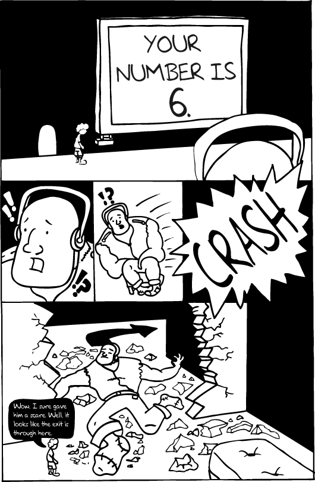

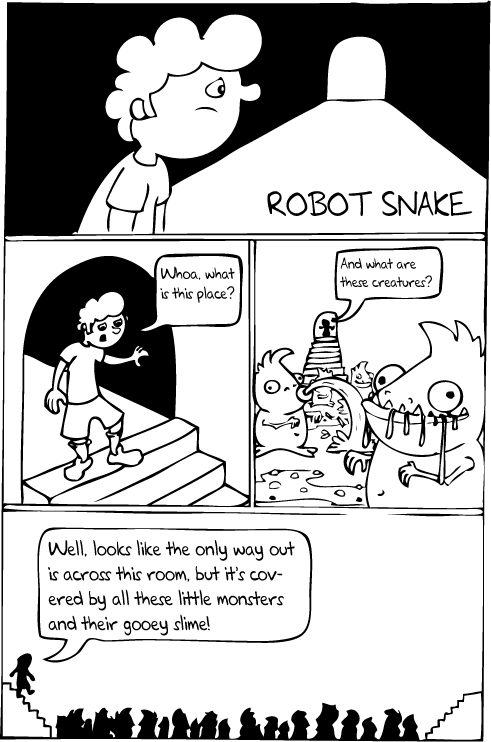

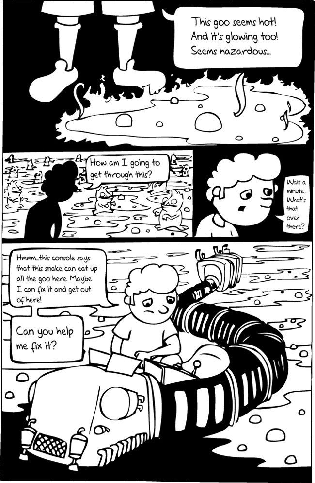

## Chapter 6. (Recursion Is Easy)

#|

You’ve seen lists, you’ve seen very basic recursion, and you know how to use big-bang to create a simple game. You are probably wondering when we get to make an interesting game. The answer is right now. In this chapter, we will use lists and leverage the full power of recursion to make the classic Snake game.

|#

## 6.1 Robot Snake

Walking along a dark corridor, Chad suddenly finds himself in a deep pit among DrRacket’s mischievous minions. The crazy critters are out of control and have scattered radioactive goo all over the place. He sees a tunnel on the other side of the pit and considers jumping over the dangerous, glowing puddles—but there are too many! Chad then stumbles across a jittering, broken robotic snake. Upon closer inspection, he finds a panel on the snake that houses its instruction manual. As it turns out, the snake is designed to dispose of radioactive goo by gobbling it up. As the snake eats more goo, it becomes larger. Chad looks at the snake again. Its segments are falling apart and its wiring is haphazard. He guesses that as long as the snake does not bump into the walls or itself, it will work just fine. Can you help Chad operate the snake?

In this chapter, we turn Chad’s encounter into an interactive game. The player uses the arrow keys to control a snake, which is placed in a rectangular pit. Appearing and disappearing goo items are scattered all around the pit, and it’s up to the snake to devour them. When the snake eats a piece of goo, though, a new one appears at a random position in the pit. In order for the snake to eat, its head must be over a piece of goo.

## 6.2 A Data Representation for the Snake Game

Let’s begin by considering how we will represent elements of the game as data. In the previous chapter, we used structures to represent our world, and we will do the same here:

```
(struct pit (snake goos))
```

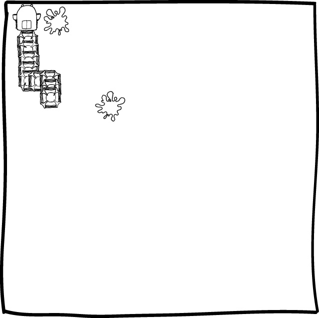

This structure definition helps us represent the state of the world as a `pit` structure with two fields. The first field, `snake`, keeps track of the current state of the snake. The second field, `goos`, tells us about the pieces of goo in the snake pit.

Our representation choice for the snake pit implies that we need a snake representation. Again, we use a struct:

```
(struct snake (dir segs))
```

The `snake` structure has two fields: `dir`, which is the direction in which the snake is slithering, and `segs`, which is a list of segments. A direction is one of the following strings: “`up`”, “`down`”, “`left`”, or “`right`”. These correspond to the four arrow keys on your keyboard. We think of segments as a non-empty list of `posn`s. The list can never be empty because, at the very least, the snake must have a head. As the game progresses and the snake eats more, this list will grow.

A `posn` is simply a point in two-dimensional space:

```
(struct posn (x y))
```

As in physics, we think about any object—snake segments or goos—as a point in the plane. With this representation, a check for collisions becomes especially easy. Objects collide when they both occupy the same point. We do pay a price for this simplicity, however. In particular, the segments of a snake cannot be arbitrary `posn`s. Two neighboring segments may differ in at most one direction, not both, and the difference must be 1. Fortunately, the game creates snakes so that this is always true.

We also need the data representation for goo:

```
(struct goo (loc expire))
```

The `loc` field contains a `posn` representing the `goo`’s location. The `expire` field represents the number of clock ticks left before this `goo` expires.

Now we have introduced all of the `struct`s needed to represent a world, and we can experiment with some simple worlds. Here is one:

```
> (define snake-example
    (snake "up" (list (posn 1 1) (posn 1 2) (posn 1 3))))
> (define goo-example
    (list  (goo (posn 1 0) 3) (goo (posn 5 8) 15)))
> (define pit-example
    (pit snake-example goo-example))
> pit-example
(pit
 (snake
  "up"
  (list (posn 1 1) (posn 1 2) (posn 1 3)))
 (list
  (goo (posn 1 0) 3)
  (goo (posn 5 8) 15)))
```

As you can see, we built the world in three steps. The first definition introduces a `snake` with three segments. The second one creates a list of two `goo`s. And the third one combines these two in a `pit`.

## 6.3 The Main Function

Once you have figured out the data representations, the next task is to write the main function. Its purpose is to set up the initial game scenario and establish the event handlers. The goal of writing this function is to associate actions in the game with computer interaction modes.

For the Snake game, `start-snake` uses `big-bang` to set up and launch the game:

```
(define (start-snake)
  (big-bang (pit (snake "right" (list (posn 1 1)))
                 (list (fresh-goo)
                       (fresh-goo)
                       (fresh-goo)
                       (fresh-goo)
                       (fresh-goo)
                       (fresh-goo)))
            (on-tick next-pit TICK-RATE)
            (on-key direct-snake)
            (to-draw render-pit)
            (stop-when dead? render-end)))
```

The `big-bang` expression in this function consists of five parts. The first is the initial world, a snake pit. One important part is the `to-draw` clause. As implied by the name, `render-pit` renders the current world so that the player can see where the snake is and how to find the goo. The `on-tick` clause tells DrRacket to call `next-pit` every time the clock ticks. This function handles a number of actions: removing expired goo, checking if the snake can eat and grow, and making the snake slither. We also need a way to control the direction that the snake is moving in, so we hand `big-bang` the `direct-snake` function in the `on-key` spec. Finally, the game must stop when the snake dies, meaning we should supply a `stop-when` spec.

## 6.4 Clock Ticks

We could start anywhere with our discussion, but clock ticks mean action, and action is fun. The `on-tick` clause in `start-snake` tells DrRacket to call the `next-pit` function on every clock tick:

```
(define (next-pit w)
  (define snake (pit-snake w))
  (define goos (pit-goos w))
  (define goo-to-eat (can-eat snake goos))
  (if goo-to-eat
      (pit (grow snake) (age-goo (eat goos goo-to-eat)))
      (pit (slither snake) (age-goo goos))))
```

Like all clock tick handlers, this function consumes and produces a world. In this case, the function handles snake pits: making the snake longer when it has eaten, moving the snake, and handling the aging and renewing of `goo`.

The actual work proceeds in two steps. First, the internal definition `goo-to-eat` uses `can-eat` on the world’s `snake` and the world’s list of `goo`. This function returns `#f` or a `goo` within reach of the snake’s head. Second, if `goo-to-eat` produces a `goo`, then the `snake` eats the nearby `goo` and grows, and the `goo` ages. Otherwise, the `snake` slithers and the `goo` ages.

Also note the first two local definitions. They extract the pieces from the given structure. Doing so is common because it makes it easier to read the rest of the function.

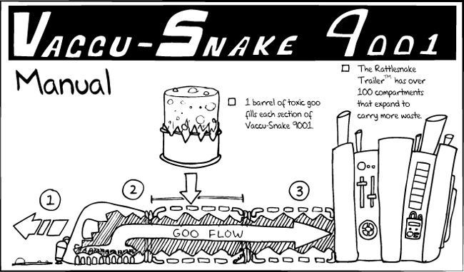

### Eating and Growing

In order for us to determine when the `snake` needs to grow, we need to know when it can eat. We define the function `can-eat` to determine if there is a nearby `goo` that the `snake`’s head can grab. If so, the function produces the piece that is to be eaten:

```
(define (can-eat snake goos)
  (cond [(empty? goos) #f]
        [else (if (close? (snake-head snake) (first goos))
                  (first goos)
                  (can-eat snake (rest goos)))]))
```

This function takes a `snake` and a list of `goo`. It then acts as a list-eater of the latter and determines if the `snake`’s head, which is the first segment in its list of segments, is close to any of the `goo` items in the list of `goo`.

Like all list-eating functions, `can-eat` checks if the list of `goo` is an empty list. If it is, then the `snake` cannot eat because there is no `goo`. Otherwise, there is at least one `goo` in the list, so we use `close?` to ask if the head is close to the first `goo`. If it is, we’ve found a `goo` to eat, so we return it. If it isn’t, we continue searching by recurring on the rest of the `goo`s.

For the purposes of our simplistic game, the `close?` predicate just returns true when the given segment has the same location as the given `goo`:

```
(define (close? s g)
  (posn=? s (goo-loc g)))
```

But you can probably imagine how to change this definition for other interesting modes of play.

While we call `can-eat` a predicate, you should note that it doesn’t just return Boolean values. Like `member`, `can-eat` produces `#f` if the snake cannot eat any of the `goo`. And also like `member`, it produces a real value, namely, the `goo` that the snake can eat. The `next-pit` function exploits this fact when it calls `eat` to tell that function which specific `goo` is to be absorbed.

Next, `eat` removes the `goo` and replaces it with a new `goo` item:

```
(define (eat goos goo-to-eat)
  (cons (fresh-goo) (remove goo-to-eat goos)))
```

The `eat` function consumes a list of `goo` and a `goo-to-eat`. The assumption is that `goo-to-eat` is in the list, so we remove it and `cons` on a fresh `goo` to the front of the list.

All we need now is the function `grow`, which actually makes the snake longer:

```
(define (grow sn)
  (snake (snake-dir sn)
         (cons (next-head sn) (snake-segs sn))))
```

This function creates a new snake that is one segment longer than the given one. It does so by calling `next-head` on the snake and by consing the resulting new head to the existing snake. While this trick may surprise you, the head is really just a `posn` to the function, just like all the tail segments.

### Slithering

Our snake can eat and grow, so now we need to make it move when it is not eating. To do so, we create a new `snake` by adding a new head for the `snake` and removing the last element of the current `segs` list:

```
(define (slither sn)
  (snake (snake-dir sn)
         (cons (next-head sn) (all-but-last (snake-segs sn)))))
```

Like `grow`, the `slither` function calls the function `next-head` to move the head. But the end of the snake needs to advance as well, which we accomplish by consing on the new head and removing the last segment using `all-but-last`.

Here’s the `all-but-last` function, which returns the given list of segments without its last one:

```
(define (all-but-last segs)
  (cond [(empty? (rest segs)) empty]
        [else (cons (first segs) (all-but-last (rest segs)))]))
```

Unlike the other list-eating functions we have seen so far, the `all-but-last` function works only on non-empty lists, because the snake always has a head. If the rest of the list is empty, meaning that there is one element in the list, then it returns `empty`. Otherwise, the function uses `cons` on the first element of the given list and recurs by calling `all-but-last` on the rest. As you probably guessed, this call retrieves all but the last segment of the rest of the list.

Now it’s time to look at the often-used `next-head` function:

```
(define (next-head sn)
  (define head (snake-head sn))
  (define dir  (snake-dir sn))
  (cond [(string=? dir "up") (posn-move head 0 -1)]
        [(string=? dir "down") (posn-move head 0 1)]
        [(string=? dir "left") (posn-move head -1 0)]
        [(string=? dir "right") (posn-move head 1 0)]))
```

The `next-head` function contains two internal definitions: one for the snake’s head and one for the snake’s direction. We use a `cond` to create the new head. The function returns a new segment based on the given direction of the snake and where the head is currently located. It employs `posn-move` to determine the new location of the head:

```
(define (posn-move p dx dy)
  (posn (+ (posn-x p) dx)
        (+ (posn-y p) dy)))
```

This function takes a `posn` and two numbers: `dx` and `dy`. It adds `dx` to the `x` coordinate of the `posn` and adds `dy` to the `y` coordinate of the `posn`. It thus allows us to move a `posn` by a certain number of points along the *x*-axis and *y*-axis of a plane.

### Rotting Goo

Finally, we make the goo rot and replace expired goo with new goo. We start by defining `age-goo`, which appears in the `next-pit` function:

```
(define (age-goo goos)
  (rot (renew goos)))
```

The `age-goo` function consumes and produces a list of `goo`. Since its purpose is to rot each of the `goo`s and replace any totally rotten `goo`s with fresh ones, `age-goo` is defined as the composition of two helper functions: `rot` and `renew`. The `rot` function’s job is to decay each `goo`, so it just passes over the list, calling `decay` on each element:

```
(define (rot goos)
  (cond [(empty? goos) empty]
        [else (cons (decay (first goos)) (rot (rest goos)))]))
```

The `renew` function is a similar list-eater but uses `rotten?`:

```
(define (renew goos)
  (cond [(empty? goos) empty]
        [(rotten? (first goos))
         (cons (fresh-goo) (renew (rest goos)))]
        [else
         (cons (first goos) (renew (rest goos)))]))
```

Here’s `rotten?`, which is used to detect `goo` that should be replaced with fresh `goo`:

```
(define (rotten? g)
  (zero? (goo-expire g)))
```

We still need to create the `fresh-goo` function, which randomly creates new `goo` structures:

```
(define (fresh-goo)
  (goo (posn (add1 (random (sub1 SIZE)))
             (add1 (random (sub1 SIZE))))
       EXPIRATION-TIME))
```

### Note

#|

When we designed this game, we discussed the timing a lot. You may find a game with (add1 (random EXPIRATION-TIME)) more appealing. Why do we need add1 here?

|#

And that is all there is to handling clock ticks. Now we can turn our attention to other aspects of the game, such as player input and game-rendering functions.

## 6.5 Key-Events

As mentioned at the beginning of this chapter, the player will use the arrow keys to direct the snake. Let’s look at the `direct-snake` function that we saw in `start-snake`, because it deals with key-events:

```
(define (direct-snake w ke)
  (cond [(dir? ke) (world-change-dir w ke)]
        [else w]))
```

A key-handler such as this function takes two arguments: the current snake pit and a key-event. If that key-event is a direction, then we may want to change the direction of the snake in the pit; otherwise, we want to return the current world.

The `dir?` function checks whether the player has pressed an arrow key:

```
(define (dir? x)
  (or (key=? x "up")
      (key=? x "down")
      (key=? x "left")
      (key=? x "right")))
```

Next, we need a function that will change the direction of the snake in response to the player’s keystroke:

```
(define (world-change-dir w d)
  (define the-snake (pit-snake w))
  (cond [(and (opposite-dir? (snake-dir the-snake) d)
              ;; consists of the head and at least one segment
              (cons? (rest (snake-segs the-snake))))
         (stop-with w)]
        [else
         (pit (snake-change-dir the-snake d) (pit-goos w))]))
```

The function `world-change-dir` consumes two arguments: a snake pit and a direction. It extracts the snake from the pit and then checks whether the direction `d` is the opposite of the snake’s current direction. If this is true and the snake consists of more than just a head, the function returns the given world wrapped in `stop-with`. Remember that an instance of the `stop-with` struct tells `big-bang` to act as if the game has come to an end. And why does the function say so? Because a snake that flips its head runs into itself.

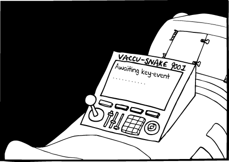

If the key-event `d` is acceptable or the snake consists of just a head, then it is time to create a new pit with a snake going in the chosen direction and the old goo. That’s the purpose of calling `snake-change-dir`. You can actually experiment with `world-change-dir` in the interactions panel. You start by building up a snake and then you include this snake in a simple world:

```
> (define snake-going-left (snake "left" (list (posn 2 18))))
> (define plain-world (pit snake-going-left empty))
```

Note that `plain-world` comes without `goo`s, but that is okay for experiments. And then you apply the function to this world and a key-event, which you can do because a key-event is just a string:

```
> (world-change-dir plain-world "right")
(pit (snake "right" (list (posn 2 18))) '())
```

While `plain-world` contains a snake that is going left, the resulting `pit` contains a snake going right, which is precisely what you want. Before you read on, you may wish to open the source of the game in DrRacket and make up an experiment with snakes that contain some additional segments.

In order to complete the `world-change-dir` function, we need to define the helper function, `opposite-dir?`:

```
(define (opposite-dir? d1 d2)
  (cond [(string=? d1 "up") (string=? d2 "down")]
        [(string=? d1 "down") (string=? d2 "up")]
        [(string=? d1 "left") (string=? d2 "right")]
        [(string=? d1 "right") (string=? d2 "left")]))
```

The `opposite-dir?` function compares two direction values to check whether they point in opposite directions.

## 6.6 Rendering

Recall that the representation of the pit assumes that all pieces of the game are single points. This is convenient and makes it trivial to check whether the snake can eat a piece of goo, whether the snake has run into itself, and a few other things.

In an image, a snake’s head takes up many pixels, and so does a radioactive piece of goo. To achieve this kind of scale-up, we create images of the same size for all basic pieces of the game: the snake head, `HEAD-IMG`; the snake segments, `SEG-IMG`; and the goo, `GOO-IMG`. Our rendering function then composes these images into a complete scene. This all works smoothly because every point in the representation is scaled up to the size of a basic image, and all basic images are of the same size.

Now consider the main rendering function that appears in the `big-bang` expression:

```
(define (render-pit w)
  (snake+scene (pit-snake w)
               (goo-list+scene (pit-goos w) MT-SCENE)))
```

The `render-pit` function calls two functions in order to render the game: `snake+scene` and `goo-list+scene`. Both functions operate exactly as implied by their names. The `snake+scene` function draws the snake into a given scene, and the `goo-list+scene` function draws the list of `goo` into the scene. And as you can see, it all starts with an empty scene. In order to make `render-pit` work, we need to define these functions.

We start with the `snake+scene` function:

```
(define (snake+scene snake scene)
  (define snake-body-scene
    (img-list+scene  (snake-body snake) SEG-IMG scene))
  (define dir (snake-dir snake))
  (img+scene (snake-head snake)
             (cond [(string=? "up" dir) HEAD-UP-IMG]
                   [(string=? "down" dir) HEAD-DOWN-IMG]
                   [(string=? "left" dir) HEAD-LEFT-IMG]
                   [(string=? "right" dir) HEAD-RIGHT-IMG])
             snake-body-scene))
```

The process to render the snake onto the given scene consists of three steps. First, `snake+scene` adds the body of the snake to the scene using the helper function `img-list+scene`. This function adds one `SEG-IMG` at each position of the body; if the list is empty, it returns the given scene. Second, the function extracts the snake’s direction. Finally, `snake+scene` adds the image of the snake’s head to the composite scene it has so far. The image used for the head is chosen based on the direction of the snake.

Now let’s look at the `img-list+scene` helper function. It takes a list of `posn`s, an image, and a `scene`:

```
(define (img-list+scene posns img scene)
  (cond [(empty? posns) scene]
        [else (img+scene
               (first posns)
               img
               (img-list+scene (rest posns) img scene))]))
```

As you can see, it is a standard list-eating function. It renders the given image at the positions specified by the given list of `posn`s on top of the given `scene`. If the list is empty, then the function returns the given `scene`. Otherwise, it calls `img+scene`, which draws the given image at the first `posn` onto the scene that we get by calling `img-list+scene` again on the rest of the list of `posn`s.

Here is the `img+scene` function:

```
(define (img+scene posn img scene)
  (place-image img
               (* (posn-x posn) SEG-SIZE)
               (* (posn-y posn) SEG-SIZE)
               scene))
```

All that is left to do as far as rendering is concerned is to draw the `goo`:

```
(define (goo-list+scene goos scene)
  (define (get-posns-from-goo goos)
    (cond [(empty? goos) empty]
          [else (cons (goo-loc (first goos))
                      (get-posns-from-goo (rest goos)))]))
  (img-list+scene (get-posns-from-goo goos) GOO-IMG scene))
```

Similar to the `snake+scene` function, `goo-list+scene` employs `img-list+scene` to render `goo`s. The only difference is that we pass different arguments to the `img-list+scene` function. Instead of using the `SEG-IMG` constant, we use `GOO-IMG` for the image of a piece of goo.

We do need to define the `get-posns-from-goo` function in order to obtain the `posn`s of each `goo` in the list of `goo`. Once again, this function uses the power of list recursion to create a list of `posn`s from the list of `goo` that we provide the function. If the list is empty, then the function returns `empty`. Otherwise, the function uses `goo-loc` to access the `loc` field of the first piece of `goo`. We then use `cons` to attach this value to the recursion on the rest of the list of `goo`.

## 6.7 End Game

Now that we have completed the functions that help us handle the player’s key input and render the game, we need to define some functions that determine when the game ends. There are two conditions that determine whether the game is over: the snake collides with either itself or the surrounding walls.

Let’s consider the `dead?` function that appears in the `start-snake` function:

```
(define (dead? w)
  (define snake (pit-snake w))
  (or (self-colliding? snake) (wall-colliding? snake)))
```

This function returns `#t` if the `snake` from the world has collided with a wall or has collided with itself. If either is the case, then the `stop-when` clause in `big-bang` will be triggered and the game will end.

We should also produce an image for the `stop-when` clause, so that it is obvious when the game is over:

```
(define (render-end w)
  (overlay (text "Game Over" ENDGAME-TEXT-SIZE "black")
           (render-snake-world w)))
```

The `render-end` function overlays an image of “Game Over” on the last scene of the game. If you can think of something better, modify the code.

Next we look at the functions that determine if the snake collides with itself or the wall. First, we define `self-colliding?`:

```
(define (self-colliding? snake)
  (cons? (member (snake-head snake) (snake-body snake))))
```

The `self-colliding?` function consumes a `snake` and calls the built-in function `member`, which will check whether the head of the `snake` is the same as one of the segments in the rest of the `snake`’s body. That’s all there is to it because segments are just points.

All that remains for checking collision is to check against the walls of the pit:

```
(define (wall-colliding? snake)
  (define x (posn-x (snake-head snake)))
  (define y (posn-y (snake-head snake)))
  (or (= 0 x) (= x SIZE)
      (= 0 y) (= y SIZE)))
```

We start `wall-colliding?` by defining the `x` and `y` positions of the `snake`’s head. Then, we check if its `x` or `y` coordinate is equal to any of the boundaries of the pit. If none of these four conditions is true, then the `snake` has not collided with the wall.

## 6.8 Auxiliary Functions

We are almost finished with the Snake game, but we need to define two helper functions that have been used in various parts of our code. First, we need the `posn=?` function, which determines whether two `posn`s have the same `x` field and the same `y` field:

```
(define (posn=? p1 p2)
  (and (= (posn-x p1) (posn-x p2))
       (= (posn-y p1) (posn-y p2))))
```

This function compares the fields of two `posn`s for equality. Yes, we could use `equal?` but you should know why we don’t.

Beyond this equality function, we need four functions that manipulate the snake:

```
(define (snake-head sn)
  (first (snake-segs sn)))

(define (snake-body sn)
  (rest (snake-segs sn)))

(define (snake-tail sn)
  (last (snake-segs sn)))

(define (snake-change-dir sn d)
  (snake d (snake-segs sn)))
```

If you had bought a serious book on programming, it would explain these functions in gory detail. But this is a cheap book, and you get what you pay for.

## `Return`—Chapter Checkpoint

In this chapter, we created the Snake game, which made heavy use of lists and recursive functions:

- We processed lists using a variety of list-eating functions.
- We gained a lot of experience with the `2htdp/image` library to visually render a game.

## Chapter Challenges

- **Easy**. Change the program so that the final image displays the number of pieces of goo that have been eaten.
- **Easy**. Alter the game so that it has a randomly varying number of goos.
- **Medium**. Add another type of goo that makes the snake grow two segments longer instead of one segment longer.
- **Medium**. Add obstacles to the game. If the snake touches the obstacles, the game is over.
- **Medium**. Once you have obstacles, make them move around at certain intervals.
- **Difficult**. Add a second snake that is controlled by the “w,” “a,” “s,” and “d” keys. You may want to look in the docs for `on-pad`, another kind of `big-bang` clause. Then find a friend to play against you.

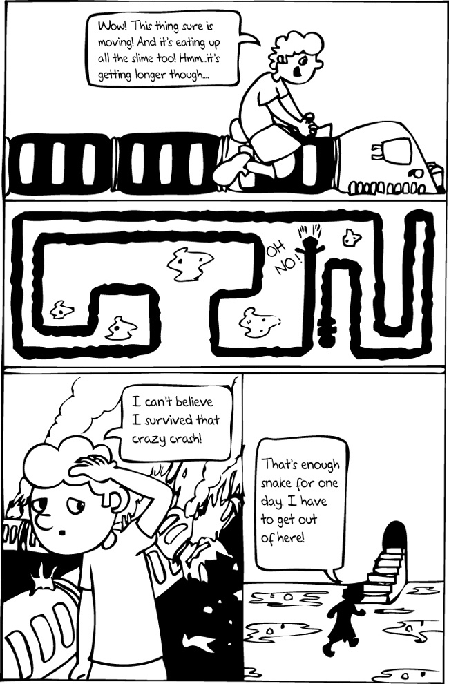

## Chapter 7. (Land of Lambda)

#|

Are you tired of writing the same kind of functions over and over again? Is the list empty? Do this. Is the list non-empty? Do that. Don’t forget to recur. In this chapter, we will show you how to abstract and use lambda, something you probably didn’t see in your introductory programming courses. Al—whom you surely remember from the introduction—invented it in the 1930s, and Lisp has had it for 50 years or more. This chapter is all about lambda and its tricks.

|#

## 7.1 Functions as Values

Before we can begin to work with `lambda`, we need to discuss one key concept about functions in Racket. Functions in Racket are values, just like numbers, strings, and images. Let’s look at an example:

```
> add1
#<procedure:add1>
```

When we enter `add1` into the interactions panel without applying it to anything, DrRacket replies with `#<procedure:add1>`. But how can this be useful? Well, since functions are treated as values, we can pass them into other functions as arguments. Indeed, we can also return a function from a function. A function that consumes or produces another function is called a **higher-order function**, and it can compute all kinds of nifty things.

Here is a simple example called `my-map`:

```
(define (my-map func lst)
  (cond [(empty? lst) empty]
        [else (cons (func (first lst))
                    (my-map func (rest lst)))]))
```

This function takes two arguments: a function of one argument, called `func`, and a list. It applies `func` to each element of the list and then collects the results in a list. Let’s see how we can apply this function:

```
> (my-map add1 '(1 2 3 4))
'(2 3 4 5)
```

In this example, we call `my-map` on the `add1` function and a list of numbers. The `add1` function is applied to each element of the list. As you can see from the output, each element of the original list increments by 1.

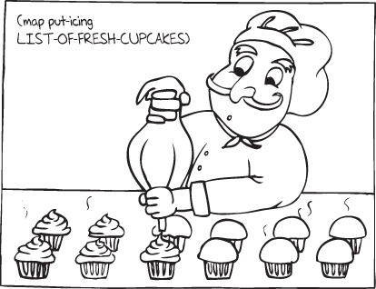

You may wonder how this could be useful. You shouldn’t be surprised to read that it could have been handy in writing the Snake game. Recall the internal definition of `get-posns-from-goo` in the `goo-list+scene` function:

```
(define (get-posns-from-goo goos)
  (cond [(empty? goos) empty]
        [else (cons (goo-loc (first goos))
                    (get-posns-from-goo (rest goos)))]))
```

Here is the same function written with `my-map`:

```
(define (get-posns-from-goo goos)
  (my-map goo-loc goos))
```

The second version is much shorter and clearer. It directly communicates that `get-posns-from-goo` calls `goo-loc` on each element in the list and that it returns a list of the locations of each `goo` item from the original list.

Let’s try another example:

```
(define (rot goos)
  (my-map decay goos))
```

This function is a rewriting of the `rot` function, but it uses `my-map` now. We call `my-map` using `decay` and `goos` to decrement the expiration date of each `goo`. This function performs the same task as the old version, but it relays the idea in a concise fashion.

## 7.2 Lambda

By now, you can appreciate functions as values, but you may find it a major hassle to create a named function that is used only once. This is where `lambda` comes in. With `lambda`, we can create nameless functions on the fly whenever we need them.

Let’s illustrate the idea with a third version of `rot`:

```
(define (rot goos)
  (my-map (lambda (f)
            (goo (goo-loc f) (sub1 (goo-expire f))))
          goos))
```

Here, we create a function with `lambda`. It takes in one piece of goo, called `f`, and returns a different piece of goo. It is the same function as `decay` from the previous example, but it has no name.

Let’s look at two ways to make the `sub2` function. The old way requires `define`:

```
> (define (sub2 num)
    (- num 2))
> (sub2 5)
3
```

The new way uses `lambda`:

```
> (lambda (num)(- num 2))
#<procedure>
```

When using `lambda`, we write a number of parameters in parentheses, just as with a regular function definition, which will stand for the arguments of the function we create. We then add the body of the function and close it off with a parenthesis. That is all it takes to create a function with `lambda`, but as is, the function doesn’t do anything. To get a function to compute, you need to apply it:

```
> ((lambda (num) (- num 2)) 5)
3
```

In this case, we apply the function to `5` and it returns `3`.

## 7.3 Higher-Order Fun

Now that we have seen `lambda` and `my-map`, let’s look at some other higher-order functions. We will start by defining a function called `my-filter`:

```
(define (my-filter pred lst)
  (cond [(empty? lst) empty]
        [(pred (first lst))
         (cons (first lst) (my-filter (rest lst)))]
        [else (my-filter (rest lst))]))
```

The `my-filter` function is applied to a predicate and a list. In turn, it applies the given predicate to every element in the list. If the result is true, then `my-filter` keeps the value in the list. Otherwise, the value is removed from the list. Essentially, it will appear as though the function has filtered out the elements that we do not want, according to the predicate.

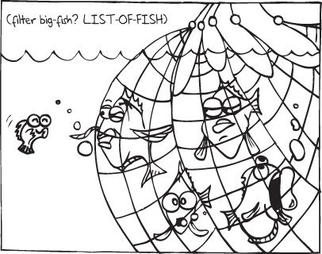

Let’s look at another example from the Snake game:

```
(define (renew goos)
  (my-filter (lambda (f) (not (rotten? f))) goos))
```

The `renew` function has to remove any goo that has expired. Here, we use `my-filter` to accomplish the task. We create a `lambda` function that applies `not` to the call to the `rotten?` function on a piece of goo `f`. This predicate returns true if the goo is not rotten. In other words, we use `my-filter` to keep all of the goo that is not rotten. While this revised version of `renew` is not quite the original, it demonstrates nicely how `my-filter` works and how easy it is to use.

Another pair of higher-order functions plays an important role in Racket, and they use predicates too: `my-andmap` and `my-ormap`. We start with `my-ormap`:

```
(define (my-ormap pred lst)
  (cond [(empty? lst) #f]
        [else (or (pred (first lst))
                  (my-ormap pred (rest lst)))]))
```

The idea behind `my-ormap` is to determine whether any of the elements in the list return true when the predicate is applied to them. If the list is empty, then nothing in the list can match the criteria, so `ormap` returns `#f`. Otherwise, `ormap` applies the predicate to the first element in `lst` and uses `or` on it and the recursion of `my-ormap`. If any element of the list returns true, the function will return this result.

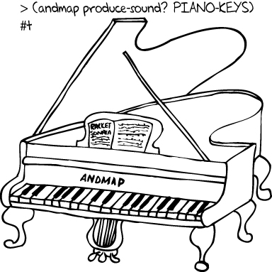

The `my-andmap` function is similar, but it checks if all of the elements in the list return true when the predicate is applied:

```
(define (my-andmap pred lst)
  (cond [(empty? lst) #t]
        [else (and (pred (first lst))
                   (my-andmap pred (rest lst)))]))
```

This function differs from `my-ormap` in two ways. First, if the list is empty, then the function returns `#t`. Second, instead of combining the recursion and analysis of the first element with `or`, the function uses `and`.

Now that we have seen these two functions, let’s see how they work:

```
> (my-andmap number? empty)
#t
> (my-ormap number? empty)
#f
```

Here, we apply `my-andmap` and `my-ormap` to the `number?` function. For `my-andmap`, this case always returns `#t`. The other function, `my-ormap`, returns `#f` in this case. The next two examples provide more insight:

```
> (my-andmap number? '(1 2 3 "a"))
#f
> (my-ormap number? '(1 2 3 "a"))
#t
```

The first example calls `my-andmap` on `number?` and a list. This means that if *all* the elements in the list are numbers, then the function returns `#t`. As not all of the elements are numbers, the function returns `#f`. The second example checks whether *any* of the elements in the list are numbers. If one is a number, then the function returns `#t`. Since there are numbers in this list, the function returns `#t`.

[figure not shown]

Let’s look at one last example of `my-ormap` that shows how `my-ormap` would have been helpful in the Snake game:

```
(define (can-eat snake goos)
  (define head (snake-head snake))
  (my-ormap (lambda (g) (and (close? head g) g)) goos))
```

Here, we redefine the `can-eat` function to use `my-ormap`. We first extract the snake’s head and give it a local name. Then we create a `lambda` function that takes in a `goo` structure and returns it if the snake’s head is close. Finally, we use `my-ormap` to apply this function to every piece of goo on `goos`. And that is all we need to check whether the snake can eat any of the pieces of goo.

Another higher-order function that would be helpful in writing Snake is `my-foldr`:

```
(define (my-foldr f base lst)
  (cond [(empty? lst) base]
        [else (f (first lst) (my-foldr f base (rest lst)))]))
```

The `my-foldr` function takes three arguments: a function of two arguments, a base value, and a list. It returns `base` if the given list is empty. Otherwise, the given function is used to combine the first element of the list and the recursion on the rest of the list.

The `my-foldr` function can be especially useful for combining all of the elements of a list into a single result.

[output not shown]

In the first example of `my-foldr`, we use the `+` function on a list of numbers and a base value of `0`. This function adds all of the numbers in the list together. The second function folds the list of images into a single image by aligning them horizontally with `beside`. Guess what would happen if we used `above` instead?

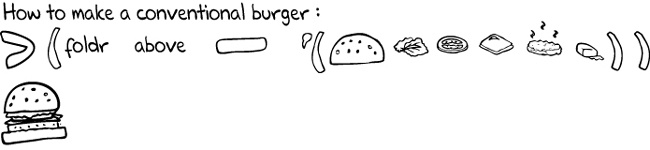

And it should not come as a surprise that `my-foldr` would have come in handy with the Snake game:

```
(define (img-list+scene posns img scene)
  (my-foldr (lambda (p s) (img+scene p img s)) scene posns))
```

Here, we redefine the `img-list+scene` function to use `my-foldr`. We create a `lambda` function that takes in a `posn` and a `scene`. It calls `img+scene` to create the image. Because we are using `my-foldr`, the `lambda` function is called on all of the `posn`s in the list. The function creates one scene out of the list of `posn`s.

By now, you may have figured out that all these higher-order functions are built into Racket. They are called `map`, `filter`, `ormap`, `andmap`, and `foldr`. Their definitions are pretty much the way we defined them here, and you can use them freely.

## 7.4 Two More Higher-Order Functions

There are more higher-order functions worth mentioning. One is `foldl`. The difference between `foldl` and `foldr` is the last letter. In case you didn’t guess, `l` stands for left-to-right, and `r` means the opposite.

```
(define (my-foldl f base lst)
  (cond [(empty? lst) base]
        [else (my-foldl f (f (first lst) base) (rest lst))]))
```

Put differently, `foldl` works in a similar fashion to `foldr` in that it also combines all the elements of a list. However, when `my-foldl` recurs, it starts by applying the function to the first element of the list and the base value. It passes this new value along and uses it as the new base value. Once the list is empty, it returns the accumulated value.

Let’s look at some examples of `my-foldl`:

```
> (my-foldl cons empty '(a b c))
'(c b a)
> (my-foldr cons empty '(a b c))
'(a b c)
> (my-foldl + 0 '(1 2 3))
6
```

The first example shows that the order of processing is different from that of `my-foldr`. The outcome is the reverse of the given list. The second interaction shows that `my-foldr` proceeds in the opposite order. The last example shows that `my-foldl` can also combine lists like `my-foldr`. If we replaced the `my-foldl` call with `my-foldr` here, we would get the same result because in Racket it doesn’t matter in which order you add up integers and rationals. Again, Racket’s name for `my-foldl` is `foldl`.

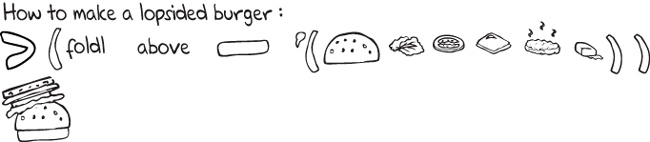

The second function we need to look at is `my-build-list`. This function takes in a natural number `n` and a function `f`. It builds a list that has a length equal to `n`. The elements of the list are created by `f`:

```
(define (my-build-list n f)
  (define (builder k)
    (cond [(= n k) empty]
          [else (cons (f k) (builder (add1 k)))]))
  (builder 0))
```

In order to define this function, we start with an internal function `builder`, which also consumes a natural number. If the number given to `builder` is equal to the natural number given to `my-build-list`, then the function returns `empty`. Otherwise, it applies the given function to `k` and uses `cons` to attach the result to the recursion on the `builder` function. After we define `builder`, we call it with `0` so that we can recur up to the given natural number.

Let’s look at two examples of `my-build-list`:

```
> (my-build-list 5 add1)
'(1 2 3 4 5)
> (my-build-list 10 (lambda (n) (* n 2)))
'(0 2 4 6 8 10 12 14 16 18)
```

The first uses the `add1` function. In this instance, `my-build-list` builds a list of length five and its elements are the numbers `1` through `5`. Instead of using `my-build-list` in all of your programs, you can use the `build-list` function in Racket.

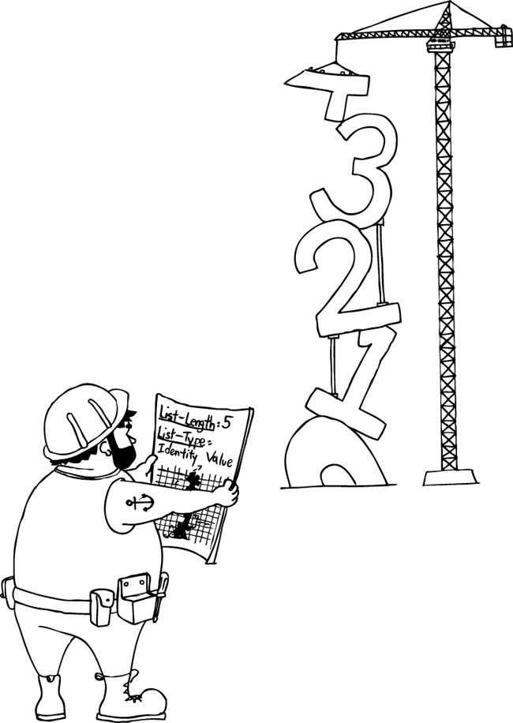

## 7.5 Derive This!

Before we close the chapter, let’s take a second look at `lambda`. We will show you how to write a function that computes the derivative of some given function. If you haven’t taken calculus, you might want to look on the Web for the basic concept of a derivative. The idea is that the derivative of a function `f` computes the approximate slopes of `f`.

It turns out that in Racket you can write a function that computes the derivative of another function:

```
(define (d/dx fun)
  (define ∂ (/ 1 100000))
  (lambda (x)
    (/ (- (fun (+ x ∂)) (fun (- x ∂))) 2 ∂)))
```

The derivative function starts off with an internal definition of the `∂` constant, which we will need for estimating the slope of the function at a given point. We then use `lambda` to create a function. Since we are working in a one-dimensional space right now, we need only one input for our function, but we can, in principle, deal with multi-dimensional math as well. Here, we just use the approximate slope of a line as the change in *y* over the change in *x*:

```
(f(x+∂)-f(x-∂))/(2*∂)
```

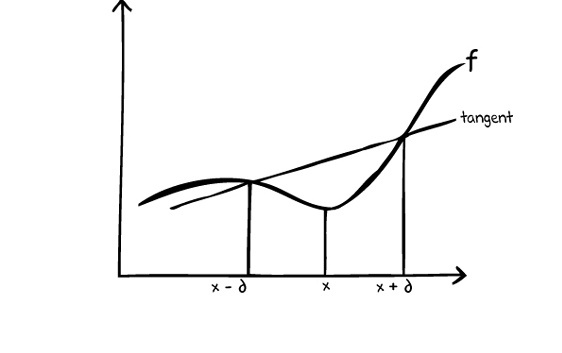

So we can see that our `d/dx` function takes in a function and outputs a function.

Finally, we can test our function by taking the derivative of functions that have simple derivatives:

[output not shown]

## 7.6 apply

There is one last higher-order function to discuss before we return to making games. The function is called `apply`, and it allows for some interesting tricks. The `apply` function takes a function and a list and applies the given procedure to the elements of the list:

```
> (define (sum lon) (apply + lon))
> (sum '(1 2 3 4 5 6))
21
```

This gives you the sum of a list of numbers.

Similarly, we can use `apply` to determine the maximum value in a list:

```
> (define (highest lon) (apply max lon))
> (highest '(58 64 77 77 22 94 93 78))
94
```

The function `highest` takes a list of numbers and uses `apply` to determine the largest one. We give `apply` the function `max`, which compares two numbers and returns the larger one.

The `apply` function does not work only on numbers. We can use it to manipulate other types of data, such as images:

```
(define (row lop) (apply beside (map frame lop)))
```

This function takes in a list of images and produces one image. It starts by using `map` to place a frame around each image with the `frame` function. It then calls `apply` with the `beside` function. Recall that the `beside` function comes with `2htdp/image` and that it places all of the images beside each other.

## `Break`—Chapter Checkpoint

In this chapter, we showed you that Racket programmers can abstract over list-eating functions, and we discussed how `lambda` makes this easy:

- Functions are values, just like numbers, strings, images, and any of the other kinds of values we’ve seen so far.
- You can write functions that abbreviate a lot of processing, and Racket provides a bunch: `andmap`, `apply`, `build-list`, `filter`, `foldl`, `foldr`, `map`, and `ormap`. It is as if you could write your own looping constructs in C# or Java.
- We saw that `lambda` is good for making simple functions; `lambda` is also good for creating some not-so-simple functions. You will see more of `lambda` soon.

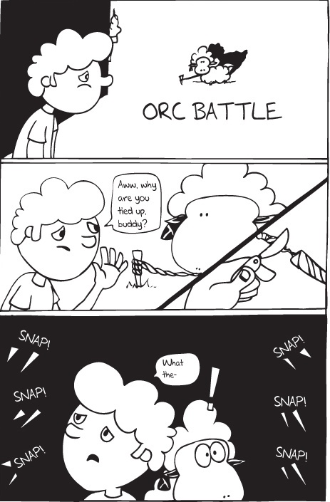

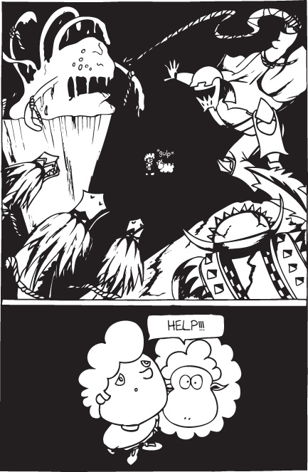

## Chapter 8. (Mutant Structs)

#|

At this point, you’ve seen structures and lists. You’ve learned how to write list-processing functions, and you know you can do so concisely. In this chapter, we’ll put that knowledge to good use when we write the Orc Battle game. In the process, we’ll show you a convenient way of dealing with changes to structures.

|#

## 8.1 Chad’s First Battle

Chad has managed to find himself stuck in an underground coliseum. All around him are monsters, ready for battle. Grabbing a sword, a shield, and some armor, he braces himself for the onslaught. For Chad to have any hope of escaping from his impending doom, you must help him defend himself.

Naturally, it’s all just a game, and to us, it’s all just software. But the Orc Battle is a good training ground to reinforce your list-processing skills and to add a few new ones concerning structs.

## 8.2 Orc Battle

Orc Battle is a basic turn-based fighting game in which the player fends off some ravenous monsters. The player starts with a certain amount of health, strength, and agility. When the surviving monsters have their turn, they attack the player, damage her health, weaken her strength, or reduce her agility. When it is the player’s turn, she gets some number of attacks and must try to kill as many monsters as possible; the only good monster is a dead monster.

Agility determines the number of attacks the player can perform. The player can attack in two different ways: stab a specific monster or flail, hitting several monsters at the same time. The effectiveness of each kind of attack depends on the player’s strength. As the player’s health dwindles, she can trade an attack for a healing action. While a single healing action doesn’t restore her health, it will extend her life somewhat.

[figure not shown]

[figure not shown]

Monsters come in several flavors, yet they all have properties in common. Like the player, every monster has a health status, which determines whether it is alive and the effectiveness of its attack. Each monster, however, attacks the player in its own special way. Orcs, the title characters, hit the player with their clubs. Hydras slice the player, but the ferocity of their attack depends on their health. The slime creature is poisonous. Its attacks slow down the player, meaning they reduce the player’s agility, and it is intent on inflicting some damage to her health. Finally, the brigand is the brains of the horde. It damages the player in random, spur-of-the-moment ways. Depending on its mood, it may inflict damage to the player’s health, decrease her agility, or weaken her strength.

In this chapter, we will show you how to create such a game in Racket. But that’s not all. The real purpose of this chapter is to deepen your understanding of how to program with lists that contain structs, which already contain lists. And that will expand your knowledge of structs.

## 8.3 Setting Up the World, a First Step

As always, we start with a data structure that represents the world. The Orc game needs a world with several “moving” parts: a player, who has several changing attributes; a bunch of monsters, which have some common attributes (e.g., their health) and some unique ones; and at least one turn-specific attribute, namely how many attacks the player has left during the current turn.

All of this suggests that we should keep track of the orc world in a three-field struct:

```
(struct orc-world (player lom attack#))
```

The `player` field describes the player’s attributes. The second field is a list of monsters. And the third field counts how many attacks the player may execute.

Next, we should figure out a representation for the player. The player has three changing attributes, so another struct with three fields looks like a good first step:

```
(struct player (health agility strength))
```

Each of the three fields will contain a natural number, such as `0`, `1`, `2`, and so on. Here are some constants that describe the range of numbers you might find in a `player` struct:

```
(define MAX-HEALTH 35)
(define MAX-AGILITY 35)
(define MAX-STRENGTH 35)
```

Do you know what this means? As always, we encourage you to open the code in the IDE and experiment. There you will find many more constant definitions, and we hope that all their names explain their meaning as clearly as the three preceding definitions.

You know what lists are, and you should be able to imagine a list of monsters. But what are monsters? Given what we have shown you so far, you could define four struct definitions for the four kinds of monsters:

```
(struct orc (health club))
(struct hydra (health))
(struct slime (health sliminess))
(struct brigand (health))
```

All monsters have one property in common: `health`. Orcs also carry clubs, which come in different strengths; that explains the `club` field in the `orc` struct. The `sliminess` field in the `slime` struct is similar.

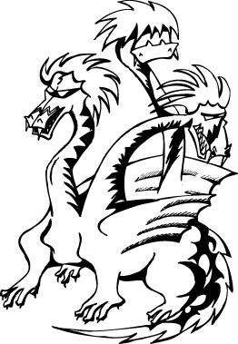

Now let’s make a list of monsters:

```
> (list (orc MONSTER-HEALTH0 (add1 (random CLUB-STRENGTH))))
(list (orc 9 3))
```

This is a boring list with just one monster, but it is a list. You could even make an `orc-world` with this list:

```
> (orc-world
    (player MAX-HEALTH MAX-AGILITY MAX-STRENGTH)
    (list (orc MONSTER-HEALTH0 (add1 (random CLUB-STRENGTH))))
    0)
(orc-world (player 35 35 35) (list (orc 9 6)) 0)
```

This world has a player at maximal health, agility, and strength; it contains a list with a single monster; and it says the player has no attacks left. Surely, you can make complex worlds this way, but we find the struct definitions for monsters annoying, and you should, too.

To begin with, they don’t say that these four structs describe a monster. Also, they don’t say that all monsters have a common `health` field. That’s fixable, and the fix is one of the two ideas we want to introduce in this chapter.

The first idea is called **struct inheritance.** As it turns out, in Racket you can define a struct as the “child” of another struct. In the context of our game, we can therefore define a `monster` struct like this:

```
(struct monster (health))
```

It says that all `monsters` have a `health` field that tells us how healthy a monster is. Next, you can say that all the monsters are like `monster`:

```
(struct orc monster (club))
(struct hydra monster ())
(struct slime monster (sliminess))
(struct brigand monster ())
```

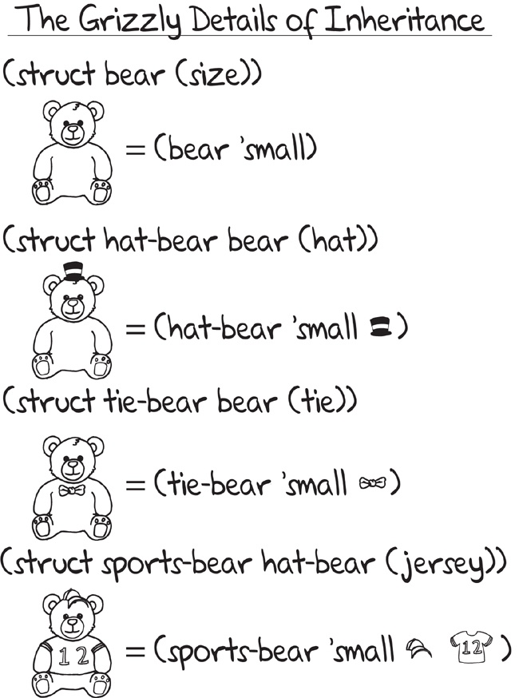

And this means that `orc`, `hydra`, `slime`, and `brigand` structs are like `monster` structs. They have a `health` field, and two of them have additional fields. So when you create an orc, keep in mind that it still has two fields:

```
> (orc MONSTER-HEALTH0 (add1 (random CLUB-STRENGTH)))
(orc 9 4)
```

If your functions ever need to select the `health` field from an `orc`, they do so with the `monster-health` function:

```
> (define my-orc (orc MONSTER-HEALTH0 2))
> (monster-health my-orc)
9
> (orc-club my-orc)
2
```

For the `club`, however, you will continue using `orc-club`. Okay? We will show you more examples as we build the game, and you can always practice with the code in DrRacket.

## 8.4 Action: How Structs Really Work

The second new idea in this chapter concerns what the player’s actions do to our data. We told you that the handler functions in `big-bang` take the state of the world and return a new one. But there are two distinct ways of getting a new state. We have seen the first one twice now. With this one, the handler functions create *new* states. So imagine you’re playing the game and you wish to stab an orc:

```
(define (stab-orc.v1 an-orc)
  (orc (- (monster-health an-orc) DAMAGE) (orc-club an-orc)))
```

Well, this function isn’t enough. Because the `orc` struct is somewhere in the middle of the list of monsters, you also need a function that goes through the list, changes the one monster, and re-creates the entire list of monsters. And that isn’t quite enough either because the list of monsters is inside the `orc-world` struct. You should be able to see what we are getting at. All of this can easily become a mess of code.

The second way to change a world avoids this extensive unzipping and zipping of lists and structs. Instead of creating new worlds, we *change* some part of the world or, as Lispers say, we **mutate** the struct. This alternative simplifies `stab-orc` a lot:

```
(define (stab-orc.v2 an-orc)
  (set-monster-health! an-orc (- (monster-health an-orc) DAMAGE)))
```

And `stab-orc.v2` is really all you need. In particular, you don’t need to destructure the list, create a new one, restructure the list, and do all of this to `orc-world`. Mutation eliminates all these computations.

To make this work, we need to say that the `health` field in an `orc` struct is mutable:

```
(struct monster ([health #:mutable]))
```

With this small addition, the struct definition gives you one more function: the `set-monster-health!` **mutator**. Its purpose is to change the value of the `orc`’s `health` field. With mutators, just one step lets every other function in the game know that something changed.

The monsters’ health isn’t the only attribute that changes over the course of the game. When it is the monsters’ turn, they can affect all three of the player’s attributes. Again, it is easiest to accommodate such changes by making the entire `player` struct mutable, like this:

```
(struct player (health agility strength) #:mutable)
```

By adding the `#:mutable` key to the struct definition, we ask Racket to supply one mutator for every field, giving us the `set-player-health!`, `set-player-agility!`, and `set-player-strength!` functions. Again, these mutators are created in addition to the constructor, the predicate, and the accessors.

Each of these mutators consumes an instance of the `player` struct and a value. It returns nothing and changes the value of a field. By the way, here is how you say “return nothing” in Racket:

```
> (void)
>
```

You see, `void` is a function that produces nothing, and this “nothing” isn’t even worth printing in the interactions panel.

Let’s experiment with `player` structures in DrRacket, and we will keep encouraging you to do so as well:

```
> (define player1 (player 1 2 3))
> (set-player-health! player1 33)
>
```

Nothing seems to have happened. The first line creates an instance of `player` called `player1`, and the second line seems to accomplish nothing. Did we say that these mutators return nothing? And did we also mention that instead they change their given struct?

```
> player1
(player 33 2 3)
```

Sure enough, `player1`’s `health` field is now `33`. Okay, take a look at these interactions:

```
> (define player2 (player 10 20 30))
> (set-player-health! player2 66)
> player2
(player 66 20 30)
> player1
(player 33 2 3)
```

We did it all over again. And just so you see that nothing but `player2` changes this time around, we also looked at `player1`.

Here are some more interactions:

```
> (define player3 player1)
> (set-player-agility! player3 666)
> player1
(player 33 666 3)
```

The first line gives the value of `player1` another name: `player3`. With the second line, we change `player3`, and this affects `player1`, too, as the last line shows. We can also do this when such structs are embedded in lists:

```
> (define players (list player1 player2 player3))
```

Here, we created a list of three players, though by now you can probably see that the first and the third players refer to the same struct. To test such a conjecture, use the `eq?` function:

```
> (eq? (first players) (third players))
#t
```

Recall from Chapter 4 the difference between `eq?` and `equal?`. If not, now would be a good time to reread that section.

Next, we set the second player’s `strength` field to a large number:

```
> (set-player-strength! (second players) 999)
> player2
(player 66 20 999)
> (second players)
(player 66 20 999)
```

And no matter how we refer to this player—by its name or by its position in some list—its strength is now `999`.

It’s time to use our new powers: mutators mixed with `lambda`. For every field, our game will need functions that add numbers to the player’s attributes. Here is the function definition for changing the health of a player:

```
(define (player-health+ player delta)
  (define nih (interval+ (player-health player) delta HEALTH))
  (set-player-health! player nih))
```

The function first computes the new internal health value, `nih`, using interval addition, `interval+`. This function adds two numbers but makes sure the sum is between `0` and `HEALTH`. If the result is larger than the desired maximum, `internal+` produces the maximum. If the result drops below `0`, the function produces `0`. In short, you can beat a dead horse, but it won’t get any deader.

In many languages, you would have to repeat this definition three times for `health`, `agility`, and `strength`. Racket, however, gives you more power. It gives you `lambda`. In this instance, we use `lambda` to abstract over the essence of the attribute manipulation and create as many of the concrete functions as you want:

```
(define (player-update! setter selector mx)
  (lambda (player delta)
    (setter player (interval+ (selector player) delta mx)))
```

This function consumes a `setter`, a `selector`, and an `mx`. It produces a nameless function using `lambda`, but boy, this nameless function can do a lot:

- It consumes a player and a number.
- It accesses the player’s old attribute value, with the help of `selector`.
- It computes a new attribute value limiting the interval with the given `mx`, and then it sets the player’s attribute to this new value with the help of the given `setter`.

Amazingly, with `player-update!`, the required three functions become one-liners. Here is one of them:

```
(define player-health+
  (player-update! set-player-health! player-health MAX-HEALTH))
```

You can go ahead and define the others, or look them up in the source code.

Mutators are confusing and can really mess with a program if used incorrectly. Make sure that you experiment thoroughly to get a grasp on them before putting them to use.

The dangers of mutation also require us to be more careful with our tests than ever before. If you need to test a function that changes values without returning them, you should have an expression that creates a new instance of the struct, then performs the mutation, and returns the struct. In Racket, we use `let` expressions for this purpose:

```
> (let ((p (player 1 2 3)))
    (player-strength+ p -3)
    p)
(player 1 2 0)
```

A `let` sets up local definitions. Here, `p` stands for `(player 1 2 3)`. The inner part of a `let` expression is called a `let` body, which includes a sequence of expressions. It is a sequence of actions, as in functions and `cond`s. The first few expressions are evaluated, and their results, if any, are discarded. That’s why the result of this `let` expression is the modified struct `(player 1 2 0)`. Therefore, in order to formulate a test, we write this:

```
(check-equal? (let ((p (player 1 2 3)))
                (player-strength+ p -3)
                p)
              (player 1 2 0))
```

The first argument to `check-equal?` is a `let` expression that creates a player and mutates it, using `player-strength+`. The second argument is a struct that specifies the three desired attributes, and as you can see, its `strength` field is `0` instead of `3`, the strength of the original player.

In summary, mutators make programming complex. We use them because they are powerful; they make changes to structs look concise. But this power is also difficult to control. Testing is no longer a question of calling a function and writing down the expected result. You need to test the *effect* that a function has by carefully setting up a new struct, returning the modified struct, and describing the expected results. Worse, you don’t know whether the function had other effects. In principle, you should test that nothing else changed unintentionally. Mutators also make it difficult to see which other computations are affected, because the effect of changing a field is visible everywhere—wherever the struct is visible. That is dangerous! Observe how we use mutable structs and fields, and you will learn how to deal with the effects of mutation, too.

## 8.5 More Actions, Setting Up the World for Good

When you first have an idea of how to keep track of the state of a game, you should figure out which actions the player can perform. With `big-bang`, your game players can use the keyboard or the mouse. Keep in mind, clock ticks can change the state of the game.

For the battle with orcs, let’s stick to keyboard actions. They are fast and furious. The “s” key signals stabbing, “f” is for flailing, and an “h” heals the player a bit. What else does attacking mean for the program? It means that at any point in time, some monster is selected as the focus of a potential attack. Since this kind of information is a part of the game state, we equip the `orc-world` struct with an additional field:

```
(struct orc-world (player lom attack# target) #:mutable))
```

We make the struct mutable because the values of the `attack#` and `target` fields change during a turn. And we pick arrow keys as a way to change the target.

Next, we need to figure out what kind of values to use with the target field. It tells us which of the monsters in `lom` is currently targeted. To connect the two fields, we stick a natural number into the target field and use this number to look up the currently targeted monster in `lom`:

```
> (define lom (list (orc 9 3) (orc 9 4) (orc 9 1)))
> (list-ref lom 0)
(orc 9 3)
> (define ow1 (orc-world 'some-player lom 2 0))
> (list-ref (orc-world-lom owl) 2)
(orc 9 1)
```

So `0` in the target field of an `orc-world` indicates the first monster on the list, and `2` refers to the third one. All set?

## 8.6 Ready, Set, big-bang

It is time to get started:

```
(define (start)
  (big-bang (initialize-orc-world)
            (on-key player-acts-on-monsters)
            (to-draw render-orc-battle)
            (stop-when end-of-orc-battle? render-the-end)))
```

This function starts the Orc Battle game. Naturally, it uses `big-bang`. Let’s look at all the parts. The `initialize-orc-world` function creates an initial state of the world, and doing so is pretty straightforward:

```
(define (initialize-orc-world)
  (define player0 (initialize-player))
  (define lom0 (initialize-monsters))
  (orc-world player0 lom0 (random-number-of-attacks player0) 0))
```

This combines a player, some monsters, a random number of attacks, and an initial target that points to the first monster on the list into an `orc-world`.

The remaining three clauses of `big-bang` in `start` describe how the world is transformed when the player presses a key during her turn, how to render the current state of the world as an image, and how to check whether the battle is over. The last clause also says that `big-bang` should use `render-the-end` when the battle is over, because we need to announce who won.

Let’s look at these functions one at a time, starting with `end-of-orc-battle?`:

```
(define (end-of-orc-battle? w)
  (or (win? w) (lose? w)))
```

The battle is over when the player wins or loses. We’ll look at these two helpers later.

Rendering the battle or the end of the battle is also easy:

```
(define (render-orc-battle w)
  (render-orc-world w (orc-world-target w) (instructions w)))

(define (render-the-end w)
  (render-orc-world w #f (message (if (lose? w) LOSE WIN))))
```

In both cases, we use `render-orc-world`, which consumes three arguments: the current state of the world, the current target or `#f` if there is no target anymore, and a message to the player. No matter what, `render-orc-world` must display three pieces of information: the player’s status, the monsters, and some additional information. While the player is engaged in battle, the additional information consists of the game instructions, which mention some properties of the current state of the world. At the end of the game, the information tells the player who has won.

Before we move on, let’s sketch out the rendering process just enough to see how a player experiences the game. The key is that the rendering function must display a list of monsters. We don’t know how long the list is, but we do know we want to break it up into several rows so that the player can navigate easily among the monsters. So we pick a constant `PER-ROW` and say that this many monsters appear on each row. Put differently, if the game is launched with `MONSTER#`, then the display shows `(quotient MONSTER# PER-ROW)` rows of monsters, with `PER-ROW` monsters on each row. Here is what it might look like if you render the game with 12 monsters, 4 to a row:

```
> (render-orc-battle (initialize-orc-world))
```

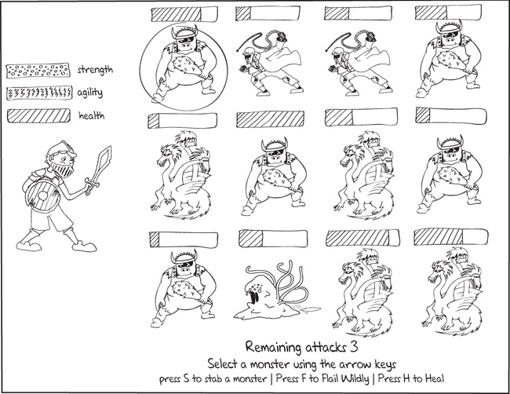

In DrRacket, you don’t need to launch a game to render a game state. You just call the rendering functions on the same game state, and you see what the player may see. She sees an image of her status on the left, the monsters arranged in a rectangular grid on the right, and the instructions below. Also note how the first monster is marked by a circle; it is the current target of the player. Remember that to change the target, the player uses the arrow keys to move around the grid of monsters.

And that brings us to the last function, the one that deals with key strokes:

```
(define (player-acts-on-monsters w k)
  (cond
    [(zero? (orc-world-attack# w)) (void)]
    [(key=? "s" k) (stab w)]
    [(key=? "h" k) (heal w)]
    [(key=? "f" k) (flail w)]
    [(key=? "e" k) (end-turn w)]
    [(key=? "n" k) (initialize-orc-world)]
    [(key=? "right" k) (move-target w +1)]
    [(key=? "left" k)  (move-target w -1)]
    [(key=? "down" k)  (move-target w (+ PER-ROW))]
    [(key=? "up" k)    (move-target w (- PER-ROW))])
  (give-monster-turn-if-attack#=0 w)
  w)
```

This function looks more like the first version of Guess My Number than anything else you have seen in this book. So far, you have seen functions that consist of a header, which lists the name of the function and the names of the arguments, and a body, which is usually just one expression that computes the result of the function. Now with `player-acts-on-monsters`, you see a function whose body consists of three expressions: a conditional, a function call to `give-monster-turn-if-attack#=0`, and the variable `w`.

When the function is called, the first expression is evaluated and its result is thrown away. The second expression is evaluated, and the result is thrown away again. Finally, the last expression is evaluated, and its value becomes the result of the whole function.

You may now think that `player-acts-on-monsters` is a really strange function. According to our explanation, it always returns `w`, the world that it is given when the player presses the “k” key. So here is the catch. With the introduction of mutators, the evaluation of an expression doesn’t just produce a value—it may also affect the evaluation of *other expressions*.

The conditional in the body of `player-acts-on-monsters` determines whether and how to change `w` in response to the player’s action on the keyboard. The function call to `give-monster-turn-if-attack#=0` checks whether the monsters can change `w`. Both expressions return nothing. In the end, `player-acts-on-monsters` evaluates the expression `w`, which has dramatically changed because of the first two expressions.

Now let’s look in detail at the three steps. The conditional first checks whether the player may still attack. If not, the conditional uses `void` to perform no action. You may want to figure out why it would have been acceptable to write `42` instead of `(void)`. If the player can still attack, the function checks which of the nine keys the player may have pressed. The first three keys trigger calls to functions that change the player or the monsters in the world. The next two are about ending the player’s turn or starting over.

The final four `cond` clauses correspond to navigation actions; each calls `move-target` to change the index in the `target` field. The responses to the “←” and “ →” keys seem obvious: they ask `move-target` to change the current target by adding `+1` or `-1` to the current target. The responses to “↓” and “↑” use the `PER-ROW` constant. Remember that the list of monsters is rendered as a grid with `PER-ROW` monsters in each row. Thus, if the player presses “↑”, the key event tells the program, “Go up one row in the display.” Similarly, if the player presses “↓”, it means, “Go down one row in the display.” Because all monsters are arranged in a linear list, and the current target monster is just an index into this list, `move-target` adds or subtracts `PER-ROW` monsters to this index and keeps the index in range.

Once the conditional is finished checking all conditions, the player may have used up all of her attacks. In that case, it is time to let the monsters loose. All live monsters will attack the player at once. When the monsters’ attack is over, it’s time to hand control back to `big-bang` by returning the modified world `w`. Doing so allows the player to take her next turn—unless of course the game is over.

## 8.7 Initializing the Orc World

Our initialization process relies on three functions. Two are simple:

```
(define (initialize-player)
  (player MAX-HEALTH MAX-AGILITY MAX-STRENGTH))

(define (random-number-of-attacks p)
  (random-quotient (player-agility p) ATTACKS#))
```

The first creates a player with maximal health, agility, and strength. The second picks a random number of attacks, like this:

```
(define (random-quotient x y)
  (define div (quotient x y))
  (if (> 0 div) 0 (random+ (add1 div))))

(define (random+ n)
  (add1 (random n)))
```

This `random-quotient` function picks a random number between 1 and `(quotient x y)` via `random+` unless the quotient is `0`. In our specific case, this means that the number of attacks is determined as a random fraction of the player’s agility. Naturally, we define `random-quotient` and `random+` as separate functions because we will use them again. If you can think of another way to determine a random number of attacks, try it. The code is all yours.

The third initialization function creates a list of monsters:

```
(define (initialize-monsters)
  (build-list
    MONSTER#
    (lambda (_)
      (define health (random+ MONSTER-HEALTH0))
      (case (random 4)
        [(0) (orc ORC-IMAGE health (random+ CLUB-STRENGTH))]
        [(1) (hydra HYDRA-IMAGE health)]
        [(2) (slime SLIME-IMAGE health (random+ SLIMINESS))]
        [(3) (brigand BRIGAND-IMAGE health)]))))
```

And voilà, you see `lambda` and `build-list` in action, and `case` is thrown in there, too. Since the goal is to create a list, the function uses `build-list`, which consumes the number of monsters we wish to start with and a function. We use `lambda` to make this function because it is used only here, it isn’t recursive, and it is straightforward. After picking a random health, a random number is used to return one of four possible monsters.

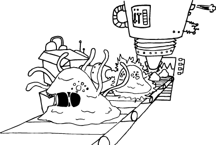

We are almost finished, except for two little things. First, `lambda` uses `_` as a parameter. In Racket, `_` is just a plain old variable name, pronounced “underscore.” Racketeers, by convention, use it to indicate that a function ignores this parameter. Remember that `build-list` applies this function to all numbers between 0 and `MONSTER#`. Since we don’t need this number for anything in our world of orcs, the `lambda` function throws it away.

Second, if you look closely at all four constructors, you’ll notice that they take one more argument than we’ve admitted: an image. Because we want to visualize the monsters at some point, we might as well stick their images into the `monster` structure once and for all:

```
(struct monster (image [health #:mutable]))
```

With the revision of this definition, all `monster` structs have two fields: `image`, which never changes, and `health`, which may change over the course of the game. Every substructure inherits these two fields. Because of inheritance, we needed to make only a single change to the program: the definition of the `monster` struct. Later on, when our program must render the monsters, it can use `monster-image` to pull out the images from the `monster`s.

## 8.8 Rendering the Orc World

The basic world setup mentions two small functions that render the instructions and the win and lose messages:

```
(define (instructions w)
  (define na (number->string (orc-world-attack# w)))
  (define ra (string-append REMAINING na))
  (define txt (text ra INSTRUCTION-TEXT-SIZE ATTACK-COLOR))
  (above txt INSTRUCTION-TEXT))

(define (message str)
  (text str MESSAGES-SIZE MESSAGE-COLOR))
```

The instructions are always the same, except for the number of remaining attacks. To show the remaining attacks, we convert the number into a string, stick it into an appropriate sentence, and convert the string to an image of the text. Otherwise, `instructions` assembles the two text images into one. The `message` function is even simpler than `instructions`. It merely turns the given string into text using an appropriate size and color.

The real workhorse of the rendering section is `render-orc-world`, a function that consumes three arguments and produces an image of the current world:

```
(define (render-orc-world w t additional-text)
  (define i-player  (render-player (orc-world-player w)))
  (define i-monster (render-monsters (orc-world-lom w) t))
  (above V-SPACER
         (beside H-SPACER
                 i-player
                 H-SPACER H-SPACER H-SPACER
                 (above i-monster
                        V-SPACER V-SPACER V-SPACER
                        additional-text)
                 H-SPACER)
         V-SPACER))
```

You should recall that `render-orc-world` is used in two different ways: during the game and after the game is over. For the former situation, it is called with the current state of the world, an index that specifies the target in the list of monsters, and instructions for the player. For the latter situation, the function is also applied to the state of the world—or `#f` if there is no live target left—and a termination message. In short, the second argument is either a number or a Boolean value, and you need to keep this in mind.

As you would expect, the function takes apart the given world struct and uses helper functions to render the two important pieces: the player and the monsters. Once it has images for these, it is simply a question of assembling them into the right layout.

You can imagine that we didn’t arrive at this format without some experimentation. Once we had defined `render-player` and `render-monsters`, here is how we started experimenting in the interactions panel:

```
> (beside (render-player (initialize-player))
          (above (render-monsters (initialize-monsters))
                 (message "You win")))
```

We didn’t like how everything was squeezed together. So we played around. We added vertical and horizontal spacers, which are just a constant rectangles with a funny *x* or *y* dimension:

```
(define V-SPACER (rectangle 0 10 "solid" "white"))
(define H-SPACER (rectangle 10 0 "solid" "white"))
```

Moving on, here is the function that creates an image for the player:

```
(define (render-player p)
  (define s (player-strength p))
  (define a (player-agility p))
  (define h (player-health p))
  (above/align
    "left"
    (status-bar s MAX-STRENGTH STRENGTH-COLOR STRENGTH)
    V-SPACER
    (status-bar a MAX-AGILITY AGILITY-COLOR AGILITY)
    V-SPACER
    (status-bar h MAX-HEALTH HEALTH-COLOR HEALTH)
    V-SPACER V-SPACER V-SPACER
    PLAYER-IMAGE))
```

By now, you know the routine for this kind of function. The argument is a `player` struct. The function takes it apart, extracting the three pieces: strength, agility, and health. Then it uses one auxiliary function to create the pieces of the final image: status bars for health, agility, and strength. Guess what `above/align` does? It jams together a bunch of images, one above the other, and the first argument—a string—tells it how to align these images.

Let’s take a look at the auxiliary function, `status-bar`:

```
(define (status-bar v-current v-max color label)
  (define w (* (/ v-current v-max) HEALTH-BAR-WIDTH))
  (define f (rectangle w HEALTH-BAR-HEIGHT 'solid color))
  (define b (rectangle HEALTH-BAR-WIDTH HEALTH-BAR-HEIGHT ...))
  (define bar (overlay/align "left" "top" f b))
  (beside bar H-SPACER (text label HEALTH-SIZE color)))
```

It consumes the current value, the maximal value, the desired color, and a string label to attach to the bar. The function first computes the width of the health bar: `(* (/ v-current v-max) HEALTH-BAR-WIDTH)`. If `v-max` should be displayed as `HEALTH-BAR-WIDTH`, then `(/ v-current v-max)` is the ratio of this number that determines how `v-current` should be displayed. Once it has this number, the function creates a filled and framed rectangle to create the bar. The final expression attaches `label` as a text image.

And that leaves us with rendering all the monsters, the trickiest function of the bunch. It consumes a list of monsters and an argument that indicates which of them is the current target, if any:

```
(define (render-monsters lom with-target)
  ;; the currently targeted monster (if needed)
  (define target
    (if (number? with-target)
        (list-ref lom with-target)
        'a-silly-symbol-that-cannot-be-eq-to-an-orc))

  (define (render-one-monster m)
    (define image
      (if (eq? m target)
          (overlay TARGET (monster-image m))
          (monster-image m)))
    (define health (monster-health m))
    (define health-bar
      (if (= health 0)
          (overlay DEAD-TEXT (status-bar 0 1 'white ""))
          (status-bar health MONSTER-HEALTH0 MONSTER-COLOR "")))
    (above health-bar image))

(arrange (map render-one-monster lom)))
```

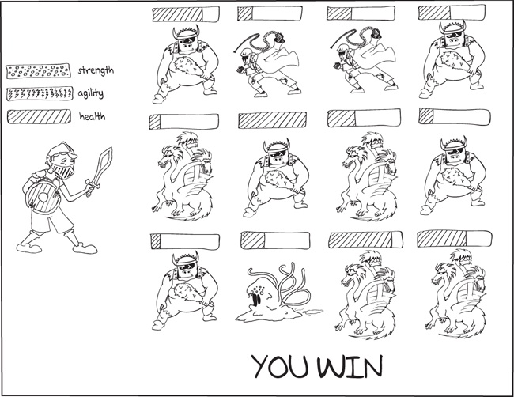

Now you need to remember the images of the monsters. Clearly, `render-monster` must turn all monsters into images. With `map`, that’s easy. All we need is `(map render-one-monster lom)` because this applies `render-one-monster` to every monster on the `lom` list and you have a list of images. If you arrange them properly, you get the full scene of all monsters, but for now, let’s postpone the discussion of `arrange` and focus on the images of the monsters.

At this point, it is time to exploit the `with-target` argument. It is either a number or `#f`. If it is a number, the function must mark the current target. If it is false, there is no current target, and the game is over. The first definition inside of `render-monsters` turns `with-target` into one of the monsters from the list, using `list-ref`, or a symbol. The `render-one-monster` uses this value to determine whether the given monster is the current target.

To get an image of one monster, `render-one-monster` extracts the image from the given monster struct and adds the target marker, if the monster is `eq?` to the target. The rest of the function creates a health bar for the monster. Two things stand out, though. First, look how we use `eq?` to compare `render-one-monster`’s argument with the `target`. We really want this specific struct on the `lom` list, not a struct with the same content—that is, `equal?` would be wrong. That’s what `eq?` is for. Second, the `health-bar` calculation looks complex because we want the graphics to look good when monsters die. Experiment with the code to see what happens when you simplify the first branch of the `if` expression that computes the `health-bar` image. Then figure out what a health bar looks like if it has a current value of `0`, a maximum value of `1`, white color, and an empty label. It is just an invisible rectangle. So this three-line calculation in `render-one-monster` just ensures that the rectangle is exactly as tall as an empty health bar.

Here is the final function needed for rendering a world, `arrange`:

```
(define (arrange lom)
  (cond
    [(empty? lom) empty-image]
    [else (define r (apply beside (take lom PER-ROW)))
          (above r (arrange (drop lom PER-ROW)))]))
```

This is a recursive function, though it only superficially looks like the kinds of list-eating functions we have seen before. After making sure that the list isn’t empty, `arrange` retrieves the first `PER-ROW` images with `take`, which is one of those general-purpose built-in list functions you just have to know:

```
> (take '(a b c d e f) 2)
'(a b)
> (drop '(a b c d e f) 2)
'(c d e f)
```

With `(apply beside ...)`, the `arrange` function creates the image of a row, and with `(above r ...)`, it layers this row above the remaining ones. To remove the first `PER-ROW` images, `arrange` uses `drop`, which, like `take`, comes with Racket. So yes, `arrange` is recursive, but it doesn’t eat the list on a one-by-one basis. Read it again.

## 8.9 The End of the World

When does the world come to an end? Well, it’s over when all the monsters are dead or one of the player’s attributes sinks to `0`:

```
(define (win? w)
  (all-dead? (orc-world-lom w)))

(define (lose? w)
  (player-dead? (orc-world-player w)))

(define (player-dead? p)
  (or (= (player-health p) 0)
      (= (player-agility p) 0)
      (= (player-strength p) 0)))

(define (all-dead? lom)
  (not (ormap monster-alive? lom)))

(define (monster-alive? m)
  (> (monster-health m) 0))
```

And that’s all it takes. The only interesting function is `all-dead?`, which uses `ormap` to determine whether any of the monsters are alive. Are you wondering why `monster-alive?` is defined separately? We could have just made it a `lambda` within the `all-dead?` function, but `monster-alive?` is also useful when it comes to executing actions.

## 8.10 Actions, A Final Look

We’ve kept the game actions for last. All actions consume the current state of the world and mutate it. The player has five actions, all triggered in response to certain keystrokes: `stab`, `heal`, `flail`, `end-turn`, and `move-target`. The monsters have one action, aptly called `give-monster-turn-if-attack#=0`, because its name tells us that it runs a monster turn if the player has no attacks left.

With that in mind, let’s tackle the implementation of actions. One function has a trivial definition:

```
(define (end-turn w)
  (set-orc-world-attack#! w 0))
```

If the player really wishes to end her turn prematurely, just set the number of remaining attacks to `0`. Then, `give-monster-turn-if-attack#=0` takes over and gives the monsters their turn.

Like `end-turn`, the definition of `heal` is obvious:

```
(define (heal w)
  (decrease-attack# w)
  (player-health+ (orc-world-player w) HEALING))
```

A player can trade one attack for one healing action. So `heal` pays for the action and then calls a function that increases the player’s health by some constant factor.

The definition of `heal` suggests a pattern for other actions, namely, to first call `decrease-attack#` to pay for the attack and then to execute some action. And yes, we see this pattern again in the definition of `stab`:

```
(define (stab w)
  (decrease-attack# w)
  (define target
     (list-ref (orc-world-lom w) (orc-world-target w)))
  (define damage
    (random-quotient (player-strength (orc-world-player w))
                     STAB-DAMAGE))
  (damage-monster target damage))
```

In addition, `stab` immediately extracts the targeted monster from the world. As for the stabbing, `stab` picks a random `damage` value based on the player’s current strength and a constant dubbed `STAB-DAMAGE`. Then it calls a function that inflicts the chosen damage on the chosen monster. That’s all. Yes, we owe you a little helper function, `damage-monster`, but as you will see later, it is really straightforward.

Our player’s most complicated form of attack is `flail`. Recall that its purpose is to attack a whole bunch of live monsters, starting from the chosen target:

```
(define (flail w)
  (decrease-attack# w)
  (define target (current-target w))
  (define alive (filter monster-alive? (orc-world-lom w)))
  (define pick#
    (min
     (random-quotient (player-strength (orc-world-player w))
                      FLAIL-DAMAGE)
     (length alive)))
  (define getem (cons target (take alive pick#)))
  (for-each (lambda (m) (damage-monster m 1)) getem))
```

Like `stab`, `flail` also pays for the attack and picks the current target. Then it filters the living monsters from the dead ones and chooses the number of monsters that can be attacked, a number that depends on the player’s strength and the global constant `FLAIL-DAMAGE`. Finally, `flail` will `cons` the current target on to the list of chosen monsters so that it can attack them all—a little bit. Notice that this may damage the currently targeted monster twice, but so it goes when you flail wildly.

We have yet to define the three helper functions that the player’s actions rely on. They aren’t complicated, and we aren’t hiding anything. The names of the functions tell you what they do, and their definitions are one-liners:

```
(define (decrease-attack# w)
  (set-orc-world-attack#! w (sub1 (orc-world-attack# w))))

(define (damage-monster m delta)
  (set-monster-health! m (interval- (monster-health m) delta)))
(define (current-target w)
  (list-ref (orc-world-lom w) (orc-world-target w)))
```

The first one, `decrease-attack#`, subtracts one from the `attack#` field in the given world `w`. The second one performs interval arithmetic on the monster’s health—the same kind we used for manipulating the player’s attributes. And the third one extracts the currently targeted monster from the list.

If you are at all confused here, take a breath. Open the code in the chapter directory. Play with some of the functions. Make up a world. Call the function on the world. Interact with the world.

Time to tackle the last function that `player-acts-on-monsters` demands:

```
(define (move-target w delta)
  (define new (+ (orc-world-target w) delta))
  (set-orc-world-target! w (modulo new MONSTER#)))
```

Not surprisingly, `move-target` adds the given `delta` to the current target index. But this addition may produce a number that is too large or too small, a number that goes beyond the end of the list or before its beginning. So before we store this new target number into the `target` field of `w`, we use the `modulo` function to find the appropriate number between `0` and the actual number of monsters.

It may have been a while since your teacher tormented you with the `modulo` function, so let’s experiment. First, we set up the world:

```
> (define p (player 3 4 5))
> (define lom (list (monster 0 2) (monster 1 3)))
> (define a-world (orc-world p lom 1 0))
```

Next, we call `move-target` on `a-world`:

[output not shown]

As you can see, `move-target` has no result, but it has an effect on `a-world`. So we check to find out what happened to it.

Now it’s your turn. Try `move-target` on some of the numbers we used here, like `+1`, `-1`, `(+ PER-ROW)`, `(- PER-ROW)`. Watch what happens in various situations.

Of course, it’s actually the monsters’ turn. We still need to create all the functionality to make our fearsome monsters attack, suffer, and retreat. The first function we need to define is `give-monster-turn-if-attack#=0`:

```
(define (give-monster-turn-if-attack#=0 w)
  (when (zero? (orc-world-attack# w))
    (define player (orc-world-player w))
    (all-monsters-attack-player player (orc-world-lom w))
    (set-orc-world-attack#! w (random-number-of-attacks player))))
```

We know the function consumes a world. Its name tells us *what* it does, and its definition shows *how* it accomplishes all this. Remember that `when` is like a `cond` expression with just one branch. This one branch may contain a series of definitions and expressions, just like a function body. In this particular case, the `when` expression checks whether the player has any attacks left for this turn. If the player has no attacks left, the function extracts the player from the given world and gives the monsters their due. Once they are finished damaging the player, `give-monster-turn-if-attack#=0` sets the number of attacks for the next player’s turn. Put differently, the all-important line in this function is the second one in the `when` expression, which calls `all-monsters-attack-player` with the player and the list of monsters.

And what do you think `all-monsters-attack-player` does? It does exactly what its name says: it allows each live monster to attack the player in its orcish, hydranous, slime-a-licious, or brigandy way:

```
(define (all-monsters-attack-player player lom)
  (define (one-monster-attacks-player m)
    (cond
      [(orc? m)
       (player-health+ player (random- (orc-club m)))]
      [(hydra? m)
       (player-health+ player (random- (monster-health m)))]
      [(slime? m)
       (player-health+ player -1)
       (player-agility+ player
                        (random- (slime-sliminess monster)))]
      [(brigand? m)
       (case (random 3)
         [(0) (player-health+ player HEALTH-DAMAGE)]
         [(1) (player-agility+ player AGILITY-DAMAGE)]
         [(2) (player-strength+ player STRENGTH-DAMAGE)])]))
  (define live-monsters (filter monster-alive? lom))
  (for-each one-monster-attacks-player live-monsters))
```

When someone explains a function and says, “Every actor executes some action,” you want to use `for-each` to code it up. It is kind of like `map`, but it doesn’t collect any results. And when someone says, “All items on this list that are good,” you use `filter` to extract the good items from this list. And that explains `all-monsters-attack-player` almost completely. The only point left to explain is what each monster actually does to the player, but as you can see, that’s also spelled out in one single, locally defined function: `one-monster-attacks-player`. It consumes a monster, determines which kind of monster it is, and from there, it’s all downhill for the player. Go read the definition of this last remaining function and explain to yourself what each monster does.

Then fight the monsters and save Chad. Good luck!

## `Throw`—Chapter Checkpoint

In this chapter, we used structures to model the world:

- Structures are good for representing objects with a fixed number of parts.
- A structure definition also defines several new functions for you. One is for making new instances of the structure, which is called a constructor. Another is for determining if a value is an instance of the structure, called a predicate. Finally, you get one function for accessing each part of a structure, called an accessor.
- Entire structures or individual fields can be declared mutable. If so, the structure definition defines mutators. The best use for a mutator is to change a structure deeply embedded in either lists or other structures.
- With mutable structures, `eq?` becomes critically important.

## Chapter Challenges

- **Easy**. Add actions that allow the player to regain strength and agility.
- **Medium**. Equip the player with an `armor` property. Then create an action called `block` that adds to the player’s armor. A player’s armor can absorb some of the damage from creatures, but each of the creature’s attacks reduces the `armor` value.
- **Medium**. Create a monster that ignores the player’s armor when it attacks.

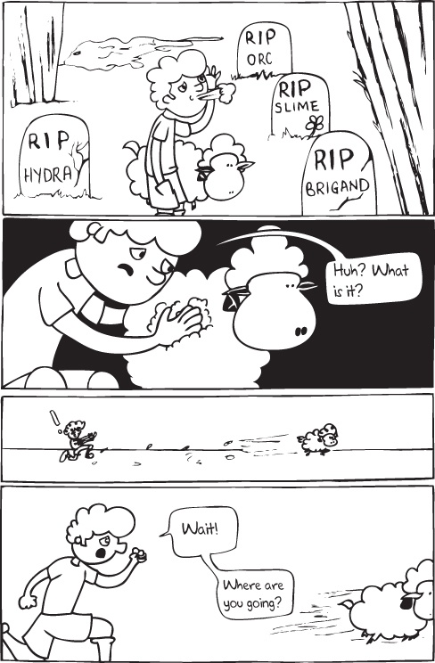

## Chapter 9. (The Values of Loops)

#|

Lists are a central data type in Racket. We started off manipulating them manually. Then we learned about lambda and functions like map and foldl. Now we will introduce a third and even more powerful way of managing lists: for loops.

|#

## 9.1 FOR Loops

If you have taken a run-of-the-mill course on programming or read one of those standard introductory books, you know about `for` loops. Racketeers have a special relationship with loops, and therefore Racket has many kinds of `for` loops. Each has its own uses and purposes. Anything you can do with `map`, `foldl`, `foldr`, `filter`, `andmap`, `ormap`, and so on, you can do with `for` loops.

The basic **`for` loop** looks and acts like the one you may already know:

```
> (for ([i '(1 2 3 4 5)])
    (display i))
12345
```

The clause immediately after the `for` keyword sets up **variable bindings** for the body of the loop. A binding consists of a variable paired with an expression that evaluates to a list. In this example, the variable is `i` and the expression is `'(1 2 3 4 5)`. Racket sets the variable to each element of the list and for each one evaluates the body of the `for` loop—in this case, `(display i)`. Here, the `for` loop iterates across the list `'(1 2 3 4 5)` and uses the `display` function to print each value.

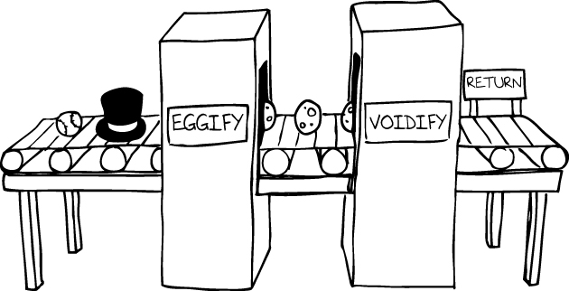

The basic `for` loop is for effect only. Like `for-each`, it returns nothing. The preceding `for` loop example is equivalent to `(for-each display '(1 2 3 4 5))`. If we want to mimic `map`, which involves building or running over a list, we use a different kind of `for` loop:

```
> (for/list ([i '(1 2 3 4 5)])
   (/ 1 i))
'(1 1/2 1/3 1/4 1/5)
```

This `for/list` loop acts like `for`, but it takes the last value of each iteration and collects these values in a list. You could think of it as follows:

```
> (map (lambda (x) (/ 1 x)) '(1 2 3 4 5))
'(1 1/2 1/3 1/4 1/5)
```

One of the most powerful loops is `for/fold`. This loop accumulates a value much like `foldr` and `foldl`:

```
> (for/fold ([sqrs 0])
            ([i '(1 2 3 4 5 6 7 8 9 10)])
    (+ (sqr i) sqrs))
385
```

The value returned in each iteration is bound to `sqrs`, which is initialized to `0`. In essence, what we wrote above is equivalent to this expression:

```
> (foldl (lambda (i sqrs) (+ (sqr i) sqrs))
         0
         '(1 2 3 4 5 6 7 8 9 10))
```

But let’s say we also wanted to keep track of the number of squares over `50`. We could do it like this:

```
> (for/fold ([sqrs 0]
             [count 0])
            ([i '(1 2 3 4 5 6 7 8 9 10)])
     (values (+ (sqr i) sqrs)
             (if (> (sqr i) 50)
                 (add1 count)
                 count))))
385
3
```

Wait! Look over this example again because it is complicated. Actually, it isn’t just complicated—it uses a feature of Racket that you have never seen before: an expression that produces *multiple* values. This is so new that it deserves its own section.

## 9.2 Multiple Values

The `values` function returns whatever you pass to it:

```
> (values 42)
42
```

It may seem silly to have a function that just returns what it is given. But the `values` function can take anything and any number of values, and it returns them all at *once*:

```
> (values 'this 'and-this 'and-that)
'this
'and-this
'and-that
```

These values can be caught with `define-values`, another way to define variables:

```
> (define-values (one two three) (values 'three 'two 'one))
> one
'three
> two
'two
> three
'one
```

Like `values`, `define-values` can work with any number of arguments. Like `define`, `define-values` gives names to values. As the example explains, `define-values` comes with a sequence of identifiers between parentheses. It expects its right-hand side to deliver that many values. When it gets the values, it gives them the specified names.

Here is an example with a more complicated right-hand side:

```
> (define-values (x y)
    (if (string=? (today) "tuesday")
        (values 10 20)
        (values 42 55)))
> x
```

We will let you figure out what the value of `x` is because we don’t know on what day of the week you are reading this book.

## 9.3 Back to FOR/FOLD

Let’s look at the `for/fold` example from 9.1 FOR Loops again:

```
> (for/fold ([sqrs 0]
             [count 0])
            ([i '(1 2 3 4 5 6 7 8 9 10)])
    (values (+ (sqr i) sqrs)
            (if (> (sqr i) 50)
                (add1 count)
                count)))
385
3
```

On closer observation, `for/fold` is a bit like both `define-values` and `values`. It sets up two sets of bindings. The first one determines how many values each loop iteration with the loop body must return and how many values the loop itself returns. As you may have guessed, the body of the `for/fold` loop may refer to these names. Here, the loop sets up two such bindings, initializing both to `0` and giving them the names `sqrs` and `count`. The loop body consists of a `values` expression that produces two values. For each iteration, the first value is the square of `i` added to `sqrs`, and the second value is `count` or `(add1 count)`, depending on how large the square of `i` is. In the end, the loop produces `385` and `3`. Do you understand why?

[figure not shown]

## 9.4 More on Loops

All `for` loops come with the ability to skip some iterations. In the part of the `for` loop where we specify the lists we are using, we can put in a `#:when` clause. Each `#:when` clause comes with an expression that is evaluated for every iteration. The iteration is performed only if the expression following `#:when` evaluates to true:

```
> (for/list ([i '(1 2 3 4 5)]
             #:when (odd? i))
    i)
'(1 3 5)
> (for/fold ([sum 0])
            ([i '(1 2 3 4 5)]
             #:when (even? i))
    (+ sum i))
6
```

In this manner, `#:when` clauses make `for` loops act like `filter`.

Why should you use Racket’s `for` loops? You should not use `for` loops just because you are familiar with their impoverished cousins from pedestrian languages. You should get to know Racket’s `for` loops because they are far more powerful than what you may have encountered. Racketeers are keenly aware of the advantages of `lambda`, `map`, `andmap`, `filter`, and friends, and therefore Racket provides many more kinds of `for` loops than you have ever seen. If you can wrap your head around them, you will write compact yet highly readable code.

One major benefit of `for` loops is that they easily run through a lot of lists at once. All you need to do is add more `for` clauses, and the `for` loop binds all of those expressions simultaneously and iterates over all of them in parallel. The loop ends as soon as the shortest list is exhausted:

```
> (for/list ([i '(1 2 3 4 5)]
             [j '(1 2 3 4)]
             [k '(5 4 3 2 1)])
    (list i j k))
'((1 1 5) (2 2 4) (3 3 3) (4 4 2))
```

Here, we bind `i`, `j`, and `k` to the elements of three separate lists. Because the shortest list—bound to `j`—has only four elements, while the others have five, the loop runs four times, ignoring the last elements of the lists bound to `i` and `k`.

Take a look at this example:

```
> (for/list ([i '(1 2 3 4 5)]
             [s '("a" "b" "c" "d" "e")]
             #:when (and (even? i) (string=? s "d")))
    i)
'(4)
```

As you can see, it evaluates the loop body, `i`, only when `i` is `4` and `s` is the string `"d"`.

Something else you can do with `for` loops is nest them. Instead of writing . . .

```
(for ([i '(1 2 3)])
  (for ([j '(1 2 3)])
    (for ([k '(1 2 3)])
      (displayln (list i j k)))))
```

. . . Racketeers would write the much more concise

```
(for* ([i '(1 2 3)]
       [j '(1 2 3)]
       [k '(1 2 3)])
  (displayln (list i j k)))
```

Every kind of `for` loop comes with this `for*` variety: `for*/list`, `for*/fold`, and so on. Note that `for*/list` is equivalent to a nested `for` loop but with all values collected into one list:

```
> (for*/list ([i '(1 2 3)]
              [j '(4 5 6)])
   (+ i j))
'(5 6 7 6 7 8 7 8 9)
> (for/list ([i '(1 2 3)])
   (for/list ([j '(4 5 6)])
     (+ i j)))
'((5 6 7) (6 7 8) (7 8 9))
```

The sublists in a `for*` are evaluated just as they would be in a nested `for` loop—every time a level runs, the corresponding list is evaluated. That allows us to compute values like this:

```
> (for*/list ([k '((1 2) (3 4) (5 6) (7 8))]
              [n k])
    n)
'(1 2 3 4 5 6 7 8)
```

Here, we flatten a list of lists—turn it into a single list of numbers—by binding each element in the superlist to `k`, binding each element of those lists to `n`, and returning those values. We can do this because every time we change elements in the list bound to `k`, the initial value for `n` is recomputed.

There is one more piece of `for` loop magic: `in-range`. We can use it to iterate across ranges of numbers or to perform an action a set number of times. The `in-range` function accepts one to three arguments and returns something a `for` loop can iterate over:

```
> (for/list ([i (in-range 10)])
    i)
'(0 1 2 3 4 5 6 7 8 9)
> (for/list ([i (in-range 5 10)])
    i)
'(5 6 7 8 9)
> (for/list ([i (in-range 0 10 2)])
    i)
'(0 2 4 6 8)
```

When given `n` as an argument, `in-range` returns a sequence containing the numbers from 0 to `n` minus 1. Given two arguments, it returns a sequence from the first argument to one less than the second. If it is given a third argument, it increments each element of the sequence by the third argument until it reaches the second argument. Try it out.

Now, `in-range` is different from all the other Racket functions we have seen before:

```
> (in-range 10)
#<stream>
```

It returns a **stream**, which is a special kind of **sequence**.

As it turns out, `for` loops can iterate across many different kinds of sequences—even strings. There is not enough room in this book to cover all of them, but if you’re interested, look up “sequences” in the Racket documentation.

The following table describes a few other loops. There are more; if you’re interested, you know where to look.

Loop

Purpose

Example

Value

`for/and`

Joins all the results with `and`.

[output not shown]

`#f`

`for/or`

Joins all the results with `or`.

[output not shown]

`1`

`for/first`

Like `for` but it returns the first result.

```
(for/first ([i '(1 2 3)])
  i)
```

`1`

`for/last`

Like `for` but it returns the last result.

```
(for/last ([i '(1 2 3)])
  i)
```

`3`

## `Waitpid`—Chapter Checkpoint

In this chapter, we saw an alternative way of writing loops:

- There are several variants of `for` loops. Each combines its results in a different way.
- The `for*` loop is convenient shorthand for writing nested loops.
- A `for` loop iterates over a sequence of values. You can make a sequence using lists, strings, `in-range`, `in-list`, vectors, and many other values.

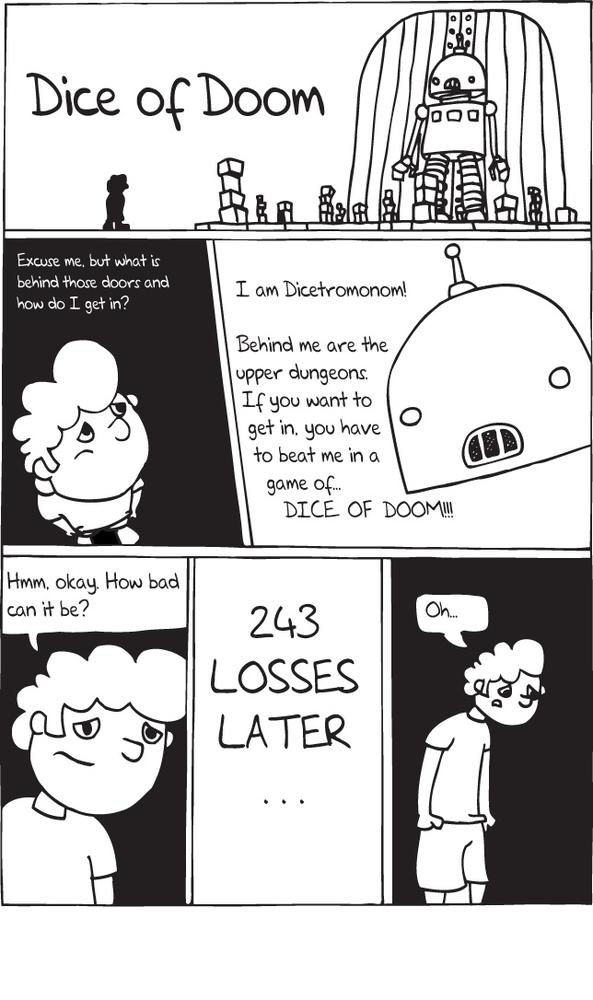

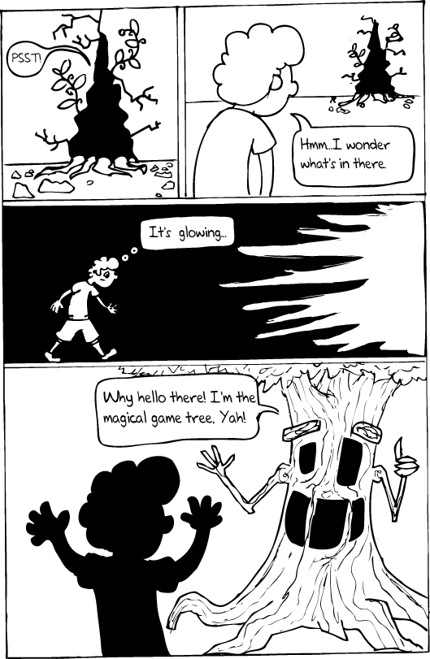

## Chapter 10. (Dice of Doom)

#|

We are finally ready to create a truly sophisticated and fun program. In this chapter, we’ll develop Dice of Doom, a game full of chance and strategy. What you’ll learn in this chapter isn’t sufficient, however, to make the implementation run fast enough for large games. Therefore, the next couple of chapters will show you how to refine this game’s implementation.

|#

## 10.1 The Game Tree

While wandering the expanses of DrRacket’s dungeons, Chad comes across a massive door guarded by a humongous machine known as Dicetromonom. When he asks the guard where the door leads, it replies, “Behind me are the upper dungeons. If you want to get in, you have to beat me in a game of . . . DICE OF DOOM!!!” Hoping to get closer to an exit, Chad challenges the guard. Game after game after game, Dicetromonom obliterates Chad. Dejected, Chad gives up and begins to wander the dungeons once more, looking for a way out. After a while, he stumbles across the mythical game tree, which grants Chad the ability to defeat Dicetromonom. Can Chad master the art of the game tree? It is your job to help him, and this chapter shows you how.

## 10.2 Dice of Doom, The Game

Dice of Doom is a turn-based strategy game played by two or more players. Each player controls territories on the board, and each territory contains a few dice. On each turn, the current player may attack an adjacent enemy territory but only if the attacker’s territory contains more than one dice.

When two neighboring territories are engaged in combat, the two players roll the dice from their respective territories. If the attacker’s sum is greater than the defender’s sum, all of the dice are removed from the targeted territory and all but one of the attacker’s dice will invade it. The attacking player now occupies that targeted territory. On the other hand, if the sum of the defender’s dice is greater than that of the attacker, all but one of the dice are removed from the territory that launched the attack. The game is over when one player controls all the territories.

During a turn, a player may attack as many times as possible or pass at any time. When a player passes, some number of dice are added to all of the current player’s territories depending on the specific rules on which the players agree. In our case, it depends on how the game is implemented.

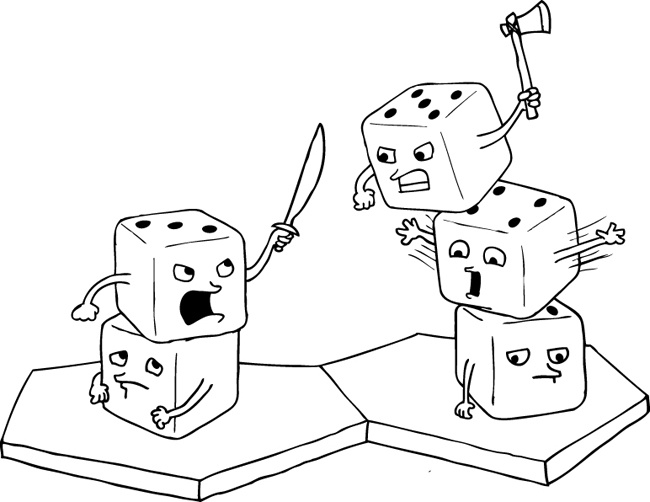

## 10.3 Designing Dice of Doom: Take One

Weeks of programming can save you hours of planning. Realistically, you cannot implement a game until you have figured out the details. In addition, you may wish to simplify the game for the first implementation and then add complexities later on. Also, you must decide how players interact with the software. Doing so often guides the rest of the design.

### Filling in the Blanks

The basic game description leaves two aspects open to interpretation: a territory’s appearance and the distribution of dice at the end of a player’s turn.

The typical game board for a Dice of Doom game consists of hexagons. As illustrated in the image to the right, each hexagon is one territory, meaning each territory can have up to six adjacent territories. Keep in mind a player may attack and take over any neighbor.

As for the supply of dice, we assume a global pool of spare dice. When a player ends her turn, one dice is moved from the pool to each of her territories. When the pool is empty, no player will receive any more reinforcements.

### Simplifying the Rules

We want to show you how to program using a game tree, which is a piece of data that contains every possible move for a game. Therefore, we are going to make three simplifications to the rules to better align the game with our purpose.

The first simplification concerns how the game ends. Some snarky player may just pass on her turn forever. To eliminate this possibility, we will make it illegal for a player to pass on the first move of her turn, thus guaranteeing that the number of dice decreases on each turn. Following this logic, the game will reach a state when no attacks can be launched because there aren’t enough dice on the territories. Alternatively, the game ends when a player has conquered all territories. The first simplification ensures that there is only a finite number of moves in every game, and therefore we can represent an entire game as one piece of data.

The second simplification is to make attacks nonrandom. In our simplified version of the game, the attacking territory must have more dice than the defending territory, and the attacking territory always wins because it is stronger.

The third simplification introduces the constraint that only two human players interact with the implementation. When the game starts up, one player takes control of the keyboard and plays a turn. To pass means to let the implementation know that the turn is done *and* to hand the keyboard to the other player. We know that this sounds a bit clumsy, but even this goal is ambitious right now. In Chapter 12, we will show you how the game itself can play the role of the second player and why our implementation makes this addition simple.

### End of Game

The revised game is over when a player cannot make any first move, other than pass. The winner is the player who owns the most territories.

### Controlling the Game

In summary:

- A player can pass only when she has made at least one attack.
- In order to attack, the attacking territory must have more dice than the defending territory.
- Two human players will play this game.
- The “←” and “ →” keys are for cycling through the tiles.
- The “Enter” key is for marking a territory.
- The “d” key is for unmarking a territory.
- The “p” key is for passing a turn.

## 10.4 How Game Trees Work

As we mentioned earlier, this implementation of the game will use a game tree, which is a chart of all possible states of the game board. These states are linked to the players’ moves because states of the board change depending on what moves have been made by the players. At every point in the game, we will maintain only the part of the tree whose root is the current state. This means we will always know our current state and a list of possible moves. When a player makes a move, that move will be used to find the next state from the list of links. Then we set that state to be the current state. By doing so, many old parts of the game tree are thrown away, thus diminishing the game tree.

The game tree gives us a central point of control for our game and its rules because every bit of information needed to play a game is saved in one data structure. In the next two chapters, we will show you how to create a more efficient representation of the game tree and how it can be used to create an artificial intelligence that can play this game. All of this is pretty abstract, so let’s look at a concrete and simple example.

Tic-tac-toe is a simple, finite game. The first level of the game tree consists of an empty board and nine possible moves for player X. The tree attached to each of the resulting game states has eight moves, representing player O’s possibilities. On the third level, we see seven branches, each representing the next level of X’s game, and so on all the way to game states in which the game has ended. The sketch shows how you should imagine a game tree for tic-tac-toe.

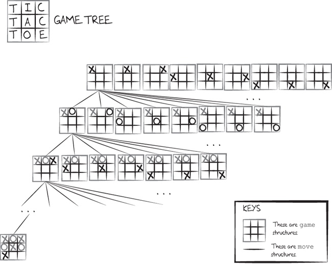

Now we use this tree to play a game of tic-tac-toe. Player X starts out with nine possible moves. She chooses to place her X in the upper-left corner. As a result, we focus only on the leftmost branch of the tree, leaving player O with eight possibilities. Say player O then marks the spot directly next to the X. This in turn means we again choose the leftmost branch. We keep pruning the tree like this until the game is over, which happens when one player wins or all fields are marked.

Generating the tic-tac-toe tree is reasonably straightforward. Suppose we have a data representation for the two players, X and O, and we represent the tree itself with `ttt` nodes:

```
(struct ttt (board moves))
```

Each such node contains the current state of the board and the list of possible moves. Each move is a two-element list that combines an action with the resulting game tree, where an action is just another structure:

```
(struct action (player position))
```

It records the player that takes the action and her chosen token placement.

The tree-generating function consumes the two players and produces a complete game tree starting from an empty board:

```
(define (generate-ttt-tree player1 player2)
  (define (generate-tree board player opponent)
    (ttt board (generate-moves board player opponent)))
  (define (generate-moves board0 player opponent)
    (define free-fields (board-find-free-fields board0))
    (for/list ((f free-fields))
        (define actnow (action player f))
        (define board1 (board-take-field board0 player f))
        (list actnow (generate-tree board1 opponent player))))
;; -- start here --
  (generate-tree the-empty-board player1 player2))
```

As you can see, the function introduces two auxiliary functions: `generate-tree` and `generate-moves`. The first one generates a tree node from the current state of the board and two players, assuming the first player takes an action. The second function generates the list of possible moves from the current board and the two players, still assuming that the first player is the active one.

From the definition, you can see that `generate-tree` is straightforward. It creates the node from the current board and generates the possible moves with the second function. In contrast, the `generate-moves` function must iterate over all free fields, which it finds with `board-find-free-fields`, a function not shown here. For each of the free fields, the loop creates an action for the current player and the free field. Then it computes with `board-take-field` the effect of the action on the current board. The result of an iteration is a two-element list that pairs the action with the resulting tree, which is determined via a recursive call to `generate-tree`. When the loop has finished, `generate-moves` returns an entire list of such two-element lists.

With the two functions in place, it is easy to see how to launch the tree-generating process. We call `generate-tree` on the empty board and pass along the two players. It takes a while to generate the entire tree, and if you wish to display it, be prepared to take a coffee break. But really, that’s all there is to game trees. The details are a bit tedious, but improving the tree operations’ efficiency is fun, and you’ll see that in the next two chapters.

## 10.5 Game States and Game Trees for Dice of Doom

Tic-tac-toe is a bit simple for using game trees, but it is a good model for our data design. For Dice of Doom, we need three pieces of data to represent a game state:

```
(struct dice-world (src board gt))
```

The first field, `src`, designates the territory that a player has marked as the source of her attack. It is an index label for one of the territories or `#f` if no territory has been marked yet. The second field, `board`, contains a list of all territories. The first element of this list is the territory that the player is focused on. Recall that this means that the player is contemplating it for a move. When she presses the “Enter” key and `src` is still `#f`, the in-focus territory becomes the marked one. The third field, `gt`, is the game tree for the current state of the board.

The definition of `dice-world` requires two more kinds of data. The first is a territory:

```
(struct territory (index player dice x y))
```

The first field, `index`, is the label that simultaneously describes the territory’s location relative to other territories and acts as a unique identifier. The second field, `player`, identifies the player who currently owns this territory. In this game, the players are represented by natural numbers. This allows us to cycle through players by adding one to the current player index instead of cycling through a list of names. The third field, `dice`, is the number of dice on this territory. We include the last two fields, `x` and `y`, as the coordinates for drawing this territory. Strictly speaking, these last two fields aren’t necessary, but they tremendously simplify the rendering process.

The second definition we need for `dice-world` is the game tree, which is a little tricky. We need two pieces of data: one representing an entire game tree and the other representing a move. Plus, we need to keep track of whose turn it is. So the game tree needs three pieces:

```
(struct game (board player moves))
```

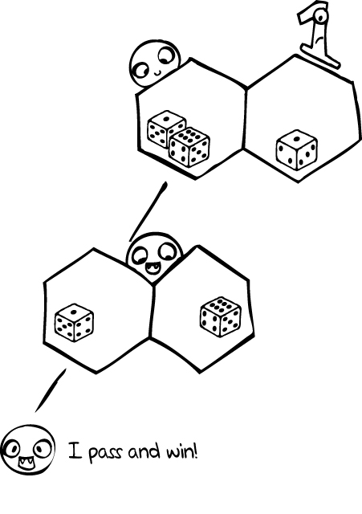

The first field, `board`, is the state of the board, which, as you may recall, is a list of territories. The second field, `player`, identifies the player whose turn it is. The third field, `moves`, is a list of all possible moves starting at this state of the game. If a player cannot make a move, this list is empty. We refer to such a game tree as the empty game tree, which indicates that the game has ended.

To represent a move, we use two pieces of data:

```
(struct move (action gt))
```

The first field, `action`, describes the attack that a player is going to perform. It is either `empty`, representing a pass, or a list of two numbers, representing an attack from the first territory against the second territory. The second field, `gt`, is the game tree that results from executing this move on the current board.

Remember that you can relate this idea to the tree image of tic-tac-toe in 10.4 How Game Trees Work. Each node in the tree represents a game, and a connection between two nodes represents a move. A `game` represents each of the nodes on that tree, whereas a `move` represents one of the between-node connections.

Let’s build a small game tree for a simplistic Dice of Doom game on a 2×1 board. To start, we’ll look at the total game tree. For a graphical view, see the diagram below.

The board consists of two territories, owned by players `0` and `1`. The game begins with player `0`’s turn. Because it is her first move and there is only one other territory on the board, her only option is to attack that territory. After this attack, there are no other territories on the board she can attack, so she must pass. Once she passes, it is player `1`’s turn. Our rules state that a player’s first move must be an attack, but that’s impossible because player `1` has no more territories. With no possible moves left, the game concludes.

According to our description of the gameplay, there are three possible states of the board:

```
(define b0 (list (territory 0 0 2 'x 'y) (territory 1 1 1 'a 'b)))
(define b1 (list (territory 0 0 1 'x 'y) (territory 1 0 1 'a 'b)))
(define b2 (list (territory 1 0 1 'a 'b) (territory 0 0 1 'x 'y)))
```

The states of the board are listed in consecutive order of gameplay. In `b0`, player `0` owns a territory with two dice and player `1` owns a territory with only one dice. In `b1` and `b2`, player `0` owns both territories that each contain one dice. Note that the only difference between `b1` and `b2` is the ordering of the territories in the list. Do you remember when the ordering plays a role?

To build any game tree manually, we must start at the bottom. In this case, it is the game tree with the final board:

```
(define gt2 (game b2 1 '()))
```

In this bottommost game tree, it is player `1`’s turn and both territories are owned by player `0`. Therefore, her list of moves is empty.

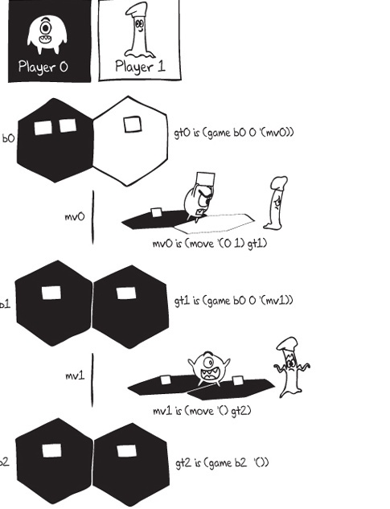

[output not shown]

Since a pass cannot be player `0`’s first move, player `0` has to make a move that leads to `gt1`:

```
(define mv0 (move '(0 1) gt1))
(define gt0 (game b0 0 (list mv0)))
```

This move represents an attack from territory `0` on `1` and contains `gt1`, which is the result of the attack. Game tree `gt0` contains the starting board, which is the ultimate game tree that we are trying to build. The diagram above graphically explains the game tree. A picture is worth a thousand words.

## 10.6 Roll the Dice

Now we can finally start making the game:

```
(define (roll-the-dice)
  (big-bang (create-world-of-dice-and-doom)
            (on-key interact-with-board)
            (on-draw draw-dice-world)
            (stop-when no-more-moves-in-world?
                       draw-end-of-dice-world)))
```

This function launches the game. It uses the same kind of `big-bang` expression you have seen throughout the book. The function first creates a random world with `create-world-of-dice-and-doom`:

```
(define (create-world-of-dice-and-doom)
  (define board (territory-build))
  (define gamet (game-tree board INIT-PLAYER INIT-SPARE-DICE))
  (define new-world (dice-world #f board gamet))
  (if (no-more-moves-in-world? new-world)
      (create-world-of-dice-and-doom)
      new-world))
```

The function creates a random board and uses it to create a world with a game tree. If the generated game has no moves for the first player, it will immediately end the game, which we don’t want, so the function tries again. Otherwise, we accept the world as it is.

The rest of the `big-bang` clauses specify how to handle events, draw the world, determine whether the game is over, and if so, draw an image for the end of the game.

The simplest of these clauses is the ending condition, which we also used in the world creation function:

```
(define (no-more-moves-in-world? w)
  (define tree (dice-world-gt w))
  (define board (dice-world-board w))
  (define player (game-player tree))
  (or (no-more-moves? tree)
      (for/and ((t board)) (= (territory-player t) player))))
```

This function checks whether a world’s list of moves is empty or the current player has conquered all territories. In either case, the game is over.

Rendering the final state of the game is also straightforward:

```
(define (draw-end-of-dice-world w)
  (define board (dice-world-board w))
  (define message (text (won board) TEXT-SIZE TEXT-COLOR))
  (define background (add-board-to-scene w (PLAIN)))
  (overlay message background))
```

At the end of the game, we generate a string using the function `won` that overlays the text on the background scene. The text either announces the winning player or acknowledges a tie.

Drawing the game in play is slightly more involved:

```
(define (draw-dice-world w)
  (add-player-info
   (game-player (dice-world-gt w))
   (add-board-to-scene w (ISCENE))))
```

The `add-player-info` function draws information about whose turn it is on a scene. Both `add-player-info` and `add-board` consume a scene on which they draw their images.

The remaining `big-bang` clause specifies the key-handler:

```
(define (interact-with-board w k)
  (cond [(key=? "left" k)
         (refocus-board w left)]
        [(key=? "right" k)
         (refocus-board w right)]
        [(key=? "p" k)
         (pass w)]
        [(key=? "\r" k)
         (mark w)]
        [(key=? "d" k)
         (unmark w)]
        [else w]))
```

The first two clauses handle the player changing focus. They call `refocus-board`, which uses the current world and the direction to rotate the board. The third clause deals with the passing action. It calls `pass` on the world, which switches the current player and prunes the game tree to the pass move. The fourth case marks a territory. It invokes `mark`, which will either change the `src` field of the world to the in-focus territory, if the source for an attack has yet to be selected, or change the `src` to `#f` and initiate the attack. Doing so prunes the game tree and switches the `board` of the world to the `board` of the new game tree. The fifth clause deals with unmarking a territory. This action switches the `src` field to `#f`. The final case says to ignore all other keystrokes.

## 10.7 Rendering the Dice World

Drawing Dice of Doom requires two functions: `draw-dice-world` and `draw-end-of-dice-world`. Both are used in the main function. In turn, the two require three auxiliary functions: `add-player-info`, `add-board`, and `won`. The first two add imagery to a given scene; the last constructs text from the current state of the game, which is then added to the background.

The `add-player-info` function is simple:

```
(define (add-player-info player s)
  (define str (whose-turn player))
  (define txt (text str TEXT-SIZE TEXT-COLOR))
  (place-image txt (- WIDTH INFO-X-OFFSET) INFO-Y-OFFSET s))
```

First, it decides whose turn it is, using an uninteresting auxiliary function, and records this information as a string. Second, it converts this string to a text image, which is finally added to the bottom of the background scene.

The second function, `add-board`, is much more complicated than `add-player-info`:

```
(define (add-board-to-scene w s)
  (define board   (dice-world-board w))
  (define player  (game-player (dice-world-gt w)))
  (define focus?  (dice-world-src w))
  (define trtry1  (first board))
  (define p-focus (territory-player trtry1))
  (define t-image (draw-territory trtry1))
  (define image (draw-focus focus? p-focus player t-image))
  (define base-s  (add-territory trtry1 image s))
  (for/fold ([s base-s]) ([t (rest board)])
    (add-territory t (draw-territory t) s)))

(define (draw-focus marked? p-in-focus p t-image)
  (if (or (and (not marked?) (= p-in-focus p))
          (and marked? (not (= p-in-focus p))))
      (overlay FOCUS t-image)
      t-image))
```

It consumes a world and a scene. From this data, it constructs an image that contains the board and informs the player whose turn it is. The first five internal definitions extract the relevant pieces from the given data. The local definition of `image` highlights the in-focus tile under certain conditions, using a simple auxiliary function. Specifically, the function overlays the basic image with the `FOCUS` frame if the currently acting player has used the arrow keys to focus on either a launching pad for an attack or a target. This special first territory on the board is then used to create the base image. The rest of the result is created by folding over the board with `draw-territory`.

The function `draw-territory` consumes a territory and returns the image for that hexagon with all of its dice:

```
(define (add-territory t image scene)
  (place-image image (territory-x t) (territory-y t) scene))

(define (draw-territory t)
  (define color (color-chooser (territory-player t)))
  (overlay (hexagon color) (draw-dice (territory-dice t))))
```

The image of the territory is created by overlaying a semi-opaque hexagon of the player’s color onto an image of the dice that occupy this territory. That way, the dice will have the same color as their territory.

The choice of color deserves some attention:

```
(define (color-chooser n)
  (list-ref COLORS n))
```

The all-caps variable name `COLORS` tells you that our code contains a constant definition, and this definition introduces `COLORS` as a list of colors. The `color-chooser` takes the `n`th value in it and calls it the `n`th player’s color.

Our list of `COLORS` differs from the way we have made colors before. In order to change the opacity of a color, we cannot use strings such as `"red"` because that’s 100% opaque. Instead, we use `make-color`, which takes four numbers between `0` and `255` to create a color. Respectively, these numbers represent the red, green, blue, and transparency values of a color. This means that the first three arguments define what shade the color will have: `0`, `0`, and `0` would give you black; `255`, `0`, `0` would give you red; `255`, `255`, `255`, would give you white; and so on. The transparency specifies how opaque the color is, where `0` is transparent and `255` is completely opaque.

Drawing the dice requires the number of dice to draw:

```
(define (draw-dice n)
  (define first-dice  (get-dice-image 0))
  (define height-dice (image-height first-dice))
  (for/fold ([s first-dice]) ([i (- n 1)])
    (define dice-image (get-dice-image (+ i 1)))
    (define y-offset  (* height-dice (+ .5 (* i .25))))
    (overlay/offset s 0 y-offset dice-image)))
```

Since each territory must be occupied by at least one dice, `draw-dice` creates one image of a dice and uses it to place all others atop.

The `draw-dice` function then folds across the remaining dice, adding dice to the base dice. For this, we must stack the dice using an increasingly larger offset in the vertical direction, as the size of the accumulated image is increased.

We can get the dice image the same way we got the color for a hexagon—by using and looking up some image in a list of images:

```
(define (get-dice-img i)
  (list-ref IMG-LIST (modulo i (length IMG-LIST))))
```

When you design image-creating functions, it is always good to experiment in the interactions panel:

```
> (define (draw-dice dice)
    (define first-dice  (get-dice-image 0))
    (define height-dice (image-height first-dice))
    (for/fold ([s first-dice]) ([i (- n 1)])
      (define dice-image (get-dice-image (+ i 1)))
      (define y-offset  (* height-dice (+ .5 (* i .25))))
      (overlay/offset s 0 y-offset dice-image)))
> (draw-dice 3)
```

## 10.8 Input Handling

Our player uses the keyboard to interact with the Dice of Doom game. As you may recall, she can perform four kinds of actions: switching focus from one territory to another, passing her turn, marking a territory, and unmarking a territory. Hence, handling keyboard inputs requires four functions: `refocus-board`, `pass`, `mark`, and `unmark`.

The `refocus-board` function takes in the world and a function that rotates a list either `left` or `right`. Its purpose is to rotate the board so that the newly focused territory is on the head of the list that represents the board.

```
(define (refocus-board w direction)
  (define source (dice-world-src w))
  (define board  (dice-world-board w))
  (define tree   (dice-world-gt w))
  (define player (game-player tree))
  (define (owner? tid)
    (if source (not (= tid player)) (= tid player)))
  (define new-board (rotate-until owner? board direction))
  (dice-world source new-board tree))
```

To accomplish its purpose, the function rebuilds the world, rotating the `board` field to the left or right. It uses two auxiliary functions: the locally defined `owner?` and `rotate-until`. Depending on the value of the `src` field, the rotation must look for either a territory of the active player or a territory of one of her opponents. The `owner?` function implements this comparison process, using a reference to the `player` from the current game tree.

The `rotate-until` function works as follows:

```
(define (rotate-until owned-by board rotate)
  (define next-list (rotate board))
  (if (owned-by (territory-player (first next-list)))
      next-list
      (rotate-until owned-by next-list rotate)))
```

It consumes a function, a board, and another function. With the `owned-by` function, `rotate-until` checks whether the first territory in `board` is owned by the desired player. With the `rotate` function, `rotate-until` executes the actual rotation on a step-by-step basis. Here, rotation can mean only one of two things: rotate left or rotate right.

We rotate the list to the left by `append`ing the `first` of it to the end:

```
(define (left l)
  (append (rest l) (list (first l))))
```

Rotating to the right uses a silly trick:

```
(define (right l)
  (reverse (left (reverse l))))
```

It reverses the given list, shifts left, and reverses again. We leave it to you to explore these two functions in the interactions panel and to confirm that they work properly for any non-empty list. As you play the game, you will notice that the game is perfectly responsive, even though this trick looks slow.

The key-handler also processes pass moves. This is done with `pass`, which consumes a `dice-world` and uses the game tree to create a new `dice-world`.

```
(define (pass w)
  (define m (find-move (game-moves (dice-world-gt w)) '()))
  (cond [(not m) w]
        [else (dice-world #f (game-board m) m)]))
```

Using `find-move`, `pass` tries to find the desired passing move in the list of moves of the game tree. If it is found, the matching game tree is returned; otherwise, `find-move` produces `#f`, possibly because passing is disallowed during the first move of a player’s turn. If there is a move, the `src` field is changed to false, and the rest of the new game state is drawn from the game tree that results from choosing the passing move.

Finding the move is easy. All we need is the list of moves and the list that represents the action to be taken:

```
(define (find-move moves action)
  (define m
    (findf (lambda (m) (equal? (move-action m) action)) moves))
  (and m (move gt m))
```

The function uses `findf` to drive the process. So if `findf` finds a move, the `and` expression extracts the corresponding game tree. Otherwise, the function returns `#f`.

The `findf` function is another one of those nice higher-order, list-eating functions. This one produces the first element of the list for which the given predicate returns true, or it returns false if nothing is found.

The last actions needed are functions that mark and unmark territories. The function `mark` consumes the world and either marks the in-focus territory or initiates an attack against the selected territory from the `src` territory:

```
(define (mark w)
  (define tree   (dice-world-gt w))
  (define board  (dice-world-board w))
  (define source (dice-world-src w))
  (define focus  (territory-index (first board)))
  (if source
      (attacking w source focus)
      (dice-world focus board tree)))
```

First, `mark` deconstructs the given world into its pieces. Second, if the `src` field of this world is `#f`, the selected territory is marked. Otherwise, `mark` attacks by delegating to a helper:

```
(define (attacking w source target)
  (define feasible (game-moves (dice-world-gt w)))
  (define attack   (list source target))
  (define next     (find-move feasible attack))
  (if next (dice-world #f (game-board next) next) w))
```

The final function in the key-handler deals with unmark requests:

```
(define (unmark w)
  (dice-world #f (dice-world-board w) (dice-world-gt w)))
```

The purpose of `unmark` is to change `src` to `#f` so that no territory is the source of an attack.

## 10.9 Creating a Game Tree

Now that we know how to manipulate the world, let’s build the world. The major element of our world is the game tree, and building the game tree relies heavily on the board representation. We therefore start with the function that creates boards:

```
(define (territory-build)
  (for/list ([n (in-range GRID)])
    (territory n (modulo n PLAYER#) (dice) (get-x n) (get-y n))))
```

The `territory-build` function uses `for/list` to create the territories. For each territory index, the `for` loop creates one territory. The structure is assigned to some player, equipped with a random number of dice, and allocated to a particular point on the GUI grid.

Here are the three auxiliary functions:

```
(define (dice)
  (add1 (random DICE#)))

(define (get-x n)
  (+ OFFSET0
     (if (odd? (get-row n)) 0 (/ X-OFFSET 2))
     (* X-OFFSET (modulo n BOARD))))

(define (get-y n)
  (+ OFFSET0 (* Y-OFFSET (get-row n))))
```

The functions `get-x` and `get-y` probably look a little weird to you, but that’s just because drawing hexagons is weird in the first place. Both of these functions use `get-row` to determine in which row the territory with index `n` is located.

```
(define (get-row pos)
  (quotient pos BOARD))
```

### The Game Tree

With `territory-build` under your belt, we can explain how to generate a game tree from a given board. Recall that a game tree contains every possible state and move. Its root starts with the given board and explores all possible moves for the current player. When she passes, the tree starts with the board for the next player and explores all possible moves from here. This process continues until it reaches boards that represent a win, loss, or tie.

Generating all possible moves, even in a game as simple as Dice of Doom, is a somewhat tricky task. It’s one of those situations where functional programming excels. Indeed, it is flat-out superior to traditional assignment-based programming, but it is still the most complex code you will find in this book.

What’s tricky is that we need to generate all feasible attacks, followed by one passing move for each turn; everything else is illegal. With functional programming, we can compute all these possibilities because generating one branch of the game tree does not affect any other branch. The following code accomplishes this feat, so bear with us as we explain its complexities.

Since Dice of Doom comes with two kinds of moves, `game-tree` relies on two locally defined functions: `attacks` and `passes`. The first generates a list of trees, each starting with an attack. The second generates a tree that starts with a pass. In both cases, the subsequent moves in the tree are generated by recursively calling `game-tree`, but in the case of `passes`, the players’ roles are switched. Now that you know this much, read the code:

```
(define (game-tree board player dice)
  ;; create tree of attacks from this position; add passing move
  (define (attacks board)
    (for*/list ([src board]
                [dst (neighbors (territory-index src))]
                #:when (attackable? board player src dst))
      (define from (territory-index src))
      (define dice (territory-dice src))
      (define newb (execute board player from dst dice))
      (define more (cons (passes newb) (attacks newb)))
      (move (list from dst) (game newb player more))))
  ;; create a passing move and the rest of the game tree
  (define (passes board)
    (define-values (new-dice newb) (distribute board player dice))
    (move '() (game-tree newb (switch player) new-dice)))
  ;; -- START: --
  (game board player (attacks board)))
```

Look at the line below the comment that says `START`. Given the current `board`, `player`, and number of dice left in the pool, `game-tree` begins by building a game structure including the list of all possible moves generated by `attacks`. Thus, this line implements the restriction that the first move of each turn must be an attack, because we know that `attacks` does not generate an initial passing move.

The `attacks` function is the workhorse of `game-tree`. Using `for*/list`, it traverses the territories of the board. For each `src` territory, it looks at each neighbor, `dst`, as a potential target. If an attack from `src` to `dst` is feasible, `attacks` builds a move structure. To do so, `attacks` uses the `execute` function to create the board resulting from a single attack. Having attacked, it’s now possible to pass, so we `cons` a passing move onto the list of attacks for that branch of the game tree.

The `passes` function is simpler than `attacks`. It calls `distribute` and gets back the reduced number of dice in the pool and the updated board. Using those, it creates the passing move by applying `game-tree` to the new board, the other player, and the remaining number of dice.

To make `passes` work in the way we just explained, we need to design the functions `switch` and `distribute`. The shorter of these is `switch`, which changes to the next player:

```
(define (switch player)
  (modulo (add1 player) PLAYER#))
```

Because we represent players as numbers, we can use the `modulo` function to switch players.

The `distribute` function is more complex than `switch`. It consumes three values: the current board, the player whose territories get additional dice, and the number of spare dice left in the pool:

```
(define (distribute board player spare-dice)
  (for/fold ([dice spare-dice] [new-board '()]) ([t board])
    (if (and (= (territory-player t) player)
             (< (territory-dice t) DICE#)
             (not (zero? dice)))
        (values (- dice 1) (cons (add-dice-to t) new-board))
        (values dice (cons t new-board)))))
```

This function folds across the current board, modifying the `player`’s instances of `territory` and the dice pool. Specifically, the loop checks whether each territory is owned by the `player`, whether it has fewer than the maximum number of dice, and whether there are spare dice left to distribute. If these three conditions are met, it subtracts one dice from the pool of spare dice and adds it to the current `territory` using this function:

```
(define (add-dice-to t)
  (territory-set-dice t (add1 (territory-dice t))))
```

As you can see, this function adds `1` to the number of dice on the territory. Even though we don’t define `territory-set-dice` here, you can imagine that it creates a new `territory` from the old values, except for the `dice` field, which receives the given value.

Why does `territory-set-dice` create a new territory? In other contexts, we have used mutation to change one field of a structure if all others stay the same. The program can’t mutate `territory` here because doing so would modify this structure throughout the entire game tree—something we definitely do not want. All that needs to be changed is this particular `territory` in the current tree node.